# ANOVA test for pontuacao

Geiser C. Challco geiser@alumni.usp.br

- ANOVA: pontuacao ~ time
  - Data Preparation
  - Summary Statistics
  - ANOVA Computation
  - PairWise Computation
- ANOVA: pontuacao ~ time*gender + Error(id/time)
  - Data Preparation
    - Check assumptions: Identifying Outliers
    - Check assumptions: Normality Test
    - Summary Statistics
  - ANOVA Computation
  - ANOVA Computation after removing non.normal data
  - PairWise Computation
  - PairWise Computation after removing non.normal data
- ANOVA: pontuacao ~ time*localizacao + Error(id/time)
  - Data Preparation
    - Check assumptions: Identifying Outliers
    - Check assumptions: Normality Test
    - Summary Statistics
  - ANOVA Computation
  - ANOVA Computation after removing non.normal data
  - PairWise Computation
  - PairWise Computation after removing non.normal data
- ANOVA: pontuacao ~ time*regiao + Error(id/time)
  - Data Preparation
    - Check assumptions: Identifying Outliers
    - Check assumptions: Normality Test
    - Summary Statistics
  - ANOVA Computation
  - ANOVA Computation after removing non.normal data
  - PairWise Computation
  - PairWise Computation after removing non.normal data
- ANOVA: pontuacao ~ time*porte + Error(id/time)
  - Data Preparation
    - Check assumptions: Identifying Outliers
    - Check assumptions: Normality Test
    - Summary Statistics
  - ANOVA Computation
  - ANOVA Computation after removing non.normal data
  - PairWise Computation
  - PairWise Computation after removing non.normal data

```r
dat <- read_excel("../data/data.xlsx", sheet = "alunos_ef14")

escolas <- read_excel("../data/data.xlsx", sheet = "escolas")
edat <- merge(dat, escolas, by = "cod_escola", all.x = T)
```

# ANOVA: pontuacao ~ time

## Data Preparation

```r
data <- edat[,c("aluno_id","ciclo","pontuacao")]
data <- data[data$ciclo %in% c("Primeiro Ciclo","Segundo Ciclo","Terceiro Ciclo"),]
data$ciclo <- factor(data$ciclo, c("Primeiro Ciclo","Segundo Ciclo","Terceiro Ciclo"))
data <- unique(data)

wdat <- spread(data, ciclo, pontuacao)
wdat <- wdat[complete.cases(wdat),]
colnames(wdat) <- c("id","c1","c2","c3")

ldat <- gather(wdat, key = time, value = pontuacao, c1,c2,c3) %>%
  convert_as_factor(id, time)
ldat <- rshinystatistics::remove_group_data(ldat, "pontuacao", "time", n.limit = 30)
```

## Summary Statistics

```r
(sdat <- ldat %>% group_by(time) %>%
   get_summary_stats(pontuacao, type = "mean_sd"))
```

```
## # A tibble: 3 × 5
##   time  variable      n  mean    sd
##   <fct> <fct>     <dbl> <dbl> <dbl>
## 1 c1    pontuacao  2773  2.16 0.58
## 2 c2    pontuacao  2773  2.25 0.748
## 3 c3    pontuacao  2773  2.43 0.962
```

| time | variable | n | mean | sd |
| --- | --- | --- | --- | --- |
| c1 | pontuacao | 2773 | 2.160 | 0.580 |
| c2 | pontuacao | 2773 | 2.252 | 0.748 |
| c3 | pontuacao | 2773 | 2.428 | 0.962 |

## ANOVA Computation

```r
(res.aov <- anova_test(ldat, dv = pontuacao, wid = id, within = time))
```

```
## ANOVA Table (type III tests)
##
## $ANOVA
##   Effect DFn  DFd      F                                           p p<.05  ges
## 1   time   2 5544 89.894 0.00000000000000000000000000000000000000379     * 0.02
##
## $`Mauchly's Test for Sphericity`
##   Effect     W                                          p p<.05
## 1   time 0.939 0.0000000000000000000000000000000000000232     *
##
## $`Sphericity Corrections`
##   Effect   GGe        DF[GG]                                     p[GG] p[GG]<.05   HFe        DF[HF]
## 1   time 0.943 1.89, 5227.08 0.000000000000000000000000000000000000447         * 0.943 1.89, 5230.52
##                                       p[HF] p[HF]<.05
## 1 0.000000000000000000000000000000000000424         *
```

| Effect | DFn | DFd | F | p | p<.05 | ges |
| --- | --- | --- | --- | --- | --- | --- |
| time | 2 | 5544 | 89.894 | 0 | * | 0.02 |

| Effect | W | p | p<.05 |
| --- | --- | --- | --- |
| time | 0.939 | 0 | * |

| Effect | GGe | DF[GG] | p[GG] | p[GG]<.05 | HFe | DF[HF] | p[HF] | p[HF]<.05 |
| --- | --- | --- | --- | --- | --- | --- | --- | --- |
| time | 0.943 | 1.89, 5227.08 | 0 | * | 0.943 | 1.89, 5230.52 | 0 | * |

## PairWise Computation

```r
(pwc <- ldat %>% emmeans_test(pontuacao ~ time, detailed = T, p.adjust.method = "bonferroni"))
```

```
## # A tibble: 3 × 14
##   term  .y.       group1 group2 null.value estimate     se    df conf.low conf.high statistic        p    p.adj p.adj.signif
## * <chr> <chr>     <chr>  <chr>       <dbl>    <dbl>  <dbl> <dbl>    <dbl>     <dbl>     <dbl>    <dbl>    <dbl> <chr>
## 1 time  pontuacao c1     c2              0  -0.0912 0.0209  8316   -0.132   -0.0502     -4.36 1.32e- 5 3.97e- 5 ****
## 2 time  pontuacao c1     c3              0  -0.267  0.0209  8316   -0.308   -0.226     -12.8  4.79e-37 1.44e-36 ****
## 3 time  pontuacao c2     c3              0  -0.176  0.0209  8316   -0.217   -0.135      -8.42 4.39e-17 1.32e-16 ****
```

| term | .y. | group1 | group2 | null.value | estimate | se | df | conf.low | conf.high | statistic | p | p.adj | p.adj.signif |
| --- | --- | --- | --- | --- | --- | --- | --- | --- | --- | --- | --- | --- | --- |
| time | pontuacao | c1 | c2 | 0 | -0.091 | 0.021 | 8316 | -0.132 | -0.050 | -4.359 | 0 | 0 | **** |
| time | pontuacao | c1 | c3 | 0 | -0.267 | 0.021 | 8316 | -0.308 | -0.226 | -12.779 | 0 | 0 | **** |
| time | pontuacao | c2 | c3 | 0 | -0.176 | 0.021 | 8316 | -0.217 | -0.135 | -8.420 | 0 | 0 | **** |

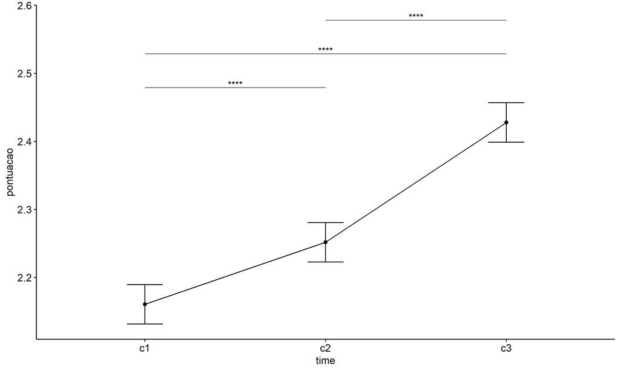

```r
pwc <- add_xy_position(pwc, x = "time", fun = "mean_se")
ggline(get_emmeans(pwc), x = "time", y = "emmean", ylab = "pontuacao") +
  geom_errorbar(aes(ymin = conf.low, ymax = conf.high), width = 0.2) +
  stat_pvalue_manual(pwc, hide.ns = T, tip.length = F)
```

# ANOVA: pontuacao ~ time*gender + Error(id/time)

## Data Preparation

```r
data <- edat[,c("aluno_id","gender","ciclo","pontuacao")]
data <- data[data$ciclo %in% c("Primeiro Ciclo","Segundo Ciclo","Terceiro Ciclo"),]
data$ciclo <- factor(data$ciclo, c("Primeiro Ciclo","Segundo Ciclo","Terceiro Ciclo"))
data <- unique(data)

wdat <- spread(data, ciclo, pontuacao)
wdat <- wdat[complete.cases(wdat),]
colnames(wdat) <- c("id","gender","c1","c2","c3")

ldat <- gather(wdat, key = time, value = pontuacao, c1,c2,c3) %>%
  convert_as_factor(id, time)
ldat <- remove_group_data(ldat, "pontuacao", c("time", "gender"), n.limit = 30)
ldat$gender <- factor(ldat$gender, sort(unique(ldat$gender)))
```

### Check assumptions: Identifying Outliers

```r
outliers <- identify_outliers(group_by(ldat, time, gender), pontuacao)
(outliers <- outliers[outliers$is.extreme == T,])
```

```
## # A tibble: 988 × 6
##    gender time  id                   pontuacao is.outlier is.extreme
##    <fct>  <fct> <fct>                    <dbl> <lgl>      <lgl>
##  1 Female c1    0wDHSyctDDkjP6OPE3c8       5   TRUE       TRUE
##  2 Female c1    1DlydHhFt2IkhBETPR4s       3.5 TRUE       TRUE
##  3 Female c1    2dPipf6cnqDHy9qCzjpa       4.5 TRUE       TRUE
##  4 Female c1    2l9eL5QVtUNWf7HSZPbv       3.5 TRUE       TRUE
##  5 Female c1    3roHN14ps3mqIKTOGrvj       3   TRUE       TRUE
##  6 Female c1    46nUNvt4sDOPsC9jnkiG       4.5 TRUE       TRUE
##  7 Female c1    4UY0Zge7bWrXHTAaYi3U       4   TRUE       TRUE
##  8 Female c1    55GlwifTTyiOSKTB9vc9       5   TRUE       TRUE
##  9 Female c1    5AeP0IQ84CerIQVenp2G       3   TRUE       TRUE
## 10 Female c1    5feCOxk9AidRBPnsBHCE       5   TRUE       TRUE
## # ℹ 978 more rows
```

| gender | time | id | pontuacao | is.outlier | is.extreme |
| --- | --- | --- | --- | --- | --- |
| Female | c1 | 0wDHSyctDDkjP6OPE3c8 | 5.000 | TRUE | TRUE |
| Female | c1 | 1DlydHhFt2IkhBETPR4s | 3.500 | TRUE | TRUE |
| Female | c1 | 2dPipf6cnqDHy9qCzjpa | 4.500 | TRUE | TRUE |
| Female | c1 | 2l9eL5QVtUNWf7HSZPbv | 3.500 | TRUE | TRUE |
| Female | c1 | 3roHN14ps3mqIKTOGrvj | 3.000 | TRUE | TRUE |
| Female | c1 | 46nUNvt4sDOPsC9jnkiG | 4.500 | TRUE | TRUE |
| Female | c1 | 4UY0Zge7bWrXHTAaYi3U | 4.000 | TRUE | TRUE |
| Female | c1 | 55GlwifTTyiOSKTB9vc9 | 5.000 | TRUE | TRUE |
| Female | c1 | 5AeP0IQ84CerIQVenp2G | 3.000 | TRUE | TRUE |
| Female | c1 | 5feCOxk9AidRBPnsBHCE | 5.000 | TRUE | TRUE |
| Female | c1 | 6IoOZmGw52LYlznSYXzK | 3.000 | TRUE | TRUE |
| Female | c1 | 6N2ACmyrqNBgfOvicubH | 3.500 | TRUE | TRUE |
| Female | c1 | 6Xlhq905iNT5kvJFoSW5 | 5.000 | TRUE | TRUE |
| Female | c1 | 7AaMrLZQiyhSoBaer5VH | 3.500 | TRUE | TRUE |
| Female | c1 | 7n7TdyIH0Wy2Z2on0Ud0 | 3.500 | TRUE | TRUE |
| Female | c1 | 9mRn1JOOCatsDmbYOqzt | 3.500 | TRUE | TRUE |
| Female | c1 | A8Rx15QryUqDDm8ooiZr | 3.000 | TRUE | TRUE |
| Female | c1 | bHXfcIqlNewfok2pEeOS | 3.000 | TRUE | TRUE |
| Female | c1 | BVzdfGW6eV1mum8ys73f | 4.000 | TRUE | TRUE |
| Female | c1 | CiV1upa4BM58OvTZsu01 | 5.000 | TRUE | TRUE |
| Female | c1 | CS7y5BCxFuWSVdvF9C6M | 3.000 | TRUE | TRUE |
| Female | c1 | CThb9hYfLyhY7ywFw2mh | 3.000 | TRUE | TRUE |
| Female | c1 | cy0oZFPyT8aGHBq7CR9A | 3.500 | TRUE | TRUE |
| Female | c1 | CzO1FzJvMlj6CVXnAlpY | 3.500 | TRUE | TRUE |
| Female | c1 | D3xqy0zcDXd1HoRlfrXr | 5.000 | TRUE | TRUE |
| Female | c1 | dgvqWTQka7lptc3Ft09o | 3.000 | TRUE | TRUE |
| Female | c1 | DoMZSYO7aDBRKg8orI37 | 5.000 | TRUE | TRUE |
| Female | c1 | dSM9U89FZYdICjBucW8v | 3.000 | TRUE | TRUE |
| Female | c1 | EnpxBGI0eFl7hhdpiN9b | 3.500 | TRUE | TRUE |
| Female | c1 | F1YXi4gyL0gXObB3MN8t | 3.500 | TRUE | TRUE |

[output cut: 958 more lines]

### Check assumptions: Normality Test

```r
(normality.df <- normality.test.per.groups(ldat, "pontuacao", c("time", "gender")))
```

```
##         var  variable time gender    n skewness  kurtosis symmetry statistic     method p p.signif normality
## 1 pontuacao pontuacao   c1 Female 1363 3.863873 14.466811       NO 1091.3292 D'Agostino 0     ****         -
## 2 pontuacao pontuacao   c1   Male 1240 3.611507 12.356043       NO  933.4536 D'Agostino 0     ****         -
## 3 pontuacao pontuacao   c2 Female 1363 2.885631  6.957836       NO  802.5152 D'Agostino 0     ****         -
## 4 pontuacao pontuacao   c2   Male 1240 3.048396  8.011967       NO  779.4828 D'Agostino 0     ****         -
## 5 pontuacao pontuacao   c3 Female 1363 1.955615  2.179243       NO  472.2414 D'Agostino 0     ****         -
## 6 pontuacao pontuacao   c3   Male 1240 2.000985  2.338453       NO  445.5795 D'Agostino 0     ****         -
```

| var | variable | time | gender | n | skewness | kurtosis | symmetry | statistic | method | p | p.signif | normality |
| --- | --- | --- | --- | --- | --- | --- | --- | --- | --- | --- | --- | --- |
| pontuacao | pontuacao | c1 | Female | 1363 | 3.864 | 14.467 | NO | 1091.329 | D’Agostino | 0 | **** | - |
| pontuacao | pontuacao | c1 | Male | 1240 | 3.612 | 12.356 | NO | 933.454 | D’Agostino | 0 | **** | - |
| pontuacao | pontuacao | c2 | Female | 1363 | 2.886 | 6.958 | NO | 802.515 | D’Agostino | 0 | **** | - |
| pontuacao | pontuacao | c2 | Male | 1240 | 3.048 | 8.012 | NO | 779.483 | D’Agostino | 0 | **** | - |
| pontuacao | pontuacao | c3 | Female | 1363 | 1.956 | 2.179 | NO | 472.241 | D’Agostino | 0 | **** | - |
| pontuacao | pontuacao | c3 | Male | 1240 | 2.001 | 2.338 | NO | 445.580 | D’Agostino | 0 | **** | - |

```r
(non.ids <- unique(do.call(
  c, lapply(which(normality.df$normality == 'NO'), FUN = function(i) {
  idx = which(ldat$time == normality.df$time[i] &
                ldat$gender == normality.df$gender[i])
  getNonNormal(ldat$"pontuacao"[idx], ldat$id[idx])
}))))
```

```r
if (length(non.ids) > 0)
  ldat2 <- ldat[!ldat$id %in% non.ids,]
```

### Summary Statistics

```r
(sdat <- ldat %>% group_by(time, gender) %>%
   get_summary_stats(pontuacao, type = "mean_sd"))
```

```
## # A tibble: 6 × 6
##   gender time  variable      n  mean    sd
##   <fct>  <fct> <fct>     <dbl> <dbl> <dbl>
## 1 Female c1    pontuacao  1363  2.16 0.571
## 2 Male   c1    pontuacao  1240  2.18 0.612
## 3 Female c2    pontuacao  1363  2.26 0.759
## 4 Male   c2    pontuacao  1240  2.24 0.731
## 5 Female c3    pontuacao  1363  2.44 0.965
## 6 Male   c3    pontuacao  1240  2.42 0.963
```

| gender | time | variable | n | mean | sd |
| --- | --- | --- | --- | --- | --- |
| Female | c1 | pontuacao | 1363 | 2.156 | 0.571 |
| Male | c1 | pontuacao | 1240 | 2.177 | 0.612 |
| Female | c2 | pontuacao | 1363 | 2.257 | 0.759 |
| Male | c2 | pontuacao | 1240 | 2.240 | 0.731 |
| Female | c3 | pontuacao | 1363 | 2.435 | 0.965 |
| Male | c3 | pontuacao | 1240 | 2.425 | 0.963 |

```r
if (length(non.ids) > 0)
  (sdat <- ldat2 %>% group_by(time, gender) %>%
      get_summary_stats(pontuacao, type = "mean_sd"))
```

| gender | time | variable | n | mean | sd |
| --- | --- | --- | --- | --- | --- |
| Female | c1 | pontuacao | 1363 | 2.156 | 0.571 |
| Male | c1 | pontuacao | 1240 | 2.177 | 0.612 |
| Female | c2 | pontuacao | 1363 | 2.257 | 0.759 |
| Male | c2 | pontuacao | 1240 | 2.240 | 0.731 |
| Female | c3 | pontuacao | 1363 | 2.435 | 0.965 |
| Male | c3 | pontuacao | 1240 | 2.425 | 0.963 |

## ANOVA Computation

```r
(res.aov <- anova_test(ldat, dv = pontuacao, wid = id, between = gender, within = time))
```

```
## ANOVA Table (type III tests)
##
## $ANOVA
##        Effect DFn  DFd      F                                        p p<.05        ges
## 1      gender   1 2601  0.013 0.91000000000000003108624468950438313186       0.00000184
## 2        time   2 5202 82.982 0.00000000000000000000000000000000000334     * 0.01900000
## 3 gender:time   2 5202  0.467 0.62700000000000000177635683940025046468       0.00011200
##
## $`Mauchly's Test for Sphericity`
##        Effect     W                                      p p<.05
## 1        time 0.943 0.000000000000000000000000000000000488     *
## 2 gender:time 0.943 0.000000000000000000000000000000000488     *
##
## $`Sphericity Corrections`
##        Effect   GGe       DF[GG]                                  p[GG] p[GG]<.05   HFe        DF[HF]
## 1        time 0.946 1.89, 4920.1 0.000000000000000000000000000000000214         * 0.946 1.89, 4923.57
## 2 gender:time 0.946 1.89, 4920.1 0.615999999999999992006394222698872909           0.946 1.89, 4923.57
##                                    p[HF] p[HF]<.05
## 1 0.000000000000000000000000000000000203         *
## 2 0.615999999999999992006394222698872909
```

| Effect | DFn | DFd | F | p | p<.05 | ges |
| --- | --- | --- | --- | --- | --- | --- |
| gender | 1 | 2601 | 0.013 | 0.910 |  | 0.000 |
| time | 2 | 5202 | 82.982 | 0.000 | * | 0.019 |
| gender:time | 2 | 5202 | 0.467 | 0.627 |  | 0.000 |

| Effect | W | p | p<.05 |
| --- | --- | --- | --- |
| time | 0.943 | 0 | * |
| gender:time | 0.943 | 0 | * |

| Effect | GGe | DF[GG] | p[GG] | p[GG]<.05 | HFe | DF[HF] | p[HF] | p[HF]<.05 |
| --- | --- | --- | --- | --- | --- | --- | --- | --- |
| time | 0.946 | 1.89, 4920.1 | 0.000 | * | 0.946 | 1.89, 4923.57 | 0.000 | * |
| gender:time | 0.946 | 1.89, 4920.1 | 0.616 |  | 0.946 | 1.89, 4923.57 | 0.616 |  |

## ANOVA Computation after removing non.normal data

```r
if (length(non.ids) > 0)
  (res.aov2 <- anova_test(ldat2, dv = pontuacao, wid = id, between = gender , within = time))
```

## PairWise Computation

```r
(pwc <- ldat %>% group_by(time) %>%
   emmeans_test(pontuacao ~ gender, detailed = T, p.adjust.method = "bonferroni"))
```

```
## # A tibble: 3 × 15
##   time  term   .y.       group1 group2 null.value estimate     se    df conf.low conf.high statistic     p p.adj p.adj.signif
## * <fct> <chr>  <chr>     <chr>  <chr>       <dbl>    <dbl>  <dbl> <dbl>    <dbl>     <dbl>     <dbl> <dbl> <dbl> <chr>
## 1 c1    gender pontuacao Female Male            0  -0.0209 0.0307  7803  -0.0811    0.0392    -0.681 0.496 0.496 ns
## 2 c2    gender pontuacao Female Male            0   0.0172 0.0307  7803  -0.0429    0.0774     0.562 0.574 0.574 ns
## 3 c3    gender pontuacao Female Male            0   0.0100 0.0307  7803  -0.0501    0.0702     0.327 0.744 0.744 ns
```

| time | term | .y. | group1 | group2 | null.value | estimate | se | df | conf.low | conf.high | statistic | p | p.adj | p.adj.signif |
| --- | --- | --- | --- | --- | --- | --- | --- | --- | --- | --- | --- | --- | --- | --- |
| c1 | gender | pontuacao | Female | Male | 0 | -0.021 | 0.031 | 7803 | -0.081 | 0.039 | -0.681 | 0.496 | 0.496 | ns |
| c2 | gender | pontuacao | Female | Male | 0 | 0.017 | 0.031 | 7803 | -0.043 | 0.077 | 0.562 | 0.574 | 0.574 | ns |
| c3 | gender | pontuacao | Female | Male | 0 | 0.010 | 0.031 | 7803 | -0.050 | 0.070 | 0.327 | 0.744 | 0.744 | ns |

```r
(emms <- get_emmeans(pwc))
```

```
## # A tibble: 6 × 8
##   time  gender emmean     se    df conf.low conf.high method
##   <fct> <fct>   <dbl>  <dbl> <dbl>    <dbl>     <dbl> <chr>
## 1 c1    Female   2.16 0.0212  7803     2.11      2.20 Emmeans test
## 2 c1    Male     2.18 0.0222  7803     2.13      2.22 Emmeans test
## 3 c2    Female   2.26 0.0212  7803     2.22      2.30 Emmeans test
## 4 c2    Male     2.24 0.0222  7803     2.20      2.28 Emmeans test
## 5 c3    Female   2.44 0.0212  7803     2.39      2.48 Emmeans test
## 6 c3    Male     2.43 0.0222  7803     2.38      2.47 Emmeans test
```

| time | gender | emmean | se | df | conf.low | conf.high | method |
| --- | --- | --- | --- | --- | --- | --- | --- |
| c1 | Female | 2.156 | 0.021 | 7803 | 2.114 | 2.197 | Emmeans test |
| c1 | Male | 2.177 | 0.022 | 7803 | 2.133 | 2.220 | Emmeans test |
| c2 | Female | 2.257 | 0.021 | 7803 | 2.216 | 2.299 | Emmeans test |
| c2 | Male | 2.240 | 0.022 | 7803 | 2.196 | 2.283 | Emmeans test |
| c3 | Female | 2.435 | 0.021 | 7803 | 2.394 | 2.477 | Emmeans test |
| c3 | Male | 2.425 | 0.022 | 7803 | 2.382 | 2.469 | Emmeans test |

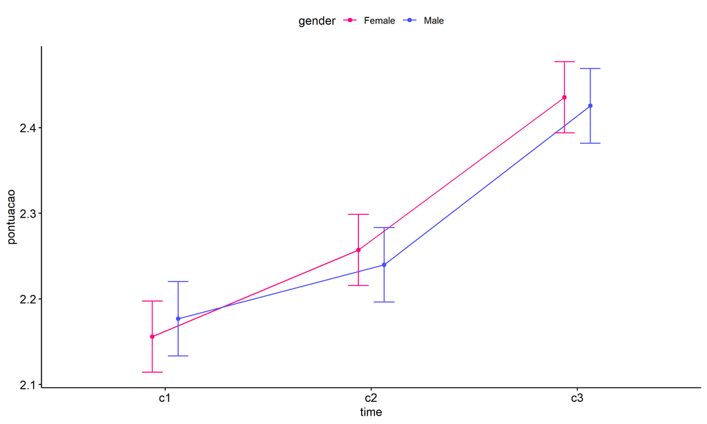

```r
pwc <- add_xy_position(pwc, x = "time", fun = "mean_se", dodge = 0.25)
pd <- position_dodge(width = 0.25)
ggline(emms, x = "time", y = "emmean", color = "gender",
       palette = c("#FF007F","#4D4DFF"),
       position = pd, ylab = "pontuacao") +
  geom_errorbar(aes(ymin = conf.low, ymax = conf.high, color = gender),
                position = pd, width = 0.2) +
  stat_pvalue_manual(pwc, hide.ns = T, tip.length = F, linetype = 1)
```

```r
(pwc <- ldat %>% group_by(gender) %>%
    emmeans_test(pontuacao ~ time, detailed = T, p.adjust.method = "bonferroni"))
```

```
## # A tibble: 6 × 15
##   gender term  .y.    group1 group2 null.value estimate     se    df conf.low conf.high statistic        p    p.adj p.adj.signif
## * <fct>  <chr> <chr>  <chr>  <chr>       <dbl>    <dbl>  <dbl> <dbl>    <dbl>     <dbl>     <dbl>    <dbl>    <dbl> <chr>
## 1 Female time  pontu… c1     c2              0  -0.101  0.0300  7803   -0.160  -0.0425      -3.38 7.33e- 4 2.20e- 3 **
## 2 Female time  pontu… c1     c3              0  -0.280  0.0300  7803   -0.338  -0.221       -9.33 1.33e-20 3.98e-20 ****
## 3 Female time  pontu… c2     c3              0  -0.178  0.0300  7803   -0.237  -0.120       -5.95 2.73e- 9 8.19e- 9 ****
## 4 Male   time  pontu… c1     c2              0  -0.0630 0.0314  7803   -0.125  -0.00148     -2.01 4.47e- 2 1.34e- 1 ns
## 5 Male   time  pontu… c1     c3              0  -0.249  0.0314  7803   -0.310  -0.187       -7.92 2.79e-15 8.38e-15 ****
## 6 Male   time  pontu… c2     c3              0  -0.186  0.0314  7803   -0.247  -0.124       -5.91 3.60e- 9 1.08e- 8 ****
```

| gender | term | .y. | group1 | group2 | null.value | estimate | se | df | conf.low | conf.high | statistic | p | p.adj | p.adj.signif |
| --- | --- | --- | --- | --- | --- | --- | --- | --- | --- | --- | --- | --- | --- | --- |
| Female | time | pontuacao | c1 | c2 | 0 | -0.101 | 0.030 | 7803 | -0.160 | -0.042 | -3.378 | 0.001 | 0.002 | ** |
| Female | time | pontuacao | c1 | c3 | 0 | -0.280 | 0.030 | 7803 | -0.338 | -0.221 | -9.332 | 0.000 | 0.000 | **** |
| Female | time | pontuacao | c2 | c3 | 0 | -0.178 | 0.030 | 7803 | -0.237 | -0.120 | -5.954 | 0.000 | 0.000 | **** |
| Male | time | pontuacao | c1 | c2 | 0 | -0.063 | 0.031 | 7803 | -0.125 | -0.001 | -2.007 | 0.045 | 0.134 | ns |
| Male | time | pontuacao | c1 | c3 | 0 | -0.249 | 0.031 | 7803 | -0.310 | -0.187 | -7.916 | 0.000 | 0.000 | **** |
| Male | time | pontuacao | c2 | c3 | 0 | -0.186 | 0.031 | 7803 | -0.247 | -0.124 | -5.909 | 0.000 | 0.000 | **** |

```r
(emms <- get_emmeans(pwc))
```

```
## # A tibble: 6 × 8
##   gender time  emmean     se    df conf.low conf.high method
##   <fct>  <fct>  <dbl>  <dbl> <dbl>    <dbl>     <dbl> <chr>
## 1 Female c1      2.16 0.0212  7803     2.11      2.20 Emmeans test
## 2 Female c2      2.26 0.0212  7803     2.22      2.30 Emmeans test
## 3 Female c3      2.44 0.0212  7803     2.39      2.48 Emmeans test
## 4 Male   c1      2.18 0.0222  7803     2.13      2.22 Emmeans test
## 5 Male   c2      2.24 0.0222  7803     2.20      2.28 Emmeans test
## 6 Male   c3      2.43 0.0222  7803     2.38      2.47 Emmeans test
```

| gender | time | emmean | se | df | conf.low | conf.high | method |
| --- | --- | --- | --- | --- | --- | --- | --- |
| Female | c1 | 2.156 | 0.021 | 7803 | 2.114 | 2.197 | Emmeans test |
| Female | c2 | 2.257 | 0.021 | 7803 | 2.216 | 2.299 | Emmeans test |
| Female | c3 | 2.435 | 0.021 | 7803 | 2.394 | 2.477 | Emmeans test |
| Male | c1 | 2.177 | 0.022 | 7803 | 2.133 | 2.220 | Emmeans test |
| Male | c2 | 2.240 | 0.022 | 7803 | 2.196 | 2.283 | Emmeans test |
| Male | c3 | 2.425 | 0.022 | 7803 | 2.382 | 2.469 | Emmeans test |

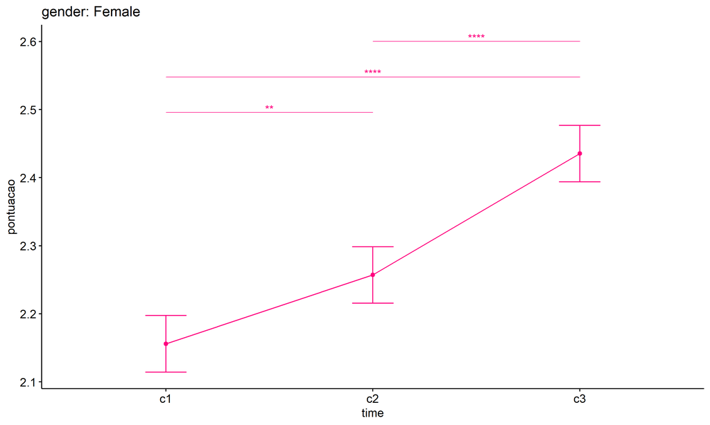

```r
emms.gg <- emms[which(emms$gender == "Female"),]
if (nrow(emms.gg) > 0)
  ggline(emms.gg, x = "time", y = "emmean", color = "#FF007F", ylab = "pontuacao") +
    geom_errorbar(aes(ymin = conf.low, ymax = conf.high),
                  width = 0.2, color = "#FF007F") +
    stat_pvalue_manual(
      add_xy_position(pwc[which(pwc$gender == "Female"),],
                      x = "time", fun = "mean_se"),
      hide.ns = T, color = "#FF007F", tip.length = F) +
    labs(title = "gender: Female")+
    theme(legend.text = element_blank())
```

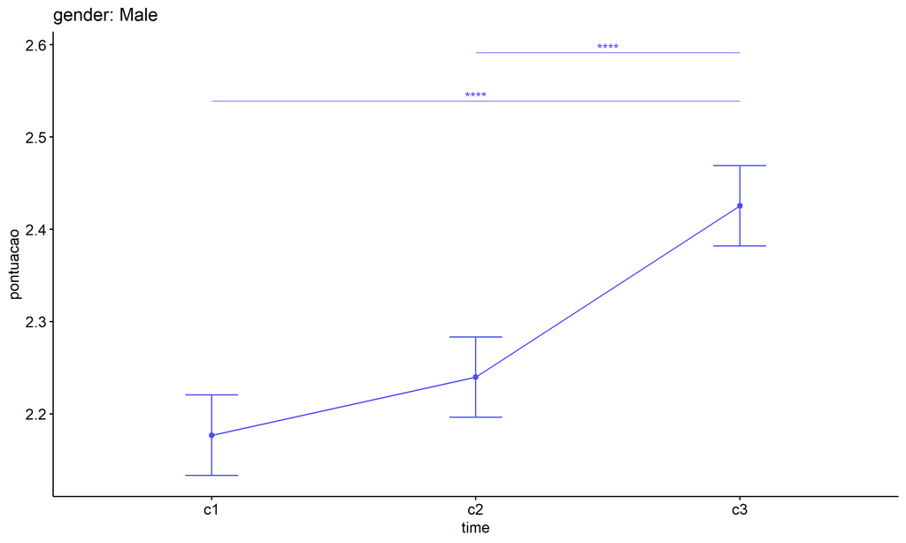

```r
emms.gg <- emms[which(emms$gender == "Male"),]
if (nrow(emms.gg) > 0)
  ggline(emms.gg, x = "time", y = "emmean", color = "#4D4DFF", ylab = "pontuacao") +
    geom_errorbar(aes(ymin = conf.low, ymax = conf.high),
                  width = 0.2, color = "#4D4DFF") +
    stat_pvalue_manual(
      add_xy_position(pwc[which(pwc$gender == "Male"),],
                      x = "time", fun = "mean_se"),
      hide.ns = T, color = "#4D4DFF", tip.length = F) +
    labs(title = "gender: Male")+
    theme(legend.text = element_blank())
```

## PairWise Computation after removing non.normal data

```r
if (length(non.ids) > 0)
  (pwc2 <- ldat2 %>% group_by(time) %>%
     emmeans_test(pontuacao ~ gender, detailed = T, p.adjust.method = "bonferroni"))
```

```r
if (length(non.ids) > 0)
  (emms2 <- get_emmeans(pwc2))
```

```r
if (length(non.ids) > 0) {
  pwc2 <- add_xy_position(pwc2, x = "time", fun = "mean_se", dodge = 0.25)
  pd2 <- position_dodge(width = 0.25)

  ggline(emms2, x = "time", y = "emmean", color = "gender",
         palette = c("#FF007F","#4D4DFF"),
         position = pd, ylab = "pontuacao") +
    geom_errorbar(aes(ymin = conf.low, ymax = conf.high, color = gender),
                position = pd, width = 0.2) +
    stat_pvalue_manual(pwc2, hide.ns = T, tip.length = F, linetype = 1)
}
```

```r
if (length(non.ids) > 0)
  (pwc2 <- ldat2 %>% group_by(gender) %>%
     emmeans_test(pontuacao ~ time, detailed = T, p.adjust.method = "bonferroni"))
```

```r
if (length(non.ids) > 0)
  (emms2 <- get_emmeans(pwc2))
```

```r
if (length(non.ids) > 0) {
  emms.gg <- emms2[which(emms2$gender == "Female"),]
  if (nrow(emms.gg) > 0)
    ggline(emms.gg, x = "time", y = "emmean", color = "#FF007F", ylab = "pontuacao") +
    geom_errorbar(aes(ymin = conf.low, ymax = conf.high),
                  width = 0.2, color = "#FF007F") +
    stat_pvalue_manual(
      add_xy_position(pwc[which(pwc$gender == "Female"),],
                      x = "time", fun = "mean_se"),
      hide.ns = T, color = "#FF007F", tip.length = F) +
    labs(title = "gender: Female") +
    theme(legend.text = element_blank())
}
```

```r
if (length(non.ids) > 0) {
  emms.gg <- emms2[which(emms2$gender == "Male"),]
  if (nrow(emms.gg) > 0)
    ggline(emms.gg, x = "time", y = "emmean", color = "#4D4DFF", ylab = "pontuacao") +
    geom_errorbar(aes(ymin = conf.low, ymax = conf.high),
                  width = 0.2, color = "#4D4DFF") +
    stat_pvalue_manual(
      add_xy_position(pwc[which(pwc$gender == "Male"),],
                      x = "time", fun = "mean_se"),
      hide.ns = T, color = "#4D4DFF", tip.length = F) +
    labs(title = "gender: Male") +
    theme(legend.text = element_blank())
}
```

# ANOVA: pontuacao ~ time*localizacao + Error(id/time)

## Data Preparation

```r
data <- edat[,c("aluno_id","localizacao","ciclo","pontuacao")]
data <- data[data$ciclo %in% c("Primeiro Ciclo","Segundo Ciclo","Terceiro Ciclo"),]
data$ciclo <- factor(data$ciclo, c("Primeiro Ciclo","Segundo Ciclo","Terceiro Ciclo"))
data <- unique(data)

wdat <- spread(data, ciclo, pontuacao)
wdat <- wdat[complete.cases(wdat),]
colnames(wdat) <- c("id","localizacao","c1","c2","c3")

ldat <- gather(wdat, key = time, value = pontuacao, c1,c2,c3) %>%
  convert_as_factor(id, time)
ldat <- remove_group_data(ldat, "pontuacao", c("time", "localizacao"), n.limit = 30)
ldat$localizacao <- factor(ldat$localizacao, sort(unique(ldat$localizacao)))
```

### Check assumptions: Identifying Outliers

```r
outliers <- identify_outliers(group_by(ldat, time, localizacao), pontuacao)
(outliers <- outliers[outliers$is.extreme == T,])
```

```
## # A tibble: 1,047 × 6
##    localizacao time  id                   pontuacao is.outlier is.extreme
##    <fct>       <fct> <fct>                    <dbl> <lgl>      <lgl>
##  1 Rural       c1    0w3VhiMf67CbcpR6aZCL       5   TRUE       TRUE
##  2 Rural       c1    1j6UeRYoeJDXM0grwZCJ       3.5 TRUE       TRUE
##  3 Rural       c1    1PlxEF4tmJySD3G46PLB       3.5 TRUE       TRUE
##  4 Rural       c1    2l9eL5QVtUNWf7HSZPbv       3.5 TRUE       TRUE
##  5 Rural       c1    3roHN14ps3mqIKTOGrvj       3   TRUE       TRUE
##  6 Rural       c1    4UY0Zge7bWrXHTAaYi3U       4   TRUE       TRUE
##  7 Rural       c1    6N2ACmyrqNBgfOvicubH       3.5 TRUE       TRUE
##  8 Rural       c1    6T5xYwUo6kDjNVlSqng5       3.5 TRUE       TRUE
##  9 Rural       c1    7n7TdyIH0Wy2Z2on0Ud0       3.5 TRUE       TRUE
## 10 Rural       c1    810Nxa9nOxSTQkQcLDhH       3.5 TRUE       TRUE
## # ℹ 1,037 more rows
```

| localizacao | time | id | pontuacao | is.outlier | is.extreme |
| --- | --- | --- | --- | --- | --- |
| Rural | c1 | 0w3VhiMf67CbcpR6aZCL | 5.000 | TRUE | TRUE |
| Rural | c1 | 1j6UeRYoeJDXM0grwZCJ | 3.500 | TRUE | TRUE |
| Rural | c1 | 1PlxEF4tmJySD3G46PLB | 3.500 | TRUE | TRUE |
| Rural | c1 | 2l9eL5QVtUNWf7HSZPbv | 3.500 | TRUE | TRUE |
| Rural | c1 | 3roHN14ps3mqIKTOGrvj | 3.000 | TRUE | TRUE |
| Rural | c1 | 4UY0Zge7bWrXHTAaYi3U | 4.000 | TRUE | TRUE |
| Rural | c1 | 6N2ACmyrqNBgfOvicubH | 3.500 | TRUE | TRUE |
| Rural | c1 | 6T5xYwUo6kDjNVlSqng5 | 3.500 | TRUE | TRUE |
| Rural | c1 | 7n7TdyIH0Wy2Z2on0Ud0 | 3.500 | TRUE | TRUE |
| Rural | c1 | 810Nxa9nOxSTQkQcLDhH | 3.500 | TRUE | TRUE |
| Rural | c1 | 87xGodW9Z9oWGGf26blt | 5.000 | TRUE | TRUE |
| Rural | c1 | atGEQplKO1omiu3hdOkr | 3.500 | TRUE | TRUE |
| Rural | c1 | bicRuWjKBX2nhWEdR2gT | 3.500 | TRUE | TRUE |
| Rural | c1 | CApu4sPxX6TUOXcVd5Q4 | 3.000 | TRUE | TRUE |
| Rural | c1 | CCkKOhn0UVSkJHbSjgzS | 5.000 | TRUE | TRUE |
| Rural | c1 | CnDHyGy00t97Hh8JGKqg | 3.500 | TRUE | TRUE |
| Rural | c1 | CS7y5BCxFuWSVdvF9C6M | 3.000 | TRUE | TRUE |
| Rural | c1 | D1HfJKTVqjrpCJx97l3v | 5.000 | TRUE | TRUE |
| Rural | c1 | D3xqy0zcDXd1HoRlfrXr | 5.000 | TRUE | TRUE |
| Rural | c1 | dieaAtUumyYxX7zGb7Sb | 4.000 | TRUE | TRUE |
| Rural | c1 | DKEsQosaERswlkB803hB | 3.500 | TRUE | TRUE |
| Rural | c1 | ETyWmmt6JYMQVyYo8Byu | 5.000 | TRUE | TRUE |
| Rural | c1 | fTT51ooRMooqYQS36Jv0 | 3.500 | TRUE | TRUE |
| Rural | c1 | g1dgNJfnnfRiVAHnsqS4 | 3.500 | TRUE | TRUE |
| Rural | c1 | GPsn9wgK5IpfjHgx51CV | 5.000 | TRUE | TRUE |
| Rural | c1 | gZXmphJ8jrUySX3i0ORd | 3.500 | TRUE | TRUE |
| Rural | c1 | I61sdI4ZJKyLGpto00Hp | 3.000 | TRUE | TRUE |
| Rural | c1 | iutpBZMAtM92qcbyCDHB | 3.500 | TRUE | TRUE |
| Rural | c1 | iXqE1bAFPsYn56jTzZQS | 5.000 | TRUE | TRUE |
| Rural | c1 | J2xCnjFPxFB61qc76V3F | 5.000 | TRUE | TRUE |

[output cut: 1017 more lines]

### Check assumptions: Normality Test

```r
(normality.df <- normality.test.per.groups(ldat, "pontuacao", c("time", "localizacao")))
```

```
##         var  variable time localizacao    n skewness  kurtosis symmetry statistic     method p p.signif normality
## 1 pontuacao pontuacao   c1       Rural  656 3.852353 14.384650       NO  540.6278 D'Agostino 0     ****         -
## 2 pontuacao pontuacao   c1      Urbana 2117 3.796220 13.894317       NO 1649.6513 D'Agostino 0     ****         -
## 3 pontuacao pontuacao   c2       Rural  656 2.978527  7.510042       NO  412.4541 D'Agostino 0     ****         -
## 4 pontuacao pontuacao   c2      Urbana 2117 2.926480  7.249011       NO 1255.1070 D'Agostino 0     ****         -
## 5 pontuacao pontuacao   c3       Rural  656 1.775399  1.408875       NO  197.4729 D'Agostino 0     ****         -
## 6 pontuacao pontuacao   c3      Urbana 2117 2.061510  2.630534       NO  789.2738 D'Agostino 0     ****         -
```

| var | variable | time | localizacao | n | skewness | kurtosis | symmetry | statistic | method | p | p.signif | normality |
| --- | --- | --- | --- | --- | --- | --- | --- | --- | --- | --- | --- | --- |
| pontuacao | pontuacao | c1 | Rural | 656 | 3.852 | 14.385 | NO | 540.628 | D’Agostino | 0 | **** | - |
| pontuacao | pontuacao | c1 | Urbana | 2117 | 3.796 | 13.894 | NO | 1649.651 | D’Agostino | 0 | **** | - |
| pontuacao | pontuacao | c2 | Rural | 656 | 2.979 | 7.510 | NO | 412.454 | D’Agostino | 0 | **** | - |
| pontuacao | pontuacao | c2 | Urbana | 2117 | 2.926 | 7.249 | NO | 1255.107 | D’Agostino | 0 | **** | - |
| pontuacao | pontuacao | c3 | Rural | 656 | 1.775 | 1.409 | NO | 197.473 | D’Agostino | 0 | **** | - |
| pontuacao | pontuacao | c3 | Urbana | 2117 | 2.062 | 2.631 | NO | 789.274 | D’Agostino | 0 | **** | - |

```r
(non.ids <- unique(do.call(
  c, lapply(which(normality.df$normality == 'NO'), FUN = function(i) {
  idx = which(ldat$time == normality.df$time[i] &
                ldat$localizacao == normality.df$localizacao[i])
  getNonNormal(ldat$"pontuacao"[idx], ldat$id[idx])
}))))
```

```r
if (length(non.ids) > 0)
  ldat2 <- ldat[!ldat$id %in% non.ids,]
```

### Summary Statistics

```r
(sdat <- ldat %>% group_by(time, localizacao) %>%
   get_summary_stats(pontuacao, type = "mean_sd"))
```

```
## # A tibble: 6 × 6
##   localizacao time  variable      n  mean    sd
##   <fct>       <fct> <fct>     <dbl> <dbl> <dbl>
## 1 Rural       c1    pontuacao   656  2.16 0.575
## 2 Urbana      c1    pontuacao  2117  2.16 0.581
## 3 Rural       c2    pontuacao   656  2.24 0.743
## 4 Urbana      c2    pontuacao  2117  2.25 0.75
## 5 Rural       c3    pontuacao   656  2.49 1.03
## 6 Urbana      c3    pontuacao  2117  2.41 0.938
```

| localizacao | time | variable | n | mean | sd |
| --- | --- | --- | --- | --- | --- |
| Rural | c1 | pontuacao | 656 | 2.157 | 0.575 |
| Urbana | c1 | pontuacao | 2117 | 2.161 | 0.581 |
| Rural | c2 | pontuacao | 656 | 2.243 | 0.743 |
| Urbana | c2 | pontuacao | 2117 | 2.254 | 0.750 |
| Rural | c3 | pontuacao | 656 | 2.491 | 1.033 |
| Urbana | c3 | pontuacao | 2117 | 2.408 | 0.938 |

```r
if (length(non.ids) > 0)
  (sdat <- ldat2 %>% group_by(time, localizacao) %>%
      get_summary_stats(pontuacao, type = "mean_sd"))
```

| localizacao | time | variable | n | mean | sd |
| --- | --- | --- | --- | --- | --- |
| Rural | c1 | pontuacao | 656 | 2.157 | 0.575 |
| Urbana | c1 | pontuacao | 2117 | 2.161 | 0.581 |
| Rural | c2 | pontuacao | 656 | 2.243 | 0.743 |
| Urbana | c2 | pontuacao | 2117 | 2.254 | 0.750 |
| Rural | c3 | pontuacao | 656 | 2.491 | 1.033 |
| Urbana | c3 | pontuacao | 2117 | 2.408 | 0.938 |

## ANOVA Computation

```r
(res.aov <- anova_test(ldat, dv = pontuacao, wid = id, between = localizacao, within = time))
```

```
## ANOVA Table (type III tests)
##
## $ANOVA
##             Effect DFn  DFd      F                                      p p<.05      ges
## 1      localizacao   1 2771  1.110 0.291999999999999981792342396147432737       0.000150
## 2             time   2 5542 77.757 0.000000000000000000000000000000000496     * 0.017000
## 3 localizacao:time   2 5542  2.409 0.089999999999999996669330926124530379       0.000544
##
## $`Mauchly's Test for Sphericity`
##             Effect    W                                          p p<.05
## 1             time 0.94 0.0000000000000000000000000000000000000384     *
## 2 localizacao:time 0.94 0.0000000000000000000000000000000000000384     *
##
## $`Sphericity Corrections`
##             Effect   GGe        DF[GG]                                p[GG] p[GG]<.05   HFe        DF[HF]
## 1             time 0.943 1.89, 5226.78 0.0000000000000000000000000000000294         * 0.944 1.89, 5230.22
## 2 localizacao:time 0.943 1.89, 5226.78 0.0929999999999999993338661852249061           0.944 1.89, 5230.22
##                                  p[HF] p[HF]<.05
## 1 0.0000000000000000000000000000000282         *
## 2 0.0929999999999999993338661852249061
```

| Effect | DFn | DFd | F | p | p<.05 | ges |
| --- | --- | --- | --- | --- | --- | --- |
| localizacao | 1 | 2771 | 1.110 | 0.292 |  | 0.000 |
| time | 2 | 5542 | 77.757 | 0.000 | * | 0.017 |
| localizacao:time | 2 | 5542 | 2.409 | 0.090 |  | 0.001 |

| Effect | W | p | p<.05 |
| --- | --- | --- | --- |
| time | 0.94 | 0 | * |
| localizacao:time | 0.94 | 0 | * |

| Effect | GGe | DF[GG] | p[GG] | p[GG]<.05 | HFe | DF[HF] | p[HF] | p[HF]<.05 |
| --- | --- | --- | --- | --- | --- | --- | --- | --- |
| time | 0.943 | 1.89, 5226.78 | 0.000 | * | 0.944 | 1.89, 5230.22 | 0.000 | * |
| localizacao:time | 0.943 | 1.89, 5226.78 | 0.093 |  | 0.944 | 1.89, 5230.22 | 0.093 |  |

## ANOVA Computation after removing non.normal data

```r
if (length(non.ids) > 0)
  (res.aov2 <- anova_test(ldat2, dv = pontuacao, wid = id, between = localizacao , within = time))
```

## PairWise Computation

```r
(pwc <- ldat %>% group_by(time) %>%
   emmeans_test(pontuacao ~ localizacao, detailed = T, p.adjust.method = "bonferroni"))
```

```
## # A tibble: 3 × 15
##   time  term        .y.   group1 group2 null.value estimate     se    df conf.low conf.high statistic      p  p.adj p.adj.signif
## * <fct> <chr>       <chr> <chr>  <chr>       <dbl>    <dbl>  <dbl> <dbl>    <dbl>     <dbl>     <dbl>  <dbl>  <dbl> <chr>
## 1 c1    localizacao pont… Rural  Urbana          0 -0.00442 0.0348  8313  -0.0726    0.0638    -0.127 0.899  0.899  ns
## 2 c2    localizacao pont… Rural  Urbana          0 -0.0110  0.0348  8313  -0.0792    0.0572    -0.317 0.751  0.751  ns
## 3 c3    localizacao pont… Rural  Urbana          0  0.0827  0.0348  8313   0.0145    0.151      2.38  0.0175 0.0175 *
```

| time | term | .y. | group1 | group2 | null.value | estimate | se | df | conf.low | conf.high | statistic | p | p.adj | p.adj.signif |
| --- | --- | --- | --- | --- | --- | --- | --- | --- | --- | --- | --- | --- | --- | --- |
| c1 | localizacao | pontuacao | Rural | Urbana | 0 | -0.004 | 0.035 | 8313 | -0.073 | 0.064 | -0.127 | 0.899 | 0.899 | ns |
| c2 | localizacao | pontuacao | Rural | Urbana | 0 | -0.011 | 0.035 | 8313 | -0.079 | 0.057 | -0.317 | 0.751 | 0.751 | ns |
| c3 | localizacao | pontuacao | Rural | Urbana | 0 | 0.083 | 0.035 | 8313 | 0.015 | 0.151 | 2.377 | 0.017 | 0.017 | * |

```r
(emms <- get_emmeans(pwc))
```

```
## # A tibble: 6 × 8
##   time  localizacao emmean     se    df conf.low conf.high method
##   <fct> <fct>        <dbl>  <dbl> <dbl>    <dbl>     <dbl> <chr>
## 1 c1    Rural         2.16 0.0304  8313     2.10      2.22 Emmeans test
## 2 c1    Urbana        2.16 0.0169  8313     2.13      2.19 Emmeans test
## 3 c2    Rural         2.24 0.0304  8313     2.18      2.30 Emmeans test
## 4 c2    Urbana        2.25 0.0169  8313     2.22      2.29 Emmeans test
## 5 c3    Rural         2.49 0.0304  8313     2.43      2.55 Emmeans test
## 6 c3    Urbana        2.41 0.0169  8313     2.37      2.44 Emmeans test
```

| time | localizacao | emmean | se | df | conf.low | conf.high | method |
| --- | --- | --- | --- | --- | --- | --- | --- |
| c1 | Rural | 2.157 | 0.030 | 8313 | 2.097 | 2.217 | Emmeans test |
| c1 | Urbana | 2.161 | 0.017 | 8313 | 2.128 | 2.195 | Emmeans test |
| c2 | Rural | 2.243 | 0.030 | 8313 | 2.184 | 2.303 | Emmeans test |
| c2 | Urbana | 2.254 | 0.017 | 8313 | 2.221 | 2.287 | Emmeans test |
| c3 | Rural | 2.491 | 0.030 | 8313 | 2.431 | 2.550 | Emmeans test |
| c3 | Urbana | 2.408 | 0.017 | 8313 | 2.375 | 2.441 | Emmeans test |

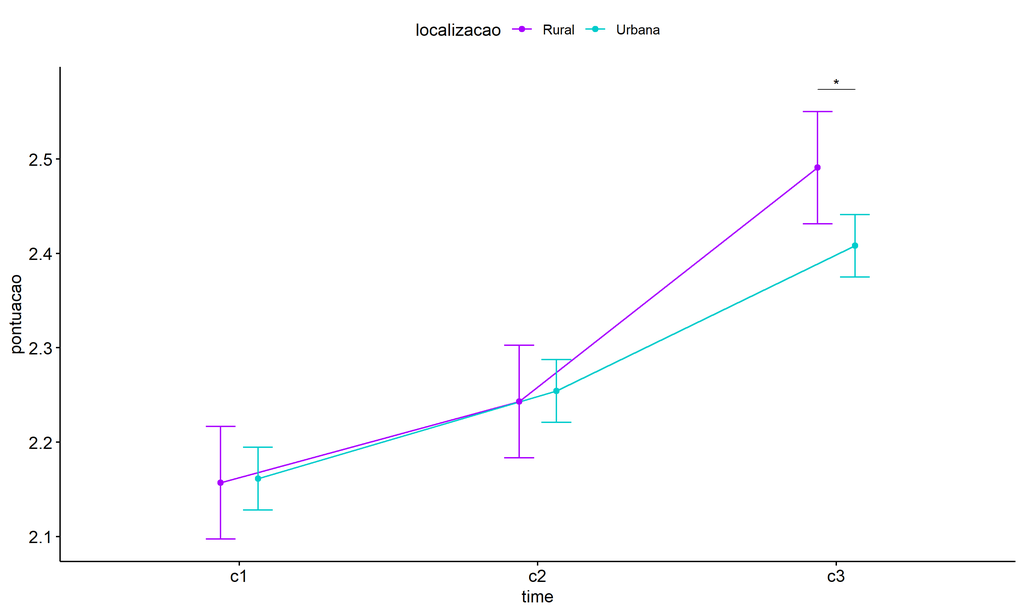

```r
pwc <- add_xy_position(pwc, x = "time", fun = "mean_se", dodge = 0.25)
pd <- position_dodge(width = 0.25)
ggline(emms, x = "time", y = "emmean", color = "localizacao",
       palette = c("#AA00FF","#00CCCC"),
       position = pd, ylab = "pontuacao") +
  geom_errorbar(aes(ymin = conf.low, ymax = conf.high, color = localizacao),
                position = pd, width = 0.2) +
  stat_pvalue_manual(pwc, hide.ns = T, tip.length = F, linetype = 1)
```

```r
(pwc <- ldat %>% group_by(localizacao) %>%
    emmeans_test(pontuacao ~ time, detailed = T, p.adjust.method = "bonferroni"))
```

```
## # A tibble: 6 × 15
##   localizacao term  .y.       group1 group2 null.value estimate     se    df conf.low conf.high statistic        p    p.adj
## * <fct>       <chr> <chr>     <chr>  <chr>       <dbl>    <dbl>  <dbl> <dbl>    <dbl>     <dbl>     <dbl>    <dbl>    <dbl>
## 1 Rural       time  pontuacao c1     c2              0  -0.0861 0.0430  8313   -0.170  -0.00184     -2.00 4.52e- 2 1.36e- 1
## 2 Rural       time  pontuacao c1     c3              0  -0.334  0.0430  8313   -0.418  -0.250       -7.76 9.23e-15 2.77e-14
## 3 Rural       time  pontuacao c2     c3              0  -0.248  0.0430  8313   -0.332  -0.163       -5.76 8.67e- 9 2.60e- 8
## 4 Urbana      time  pontuacao c1     c2              0  -0.0927 0.0239  8313   -0.140  -0.0458      -3.87 1.08e- 4 3.23e- 4
## 5 Urbana      time  pontuacao c1     c3              0  -0.247  0.0239  8313   -0.294  -0.200      -10.3  9.32e-25 2.80e-24
## 6 Urbana      time  pontuacao c2     c3              0  -0.154  0.0239  8313   -0.201  -0.107       -6.43 1.33e-10 4.00e-10
## # ℹ 1 more variable: p.adj.signif <chr>
```

| localizacao | term | .y. | group1 | group2 | null.value | estimate | se | df | conf.low | conf.high | statistic | p | p.adj | p.adj.signif |
| --- | --- | --- | --- | --- | --- | --- | --- | --- | --- | --- | --- | --- | --- | --- |
| Rural | time | pontuacao | c1 | c2 | 0 | -0.086 | 0.043 | 8313 | -0.170 | -0.002 | -2.003 | 0.045 | 0.136 | ns |
| Rural | time | pontuacao | c1 | c3 | 0 | -0.334 | 0.043 | 8313 | -0.418 | -0.250 | -7.764 | 0.000 | 0.000 | **** |
| Rural | time | pontuacao | c2 | c3 | 0 | -0.248 | 0.043 | 8313 | -0.332 | -0.163 | -5.761 | 0.000 | 0.000 | **** |
| Urbana | time | pontuacao | c1 | c2 | 0 | -0.093 | 0.024 | 8313 | -0.140 | -0.046 | -3.874 | 0.000 | 0.000 | *** |
| Urbana | time | pontuacao | c1 | c3 | 0 | -0.247 | 0.024 | 8313 | -0.294 | -0.200 | -10.306 | 0.000 | 0.000 | **** |
| Urbana | time | pontuacao | c2 | c3 | 0 | -0.154 | 0.024 | 8313 | -0.201 | -0.107 | -6.432 | 0.000 | 0.000 | **** |

```r
(emms <- get_emmeans(pwc))
```

```
## # A tibble: 6 × 8
##   localizacao time  emmean     se    df conf.low conf.high method
##   <fct>       <fct>  <dbl>  <dbl> <dbl>    <dbl>     <dbl> <chr>
## 1 Rural       c1      2.16 0.0304  8313     2.10      2.22 Emmeans test
## 2 Rural       c2      2.24 0.0304  8313     2.18      2.30 Emmeans test
## 3 Rural       c3      2.49 0.0304  8313     2.43      2.55 Emmeans test
## 4 Urbana      c1      2.16 0.0169  8313     2.13      2.19 Emmeans test
## 5 Urbana      c2      2.25 0.0169  8313     2.22      2.29 Emmeans test
## 6 Urbana      c3      2.41 0.0169  8313     2.37      2.44 Emmeans test
```

| localizacao | time | emmean | se | df | conf.low | conf.high | method |
| --- | --- | --- | --- | --- | --- | --- | --- |
| Rural | c1 | 2.157 | 0.030 | 8313 | 2.097 | 2.217 | Emmeans test |
| Rural | c2 | 2.243 | 0.030 | 8313 | 2.184 | 2.303 | Emmeans test |
| Rural | c3 | 2.491 | 0.030 | 8313 | 2.431 | 2.550 | Emmeans test |
| Urbana | c1 | 2.161 | 0.017 | 8313 | 2.128 | 2.195 | Emmeans test |
| Urbana | c2 | 2.254 | 0.017 | 8313 | 2.221 | 2.287 | Emmeans test |
| Urbana | c3 | 2.408 | 0.017 | 8313 | 2.375 | 2.441 | Emmeans test |

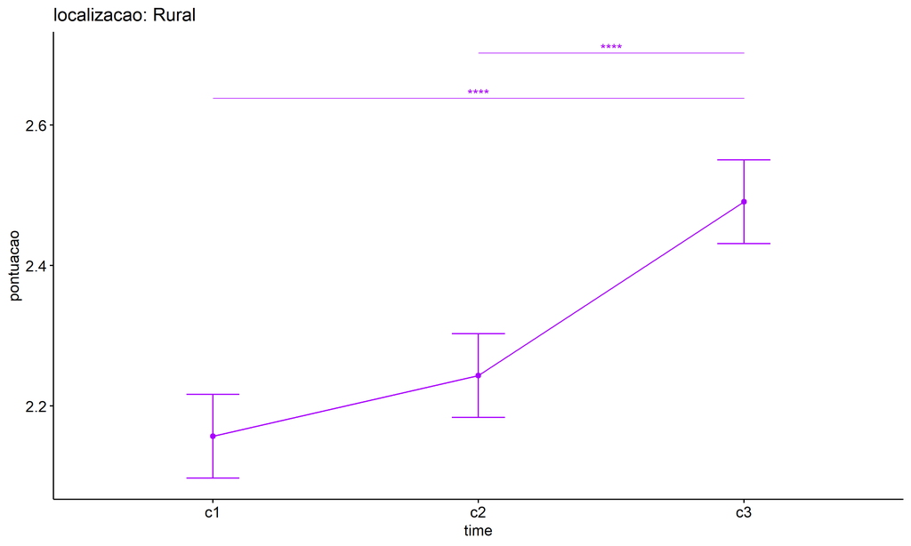

```r
emms.gg <- emms[which(emms$localizacao == "Rural"),]
if (nrow(emms.gg) > 0)
  ggline(emms.gg, x = "time", y = "emmean", color = "#AA00FF", ylab = "pontuacao") +
    geom_errorbar(aes(ymin = conf.low, ymax = conf.high),
                  width = 0.2, color = "#AA00FF") +
    stat_pvalue_manual(
      add_xy_position(pwc[which(pwc$localizacao == "Rural"),],
                      x = "time", fun = "mean_se"),
      hide.ns = T, color = "#AA00FF", tip.length = F) +
    labs(title = "localizacao: Rural")+
    theme(legend.text = element_blank())
```

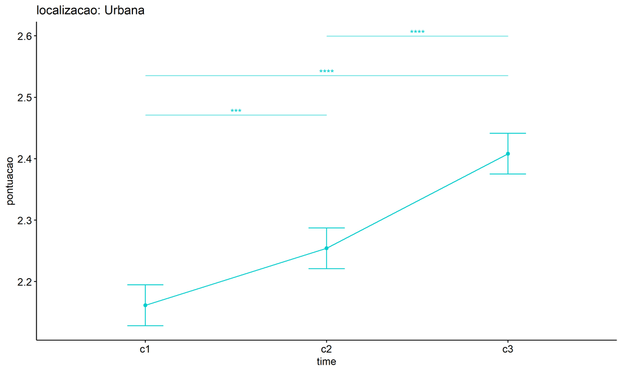

```r
emms.gg <- emms[which(emms$localizacao == "Urbana"),]
if (nrow(emms.gg) > 0)
  ggline(emms.gg, x = "time", y = "emmean", color = "#00CCCC", ylab = "pontuacao") +
    geom_errorbar(aes(ymin = conf.low, ymax = conf.high),
                  width = 0.2, color = "#00CCCC") +
    stat_pvalue_manual(
      add_xy_position(pwc[which(pwc$localizacao == "Urbana"),],
                      x = "time", fun = "mean_se"),
      hide.ns = T, color = "#00CCCC", tip.length = F) +
    labs(title = "localizacao: Urbana")+
    theme(legend.text = element_blank())
```

## PairWise Computation after removing non.normal data

```r
if (length(non.ids) > 0)
  (pwc2 <- ldat2 %>% group_by(time) %>%
     emmeans_test(pontuacao ~ localizacao, detailed = T, p.adjust.method = "bonferroni"))
```

```r
if (length(non.ids) > 0)
  (emms2 <- get_emmeans(pwc2))
```

```r
if (length(non.ids) > 0) {
  pwc2 <- add_xy_position(pwc2, x = "time", fun = "mean_se", dodge = 0.25)
  pd2 <- position_dodge(width = 0.25)

  ggline(emms2, x = "time", y = "emmean", color = "localizacao",
         palette = c("#AA00FF","#00CCCC"),
         position = pd, ylab = "pontuacao") +
    geom_errorbar(aes(ymin = conf.low, ymax = conf.high, color = localizacao),
                position = pd, width = 0.2) +
    stat_pvalue_manual(pwc2, hide.ns = T, tip.length = F, linetype = 1)
}
```

```r
if (length(non.ids) > 0)
  (pwc2 <- ldat2 %>% group_by(localizacao) %>%
     emmeans_test(pontuacao ~ time, detailed = T, p.adjust.method = "bonferroni"))
```

```r
if (length(non.ids) > 0)
  (emms2 <- get_emmeans(pwc2))
```

```r
if (length(non.ids) > 0) {
  emms.gg <- emms2[which(emms2$localizacao == "Rural"),]
  if (nrow(emms.gg) > 0)
    ggline(emms.gg, x = "time", y = "emmean", color = "#AA00FF", ylab = "pontuacao") +
    geom_errorbar(aes(ymin = conf.low, ymax = conf.high),
                  width = 0.2, color = "#AA00FF") +
    stat_pvalue_manual(
      add_xy_position(pwc[which(pwc$localizacao == "Rural"),],
                      x = "time", fun = "mean_se"),
      hide.ns = T, color = "#AA00FF", tip.length = F) +
    labs(title = "localizacao: Rural") +
    theme(legend.text = element_blank())
}
```

```r
if (length(non.ids) > 0) {
  emms.gg <- emms2[which(emms2$localizacao == "Urbana"),]
  if (nrow(emms.gg) > 0)
    ggline(emms.gg, x = "time", y = "emmean", color = "#00CCCC", ylab = "pontuacao") +
    geom_errorbar(aes(ymin = conf.low, ymax = conf.high),
                  width = 0.2, color = "#00CCCC") +
    stat_pvalue_manual(
      add_xy_position(pwc[which(pwc$localizacao == "Urbana"),],
                      x = "time", fun = "mean_se"),
      hide.ns = T, color = "#00CCCC", tip.length = F) +
    labs(title = "localizacao: Urbana") +
    theme(legend.text = element_blank())
}
```

# ANOVA: pontuacao ~ time*regiao + Error(id/time)

## Data Preparation

```r
data <- edat[,c("aluno_id","regiao","ciclo","pontuacao")]
data <- data[data$ciclo %in% c("Primeiro Ciclo","Segundo Ciclo","Terceiro Ciclo"),]
data$ciclo <- factor(data$ciclo, c("Primeiro Ciclo","Segundo Ciclo","Terceiro Ciclo"))
data <- unique(data)

wdat <- spread(data, ciclo, pontuacao)
wdat <- wdat[complete.cases(wdat),]
colnames(wdat) <- c("id","regiao","c1","c2","c3")

ldat <- gather(wdat, key = time, value = pontuacao, c1,c2,c3) %>%
  convert_as_factor(id, time)
ldat <- remove_group_data(ldat, "pontuacao", c("time", "regiao"), n.limit = 30)
ldat$regiao <- factor(ldat$regiao, sort(unique(ldat$regiao)))
```

### Check assumptions: Identifying Outliers

```r
outliers <- identify_outliers(group_by(ldat, time, regiao), pontuacao)
(outliers <- outliers[outliers$is.extreme == T,])
```

```
## # A tibble: 1,029 × 6
##    regiao       time  id                   pontuacao is.outlier is.extreme
##    <fct>        <fct> <fct>                    <dbl> <lgl>      <lgl>
##  1 Centro-Oeste c1    1Z1Qz8zDaMkaAz1Ah80K       5   TRUE       TRUE
##  2 Centro-Oeste c1    5P3WYdHfZOaNtqeKJ9QA       5   TRUE       TRUE
##  3 Centro-Oeste c1    9k9BI8mCq3fddmKjDwxN       3.5 TRUE       TRUE
##  4 Centro-Oeste c1    AIzwxJCfbDsO8ZT4ZZ4h       3   TRUE       TRUE
##  5 Centro-Oeste c1    AVWl60C3KAjiEIcqp9lr       3   TRUE       TRUE
##  6 Centro-Oeste c1    CiV1upa4BM58OvTZsu01       5   TRUE       TRUE
##  7 Centro-Oeste c1    CzO1FzJvMlj6CVXnAlpY       3.5 TRUE       TRUE
##  8 Centro-Oeste c1    dgvqWTQka7lptc3Ft09o       3   TRUE       TRUE
##  9 Centro-Oeste c1    fLBBrxUStMx7WiPdI0Dm       5   TRUE       TRUE
## 10 Centro-Oeste c1    FSILT6Pa2OIvuB8IcM3r       3   TRUE       TRUE
## # ℹ 1,019 more rows
```

| regiao | time | id | pontuacao | is.outlier | is.extreme |
| --- | --- | --- | --- | --- | --- |
| Centro-Oeste | c1 | 1Z1Qz8zDaMkaAz1Ah80K | 5.000 | TRUE | TRUE |
| Centro-Oeste | c1 | 5P3WYdHfZOaNtqeKJ9QA | 5.000 | TRUE | TRUE |
| Centro-Oeste | c1 | 9k9BI8mCq3fddmKjDwxN | 3.500 | TRUE | TRUE |
| Centro-Oeste | c1 | AIzwxJCfbDsO8ZT4ZZ4h | 3.000 | TRUE | TRUE |
| Centro-Oeste | c1 | AVWl60C3KAjiEIcqp9lr | 3.000 | TRUE | TRUE |
| Centro-Oeste | c1 | CiV1upa4BM58OvTZsu01 | 5.000 | TRUE | TRUE |
| Centro-Oeste | c1 | CzO1FzJvMlj6CVXnAlpY | 3.500 | TRUE | TRUE |
| Centro-Oeste | c1 | dgvqWTQka7lptc3Ft09o | 3.000 | TRUE | TRUE |
| Centro-Oeste | c1 | fLBBrxUStMx7WiPdI0Dm | 5.000 | TRUE | TRUE |
| Centro-Oeste | c1 | FSILT6Pa2OIvuB8IcM3r | 3.000 | TRUE | TRUE |
| Centro-Oeste | c1 | KPMkDhksSiEWVEIUT1LG | 3.500 | TRUE | TRUE |
| Centro-Oeste | c1 | pDNFXjYX3Cn2inX68ur1 | 3.000 | TRUE | TRUE |
| Centro-Oeste | c1 | QasU7a9JiIu1XHAPVJk9 | 3.000 | TRUE | TRUE |
| Centro-Oeste | c1 | qbpdhqIdqf7n3lmU2n4I | 3.500 | TRUE | TRUE |
| Centro-Oeste | c1 | qzTs8WTlyWt08Vt1JvtQ | 3.500 | TRUE | TRUE |
| Centro-Oeste | c1 | whgR2j3Go6DAaVNwNLom | 3.500 | TRUE | TRUE |
| Centro-Oeste | c1 | xG2Z9gaPgwiRw7YIbYzr | 3.000 | TRUE | TRUE |
| Centro-Oeste | c1 | Xq3402VdKr7fuvkfZchf | 5.000 | TRUE | TRUE |
| Centro-Oeste | c1 | XR80QrMN57TjohHYFg5d | 3.500 | TRUE | TRUE |
| Centro-Oeste | c1 | Zd0PsCueY8uUv5kZj7tr | 5.000 | TRUE | TRUE |
| Centro-Oeste | c1 | zPOwHw0YDzGIreCfW6KG | 4.000 | TRUE | TRUE |
| Nordeste | c1 | 0snZiNyJSvQ3y78pNyZ8 | 5.000 | TRUE | TRUE |
| Nordeste | c1 | 0w3VhiMf67CbcpR6aZCL | 5.000 | TRUE | TRUE |
| Nordeste | c1 | 0wDHSyctDDkjP6OPE3c8 | 5.000 | TRUE | TRUE |
| Nordeste | c1 | 1j6UeRYoeJDXM0grwZCJ | 3.500 | TRUE | TRUE |
| Nordeste | c1 | 1PlxEF4tmJySD3G46PLB | 3.500 | TRUE | TRUE |
| Nordeste | c1 | 2dPipf6cnqDHy9qCzjpa | 4.500 | TRUE | TRUE |
| Nordeste | c1 | 2l9eL5QVtUNWf7HSZPbv | 3.500 | TRUE | TRUE |
| Nordeste | c1 | 3roHN14ps3mqIKTOGrvj | 3.000 | TRUE | TRUE |
| Nordeste | c1 | 42WvKYOHdVI1hIxd9ZJl | 4.000 | TRUE | TRUE |

[output cut: 999 more lines]

### Check assumptions: Normality Test

```r
(normality.df <- normality.test.per.groups(ldat, "pontuacao", c("time", "regiao")))
```

```
##          var  variable time       regiao    n skewness   kurtosis symmetry  statistic     method                p p.signif
## 1  pontuacao pontuacao   c1 Centro-Oeste  216 3.669552 13.2742115       NO  191.41939 D'Agostino 0.00000000000000     ****
## 2  pontuacao pontuacao   c1     Nordeste 1499 4.032944 15.4232482       NO 1239.65369 D'Agostino 0.00000000000000     ****
## 3  pontuacao pontuacao   c1        Norte  202 4.668751 22.8431340       NO  225.02856 D'Agostino 0.00000000000000     ****
## 4  pontuacao pontuacao   c1      Sudeste  693 3.269873 10.2359903       NO  487.17388 D'Agostino 0.00000000000000     ****
## 5  pontuacao pontuacao   c1          Sul  163 3.373890 11.1181949       NO  140.05366 D'Agostino 0.00000000000000     ****
## 6  pontuacao pontuacao   c2 Centro-Oeste  216 2.367880  4.3280903       NO  114.63148 D'Agostino 0.00000000000000     ****
## 7  pontuacao pontuacao   c2     Nordeste 1499 2.935448  7.1862904       NO  896.17672 D'Agostino 0.00000000000000     ****
## 8  pontuacao pontuacao   c2        Norte  202 3.650972 13.1232306       NO  180.12222 D'Agostino 0.00000000000000     ****
## 9  pontuacao pontuacao   c2      Sudeste  693 2.733582  6.1566186       NO  394.23606 D'Agostino 0.00000000000000     ****
## 10 pontuacao pontuacao   c2          Sul  163 4.369820 17.5986902       NO  176.00592 D'Agostino 0.00000000000000     ****
## 11 pontuacao pontuacao   c3 Centro-Oeste  216 2.207955  3.2647685       NO  102.16867 D'Agostino 0.00000000000000     ****
## 12 pontuacao pontuacao   c3     Nordeste 1499 2.135960  2.8517267       NO  589.57352 D'Agostino 0.00000000000000     ****
## 13 pontuacao pontuacao   c3        Norte  202 3.780874 13.7616622       NO  185.41536 D'Agostino 0.00000000000000     ****
## 14 pontuacao pontuacao   c3      Sudeste  693 1.562603  0.8242693       NO  169.12515 D'Agostino 0.00000000000000     ****
```

[output cut: 17 more lines]

| var | variable | time | regiao | n | skewness | kurtosis | symmetry | statistic | method | p | p.signif | normality |
| --- | --- | --- | --- | --- | --- | --- | --- | --- | --- | --- | --- | --- |
| pontuacao | pontuacao | c1 | Centro-Oeste | 216 | 3.670 | 13.274 | NO | 191.419 | D’Agostino | 0 | **** | - |
| pontuacao | pontuacao | c1 | Nordeste | 1499 | 4.033 | 15.423 | NO | 1239.654 | D’Agostino | 0 | **** | - |
| pontuacao | pontuacao | c1 | Norte | 202 | 4.669 | 22.843 | NO | 225.029 | D’Agostino | 0 | **** | - |
| pontuacao | pontuacao | c1 | Sudeste | 693 | 3.270 | 10.236 | NO | 487.174 | D’Agostino | 0 | **** | - |
| pontuacao | pontuacao | c1 | Sul | 163 | 3.374 | 11.118 | NO | 140.054 | D’Agostino | 0 | **** | QQ |
| pontuacao | pontuacao | c2 | Centro-Oeste | 216 | 2.368 | 4.328 | NO | 114.631 | D’Agostino | 0 | **** | - |
| pontuacao | pontuacao | c2 | Nordeste | 1499 | 2.935 | 7.186 | NO | 896.177 | D’Agostino | 0 | **** | - |
| pontuacao | pontuacao | c2 | Norte | 202 | 3.651 | 13.123 | NO | 180.122 | D’Agostino | 0 | **** | - |
| pontuacao | pontuacao | c2 | Sudeste | 693 | 2.734 | 6.157 | NO | 394.236 | D’Agostino | 0 | **** | - |
| pontuacao | pontuacao | c2 | Sul | 163 | 4.370 | 17.599 | NO | 176.006 | D’Agostino | 0 | **** | QQ |
| pontuacao | pontuacao | c3 | Centro-Oeste | 216 | 2.208 | 3.265 | NO | 102.169 | D’Agostino | 0 | **** | - |
| pontuacao | pontuacao | c3 | Nordeste | 1499 | 2.136 | 2.852 | NO | 589.574 | D’Agostino | 0 | **** | - |
| pontuacao | pontuacao | c3 | Norte | 202 | 3.781 | 13.762 | NO | 185.415 | D’Agostino | 0 | **** | - |
| pontuacao | pontuacao | c3 | Sudeste | 693 | 1.563 | 0.824 | NO | 169.125 | D’Agostino | 0 | **** | - |
| pontuacao | pontuacao | c3 | Sul | 163 | 1.398 | 0.206 | NO | 36.258 | D’Agostino | 0 | **** | QQ |

```r
(non.ids <- unique(do.call(
  c, lapply(which(normality.df$normality == 'NO'), FUN = function(i) {
  idx = which(ldat$time == normality.df$time[i] &
                ldat$regiao == normality.df$regiao[i])
  getNonNormal(ldat$"pontuacao"[idx], ldat$id[idx])
}))))
```

```r
if (length(non.ids) > 0)
  ldat2 <- ldat[!ldat$id %in% non.ids,]
```

### Summary Statistics

```r
(sdat <- ldat %>% group_by(time, regiao) %>%
   get_summary_stats(pontuacao, type = "mean_sd"))
```

```
## # A tibble: 15 × 6
##    regiao       time  variable      n  mean    sd
##    <fct>        <fct> <fct>     <dbl> <dbl> <dbl>
##  1 Centro-Oeste c1    pontuacao   216  2.17 0.588
##  2 Nordeste     c1    pontuacao  1499  2.15 0.586
##  3 Norte        c1    pontuacao   202  2.10 0.436
##  4 Sudeste      c1    pontuacao   693  2.19 0.607
##  5 Sul          c1    pontuacao   163  2.16 0.538
##  6 Centro-Oeste c2    pontuacao   216  2.34 0.822
##  7 Nordeste     c2    pontuacao  1499  2.25 0.759
##  8 Norte        c2    pontuacao   202  2.14 0.513
##  9 Sudeste      c2    pontuacao   693  2.29 0.783
## 10 Sul          c2    pontuacao   163  2.13 0.595
## 11 Centro-Oeste c3    pontuacao   216  2.38 0.915
## 12 Nordeste     c3    pontuacao  1499  2.39 0.945
## 13 Norte        c3    pontuacao   202  2.16 0.579
## 14 Sudeste      c3    pontuacao   693  2.55 1.04
## 15 Sul          c3    pontuacao   163  2.61 1.11
```

| regiao | time | variable | n | mean | sd |
| --- | --- | --- | --- | --- | --- |
| Centro-Oeste | c1 | pontuacao | 216 | 2.174 | 0.588 |
| Nordeste | c1 | pontuacao | 1499 | 2.150 | 0.586 |
| Norte | c1 | pontuacao | 202 | 2.101 | 0.436 |
| Sudeste | c1 | pontuacao | 693 | 2.195 | 0.607 |
| Sul | c1 | pontuacao | 163 | 2.163 | 0.538 |
| Centro-Oeste | c2 | pontuacao | 216 | 2.336 | 0.822 |
| Nordeste | c2 | pontuacao | 1499 | 2.251 | 0.759 |
| Norte | c2 | pontuacao | 202 | 2.144 | 0.513 |
| Sudeste | c2 | pontuacao | 693 | 2.286 | 0.783 |
| Sul | c2 | pontuacao | 163 | 2.132 | 0.595 |
| Centro-Oeste | c3 | pontuacao | 216 | 2.375 | 0.915 |
| Nordeste | c3 | pontuacao | 1499 | 2.394 | 0.945 |
| Norte | c3 | pontuacao | 202 | 2.158 | 0.579 |
| Sudeste | c3 | pontuacao | 693 | 2.553 | 1.036 |
| Sul | c3 | pontuacao | 163 | 2.613 | 1.113 |

```r
if (length(non.ids) > 0)
  (sdat <- ldat2 %>% group_by(time, regiao) %>%
      get_summary_stats(pontuacao, type = "mean_sd"))
```

| regiao | time | variable | n | mean | sd |
| --- | --- | --- | --- | --- | --- |
| Centro-Oeste | c1 | pontuacao | 216 | 2.174 | 0.588 |
| Nordeste | c1 | pontuacao | 1499 | 2.150 | 0.586 |
| Norte | c1 | pontuacao | 202 | 2.101 | 0.436 |
| Sudeste | c1 | pontuacao | 693 | 2.195 | 0.607 |
| Sul | c1 | pontuacao | 163 | 2.163 | 0.538 |
| Centro-Oeste | c2 | pontuacao | 216 | 2.336 | 0.822 |
| Nordeste | c2 | pontuacao | 1499 | 2.251 | 0.759 |
| Norte | c2 | pontuacao | 202 | 2.144 | 0.513 |
| Sudeste | c2 | pontuacao | 693 | 2.286 | 0.783 |
| Sul | c2 | pontuacao | 163 | 2.132 | 0.595 |
| Centro-Oeste | c3 | pontuacao | 216 | 2.375 | 0.915 |
| Nordeste | c3 | pontuacao | 1499 | 2.394 | 0.945 |
| Norte | c3 | pontuacao | 202 | 2.158 | 0.579 |
| Sudeste | c3 | pontuacao | 693 | 2.553 | 1.036 |
| Sul | c3 | pontuacao | 163 | 2.613 | 1.113 |

## ANOVA Computation

```r
(res.aov <- anova_test(ldat, dv = pontuacao, wid = id, between = regiao, within = time))
```

```
## ANOVA Table (type III tests)
##
## $ANOVA
##        Effect DFn  DFd      F                        p p<.05   ges
## 1      regiao   4 2768  8.507 0.0000008070000000000000     * 0.005
## 2        time   2 5536 45.241 0.0000000000000000000324     * 0.010
## 3 regiao:time   8 5536  4.254 0.0000414999999999999991     * 0.004
##
## $`Mauchly's Test for Sphericity`
##        Effect     W                                         p p<.05
## 1        time 0.941 0.000000000000000000000000000000000000348     *
## 2 regiao:time 0.941 0.000000000000000000000000000000000000348     *
##
## $`Sphericity Corrections`
##        Effect   GGe        DF[GG]                   p[GG] p[GG]<.05   HFe        DF[HF]                 p[HF] p[HF]<.05
## 1        time 0.944 1.89, 5228.19 0.000000000000000000308         * 0.945 1.89, 5231.65 0.0000000000000000003         *
## 2 regiao:time 0.944 7.56, 5228.19 0.000063399999999999996         * 0.945 7.56, 5231.65 0.0000631000000000000         *
```

| Effect | DFn | DFd | F | p | p<.05 | ges |
| --- | --- | --- | --- | --- | --- | --- |
| regiao | 4 | 2768 | 8.507 | 0 | * | 0.005 |
| time | 2 | 5536 | 45.241 | 0 | * | 0.010 |
| regiao:time | 8 | 5536 | 4.254 | 0 | * | 0.004 |

| Effect | W | p | p<.05 |
| --- | --- | --- | --- |
| time | 0.941 | 0 | * |
| regiao:time | 0.941 | 0 | * |

| Effect | GGe | DF[GG] | p[GG] | p[GG]<.05 | HFe | DF[HF] | p[HF] | p[HF]<.05 |
| --- | --- | --- | --- | --- | --- | --- | --- | --- |
| time | 0.944 | 1.89, 5228.19 | 0 | * | 0.945 | 1.89, 5231.65 | 0 | * |
| regiao:time | 0.944 | 7.56, 5228.19 | 0 | * | 0.945 | 7.56, 5231.65 | 0 | * |

## ANOVA Computation after removing non.normal data

```r
if (length(non.ids) > 0)
  (res.aov2 <- anova_test(ldat2, dv = pontuacao, wid = id, between = regiao , within = time))
```

## PairWise Computation

```r
(pwc <- ldat %>% group_by(time) %>%
   emmeans_test(pontuacao ~ regiao, detailed = T, p.adjust.method = "bonferroni"))
```

| time | term | .y. | group1 | group2 | null.value | estimate | se | df | conf.low | conf.high | statistic | p | p.adj | p.adj.signif |
| --- | --- | --- | --- | --- | --- | --- | --- | --- | --- | --- | --- | --- | --- | --- |
| c1 | regiao | pontuacao | Centro | Oeste | 0 | 0.024 | 0.056 | 8304 | -0.087 | 0.134 | 0.416 | 0.677 | 1.000 | ns |
| c1 | regiao | pontuacao | Centro | Oeste | 0 | 0.072 | 0.076 | 8304 | -0.077 | 0.221 | 0.949 | 0.342 | 1.000 | ns |
| c1 | regiao | pontuacao | Centro | Oeste | 0 | -0.022 | 0.060 | 8304 | -0.140 | 0.097 | -0.356 | 0.722 | 1.000 | ns |
| c1 | regiao | pontuacao | Centro | Oeste | 0 | 0.011 | 0.081 | 8304 | -0.147 | 0.169 | 0.137 | 0.891 | 1.000 | ns |
| c1 | regiao | pontuacao | Nordeste | Norte | 0 | 0.049 | 0.058 | 8304 | -0.065 | 0.163 | 0.836 | 0.403 | 1.000 | ns |
| c1 | regiao | pontuacao | Nordeste | Sudeste | 0 | -0.045 | 0.036 | 8304 | -0.115 | 0.025 | -1.264 | 0.206 | 1.000 | ns |
| c1 | regiao | pontuacao | Nordeste | Sul | 0 | -0.012 | 0.064 | 8304 | -0.138 | 0.113 | -0.195 | 0.845 | 1.000 | ns |
| c1 | regiao | pontuacao | Norte | Sudeste | 0 | -0.094 | 0.062 | 8304 | -0.215 | 0.028 | -1.509 | 0.131 | 1.000 | ns |
| c1 | regiao | pontuacao | Norte | Sul | 0 | -0.061 | 0.082 | 8304 | -0.221 | 0.099 | -0.748 | 0.455 | 1.000 | ns |
| c1 | regiao | pontuacao | Sudeste | Sul | 0 | 0.033 | 0.068 | 8304 | -0.100 | 0.165 | 0.482 | 0.630 | 1.000 | ns |
| c2 | regiao | pontuacao | Centro | Oeste | 0 | 0.085 | 0.056 | 8304 | -0.026 | 0.195 | 1.496 | 0.135 | 1.000 | ns |
| c2 | regiao | pontuacao | Centro | Oeste | 0 | 0.192 | 0.076 | 8304 | 0.043 | 0.341 | 2.528 | 0.011 | 0.115 | ns |
| c2 | regiao | pontuacao | Centro | Oeste | 0 | 0.050 | 0.060 | 8304 | -0.069 | 0.168 | 0.822 | 0.411 | 1.000 | ns |
| c2 | regiao | pontuacao | Centro | Oeste | 0 | 0.204 | 0.081 | 8304 | 0.046 | 0.362 | 2.530 | 0.011 | 0.114 | ns |
| c2 | regiao | pontuacao | Nordeste | Norte | 0 | 0.108 | 0.058 | 8304 | -0.006 | 0.222 | 1.849 | 0.065 | 0.645 | ns |
| c2 | regiao | pontuacao | Nordeste | Sudeste | 0 | -0.035 | 0.036 | 8304 | -0.105 | 0.035 | -0.977 | 0.328 | 1.000 | ns |
| c2 | regiao | pontuacao | Nordeste | Sul | 0 | 0.119 | 0.064 | 8304 | -0.006 | 0.245 | 1.862 | 0.063 | 0.626 | ns |
| c2 | regiao | pontuacao | Norte | Sudeste | 0 | -0.142 | 0.062 | 8304 | -0.264 | -0.021 | -2.294 | 0.022 | 0.218 | ns |
| c2 | regiao | pontuacao | Norte | Sul | 0 | 0.012 | 0.082 | 8304 | -0.149 | 0.172 | 0.143 | 0.887 | 1.000 | ns |
| c2 | regiao | pontuacao | Sudeste | Sul | 0 | 0.154 | 0.068 | 8304 | 0.022 | 0.287 | 2.280 | 0.023 | 0.226 | ns |
| c3 | regiao | pontuacao | Centro | Oeste | 0 | -0.019 | 0.056 | 8304 | -0.129 | 0.092 | -0.329 | 0.742 | 1.000 | ns |
| c3 | regiao | pontuacao | Centro | Oeste | 0 | 0.217 | 0.076 | 8304 | 0.068 | 0.366 | 2.851 | 0.004 | 0.044 | * |
| c3 | regiao | pontuacao | Centro | Oeste | 0 | -0.178 | 0.060 | 8304 | -0.296 | -0.059 | -2.937 | 0.003 | 0.033 | * |
| c3 | regiao | pontuacao | Centro | Oeste | 0 | -0.238 | 0.081 | 8304 | -0.396 | -0.081 | -2.962 | 0.003 | 0.031 | * |
| c3 | regiao | pontuacao | Nordeste | Norte | 0 | 0.235 | 0.058 | 8304 | 0.121 | 0.349 | 4.043 | 0.000 | 0.001 | *** |
| c3 | regiao | pontuacao | Nordeste | Sudeste | 0 | -0.159 | 0.036 | 8304 | -0.229 | -0.089 | -4.461 | 0.000 | 0.000 | **** |
| c3 | regiao | pontuacao | Nordeste | Sul | 0 | -0.220 | 0.064 | 8304 | -0.345 | -0.094 | -3.435 | 0.001 | 0.006 | ** |
| c3 | regiao | pontuacao | Norte | Sudeste | 0 | -0.394 | 0.062 | 8304 | -0.516 | -0.273 | -6.352 | 0.000 | 0.000 | **** |
| c3 | regiao | pontuacao | Norte | Sul | 0 | -0.455 | 0.082 | 8304 | -0.615 | -0.295 | -5.569 | 0.000 | 0.000 | **** |
| c3 | regiao | pontuacao | Sudeste | Sul | 0 | -0.061 | 0.068 | 8304 | -0.193 | 0.072 | -0.900 | 0.368 | 1.000 | ns |

```r
(emms <- get_emmeans(pwc))
```

```
## # A tibble: 15 × 8
##    time  regiao       emmean     se    df conf.low conf.high method
##    <fct> <fct>         <dbl>  <dbl> <dbl>    <dbl>     <dbl> <chr>
##  1 c1    Centro-Oeste   2.17 0.0528  8304     2.07      2.28 Emmeans test
##  2 c1    Nordeste       2.15 0.0200  8304     2.11      2.19 Emmeans test
##  3 c1    Norte          2.10 0.0546  8304     1.99      2.21 Emmeans test
##  4 c1    Sudeste        2.20 0.0295  8304     2.14      2.25 Emmeans test
##  5 c1    Sul            2.16 0.0608  8304     2.04      2.28 Emmeans test
##  6 c2    Centro-Oeste   2.34 0.0528  8304     2.23      2.44 Emmeans test
##  7 c2    Nordeste       2.25 0.0200  8304     2.21      2.29 Emmeans test
##  8 c2    Norte          2.14 0.0546  8304     2.04      2.25 Emmeans test
##  9 c2    Sudeste        2.29 0.0295  8304     2.23      2.34 Emmeans test
## 10 c2    Sul            2.13 0.0608  8304     2.01      2.25 Emmeans test
## 11 c3    Centro-Oeste   2.38 0.0528  8304     2.27      2.48 Emmeans test
## 12 c3    Nordeste       2.39 0.0200  8304     2.35      2.43 Emmeans test
## 13 c3    Norte          2.16 0.0546  8304     2.05      2.27 Emmeans test
## 14 c3    Sudeste        2.55 0.0295  8304     2.49      2.61 Emmeans test
## 15 c3    Sul            2.61 0.0608  8304     2.49      2.73 Emmeans test
```

| time | regiao | emmean | se | df | conf.low | conf.high | method |
| --- | --- | --- | --- | --- | --- | --- | --- |
| c1 | Centro-Oeste | 2.174 | 0.053 | 8304 | 2.070 | 2.277 | Emmeans test |
| c1 | Nordeste | 2.150 | 0.020 | 8304 | 2.111 | 2.189 | Emmeans test |
| c1 | Norte | 2.101 | 0.055 | 8304 | 1.994 | 2.209 | Emmeans test |
| c1 | Sudeste | 2.195 | 0.029 | 8304 | 2.137 | 2.253 | Emmeans test |
| c1 | Sul | 2.163 | 0.061 | 8304 | 2.043 | 2.282 | Emmeans test |
| c2 | Centro-Oeste | 2.336 | 0.053 | 8304 | 2.232 | 2.439 | Emmeans test |
| c2 | Nordeste | 2.251 | 0.020 | 8304 | 2.212 | 2.290 | Emmeans test |
| c2 | Norte | 2.144 | 0.055 | 8304 | 2.037 | 2.251 | Emmeans test |
| c2 | Sudeste | 2.286 | 0.029 | 8304 | 2.228 | 2.344 | Emmeans test |
| c2 | Sul | 2.132 | 0.061 | 8304 | 2.013 | 2.251 | Emmeans test |
| c3 | Centro-Oeste | 2.375 | 0.053 | 8304 | 2.271 | 2.479 | Emmeans test |
| c3 | Nordeste | 2.394 | 0.020 | 8304 | 2.354 | 2.433 | Emmeans test |
| c3 | Norte | 2.158 | 0.055 | 8304 | 2.051 | 2.265 | Emmeans test |
| c3 | Sudeste | 2.553 | 0.029 | 8304 | 2.495 | 2.610 | Emmeans test |
| c3 | Sul | 2.613 | 0.061 | 8304 | 2.494 | 2.733 | Emmeans test |

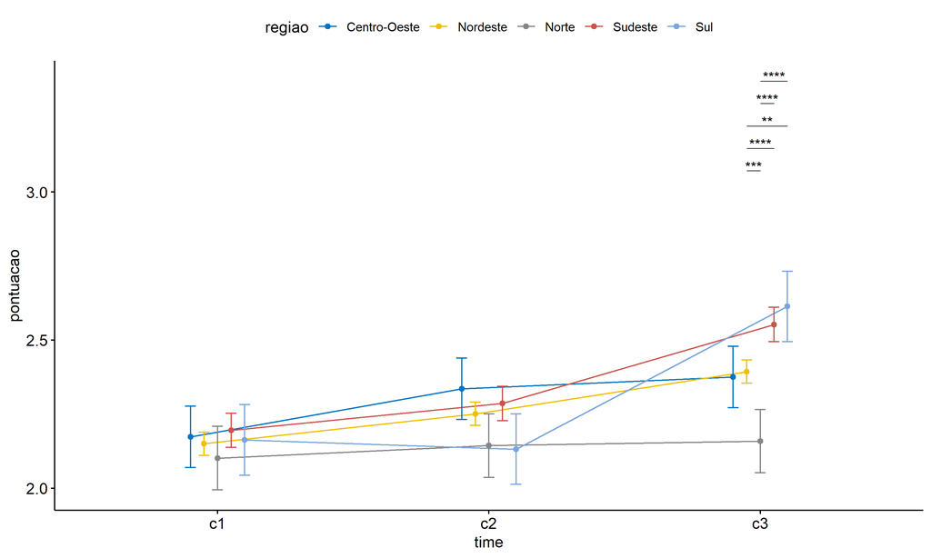

```r
pwc <- add_xy_position(pwc, x = "time", fun = "mean_se", dodge = 0.25)
pd <- position_dodge(width = 0.25)
ggline(emms, x = "time", y = "emmean", color = "regiao",
       palette = c("#0073C2FF","#EFC000FF","#868686FF","#CD534CFF","#7AA6DCFF"),
       position = pd, ylab = "pontuacao") +
  geom_errorbar(aes(ymin = conf.low, ymax = conf.high, color = regiao),
                position = pd, width = 0.2) +
  stat_pvalue_manual(pwc, hide.ns = T, tip.length = F, linetype = 1)
```

```r
(pwc <- ldat %>% group_by(regiao) %>%
    emmeans_test(pontuacao ~ time, detailed = T, p.adjust.method = "bonferroni"))
```

```
## # A tibble: 15 × 15
##    regiao term  .y.   group1 group2 null.value estimate     se    df conf.low conf.high statistic        p    p.adj p.adj.signif
##  * <fct>  <chr> <chr> <chr>  <chr>       <dbl>    <dbl>  <dbl> <dbl>    <dbl>     <dbl>     <dbl>    <dbl>    <dbl> <chr>
##  1 Centr… time  pont… c1     c2              0  -0.162  0.0747  8304   -0.308  -0.0156     -2.17  3.01e- 2 9.02e- 2 ns
##  2 Centr… time  pont… c1     c3              0  -0.201  0.0747  8304   -0.348  -0.0550     -2.70  7.02e- 3 2.11e- 2 *
##  3 Centr… time  pont… c2     c3              0  -0.0394 0.0747  8304   -0.186   0.107      -0.527 5.98e- 1 1   e+ 0 ns
##  4 Norde… time  pont… c1     c2              0  -0.101  0.0284  8304   -0.157  -0.0454     -3.56  3.69e- 4 1.11e- 3 **
##  5 Norde… time  pont… c1     c3              0  -0.243  0.0284  8304   -0.299  -0.188      -8.59  1.04e-17 3.13e-17 ****
##  6 Norde… time  pont… c2     c3              0  -0.142  0.0284  8304   -0.198  -0.0869     -5.03  5.13e- 7 1.54e- 6 ****
##  7 Norte  time  pont… c1     c2              0  -0.0421 0.0772  8304   -0.193   0.109      -0.545 5.86e- 1 1   e+ 0 ns
##  8 Norte  time  pont… c1     c3              0  -0.0569 0.0772  8304   -0.208   0.0945     -0.737 4.61e- 1 1   e+ 0 ns
##  9 Norte  time  pont… c2     c3              0  -0.0149 0.0772  8304   -0.166   0.137      -0.192 8.48e- 1 1   e+ 0 ns
## 10 Sudes… time  pont… c1     c2              0  -0.0908 0.0417  8304   -0.173  -0.00905    -2.18  2.95e- 2 8.85e- 2 ns
## 11 Sudes… time  pont… c1     c3              0  -0.358  0.0417  8304   -0.439  -0.276      -8.57  1.18e-17 3.55e-17 ****
## 12 Sudes… time  pont… c2     c3              0  -0.267  0.0417  8304   -0.348  -0.185      -6.40  1.68e-10 5.03e-10 ****
## 13 Sul    time  pont… c1     c2              0   0.0307 0.0860  8304   -0.138   0.199       0.357 7.21e- 1 1   e+ 0 ns
## 14 Sul    time  pont… c1     c3              0  -0.451  0.0860  8304   -0.619  -0.282      -5.24  1.61e- 7 4.82e- 7 ****
## 15 Sul    time  pont… c2     c3              0  -0.482  0.0860  8304   -0.650  -0.313      -5.60  2.20e- 8 6.59e- 8 ****
```

| regiao | term | .y. | group1 | group2 | null.value | estimate | se | df | conf.low | conf.high | statistic | p | p.adj | p.adj.signif |
| --- | --- | --- | --- | --- | --- | --- | --- | --- | --- | --- | --- | --- | --- | --- |
| Centro-Oeste | time | pontuacao | c1 | c2 | 0 | -0.162 | 0.075 | 8304 | -0.308 | -0.016 | -2.169 | 0.030 | 0.090 | ns |
| Centro-Oeste | time | pontuacao | c1 | c3 | 0 | -0.201 | 0.075 | 8304 | -0.348 | -0.055 | -2.696 | 0.007 | 0.021 | * |
| Centro-Oeste | time | pontuacao | c2 | c3 | 0 | -0.039 | 0.075 | 8304 | -0.186 | 0.107 | -0.527 | 0.598 | 1.000 | ns |
| Nordeste | time | pontuacao | c1 | c2 | 0 | -0.101 | 0.028 | 8304 | -0.157 | -0.045 | -3.563 | 0.000 | 0.001 | ** |
| Nordeste | time | pontuacao | c1 | c3 | 0 | -0.243 | 0.028 | 8304 | -0.299 | -0.188 | -8.588 | 0.000 | 0.000 | **** |
| Nordeste | time | pontuacao | c2 | c3 | 0 | -0.142 | 0.028 | 8304 | -0.198 | -0.087 | -5.026 | 0.000 | 0.000 | **** |
| Norte | time | pontuacao | c1 | c2 | 0 | -0.042 | 0.077 | 8304 | -0.193 | 0.109 | -0.545 | 0.586 | 1.000 | ns |
| Norte | time | pontuacao | c1 | c3 | 0 | -0.057 | 0.077 | 8304 | -0.208 | 0.094 | -0.737 | 0.461 | 1.000 | ns |
| Norte | time | pontuacao | c2 | c3 | 0 | -0.015 | 0.077 | 8304 | -0.166 | 0.137 | -0.192 | 0.848 | 1.000 | ns |
| Sudeste | time | pontuacao | c1 | c2 | 0 | -0.091 | 0.042 | 8304 | -0.173 | -0.009 | -2.177 | 0.029 | 0.088 | ns |
| Sudeste | time | pontuacao | c1 | c3 | 0 | -0.358 | 0.042 | 8304 | -0.439 | -0.276 | -8.574 | 0.000 | 0.000 | **** |
| Sudeste | time | pontuacao | c2 | c3 | 0 | -0.267 | 0.042 | 8304 | -0.348 | -0.185 | -6.396 | 0.000 | 0.000 | **** |
| Sul | time | pontuacao | c1 | c2 | 0 | 0.031 | 0.086 | 8304 | -0.138 | 0.199 | 0.357 | 0.721 | 1.000 | ns |
| Sul | time | pontuacao | c1 | c3 | 0 | -0.451 | 0.086 | 8304 | -0.619 | -0.282 | -5.245 | 0.000 | 0.000 | **** |
| Sul | time | pontuacao | c2 | c3 | 0 | -0.482 | 0.086 | 8304 | -0.650 | -0.313 | -5.601 | 0.000 | 0.000 | **** |

```r
(emms <- get_emmeans(pwc))
```

```
## # A tibble: 15 × 8
##    regiao       time  emmean     se    df conf.low conf.high method
##    <fct>        <fct>  <dbl>  <dbl> <dbl>    <dbl>     <dbl> <chr>
##  1 Centro-Oeste c1      2.17 0.0528  8304     2.07      2.28 Emmeans test
##  2 Centro-Oeste c2      2.34 0.0528  8304     2.23      2.44 Emmeans test
##  3 Centro-Oeste c3      2.38 0.0528  8304     2.27      2.48 Emmeans test
##  4 Nordeste     c1      2.15 0.0200  8304     2.11      2.19 Emmeans test
##  5 Nordeste     c2      2.25 0.0200  8304     2.21      2.29 Emmeans test
##  6 Nordeste     c3      2.39 0.0200  8304     2.35      2.43 Emmeans test
##  7 Norte        c1      2.10 0.0546  8304     1.99      2.21 Emmeans test
##  8 Norte        c2      2.14 0.0546  8304     2.04      2.25 Emmeans test
##  9 Norte        c3      2.16 0.0546  8304     2.05      2.27 Emmeans test
## 10 Sudeste      c1      2.20 0.0295  8304     2.14      2.25 Emmeans test
## 11 Sudeste      c2      2.29 0.0295  8304     2.23      2.34 Emmeans test
## 12 Sudeste      c3      2.55 0.0295  8304     2.49      2.61 Emmeans test
## 13 Sul          c1      2.16 0.0608  8304     2.04      2.28 Emmeans test
## 14 Sul          c2      2.13 0.0608  8304     2.01      2.25 Emmeans test
## 15 Sul          c3      2.61 0.0608  8304     2.49      2.73 Emmeans test
```

| regiao | time | emmean | se | df | conf.low | conf.high | method |
| --- | --- | --- | --- | --- | --- | --- | --- |
| Centro-Oeste | c1 | 2.174 | 0.053 | 8304 | 2.070 | 2.277 | Emmeans test |
| Centro-Oeste | c2 | 2.336 | 0.053 | 8304 | 2.232 | 2.439 | Emmeans test |
| Centro-Oeste | c3 | 2.375 | 0.053 | 8304 | 2.271 | 2.479 | Emmeans test |
| Nordeste | c1 | 2.150 | 0.020 | 8304 | 2.111 | 2.189 | Emmeans test |
| Nordeste | c2 | 2.251 | 0.020 | 8304 | 2.212 | 2.290 | Emmeans test |
| Nordeste | c3 | 2.394 | 0.020 | 8304 | 2.354 | 2.433 | Emmeans test |
| Norte | c1 | 2.101 | 0.055 | 8304 | 1.994 | 2.209 | Emmeans test |
| Norte | c2 | 2.144 | 0.055 | 8304 | 2.037 | 2.251 | Emmeans test |
| Norte | c3 | 2.158 | 0.055 | 8304 | 2.051 | 2.265 | Emmeans test |
| Sudeste | c1 | 2.195 | 0.029 | 8304 | 2.137 | 2.253 | Emmeans test |
| Sudeste | c2 | 2.286 | 0.029 | 8304 | 2.228 | 2.344 | Emmeans test |
| Sudeste | c3 | 2.553 | 0.029 | 8304 | 2.495 | 2.610 | Emmeans test |
| Sul | c1 | 2.163 | 0.061 | 8304 | 2.043 | 2.282 | Emmeans test |
| Sul | c2 | 2.132 | 0.061 | 8304 | 2.013 | 2.251 | Emmeans test |
| Sul | c3 | 2.613 | 0.061 | 8304 | 2.494 | 2.733 | Emmeans test |

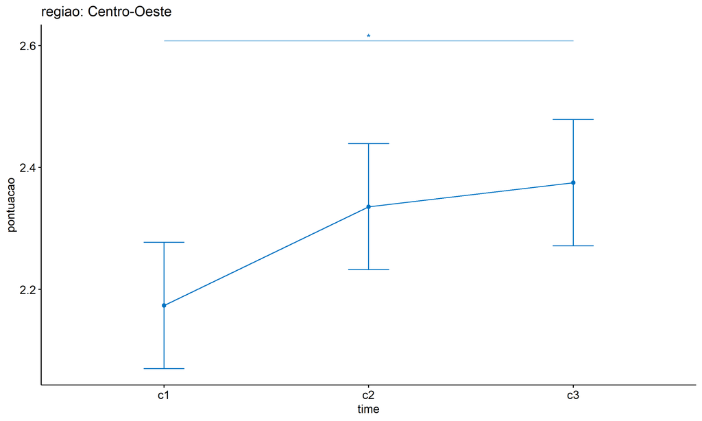

```r
emms.gg <- emms[which(emms$regiao == "Centro-Oeste"),]
if (nrow(emms.gg) > 0)
  ggline(emms.gg, x = "time", y = "emmean", color = "#0073C2FF", ylab = "pontuacao") +
    geom_errorbar(aes(ymin = conf.low, ymax = conf.high),
                  width = 0.2, color = "#0073C2FF") +
    stat_pvalue_manual(
      add_xy_position(pwc[which(pwc$regiao == "Centro-Oeste"),],
                      x = "time", fun = "mean_se"),
      hide.ns = T, color = "#0073C2FF", tip.length = F) +
    labs(title = "regiao: Centro-Oeste")+
    theme(legend.text = element_blank())
```

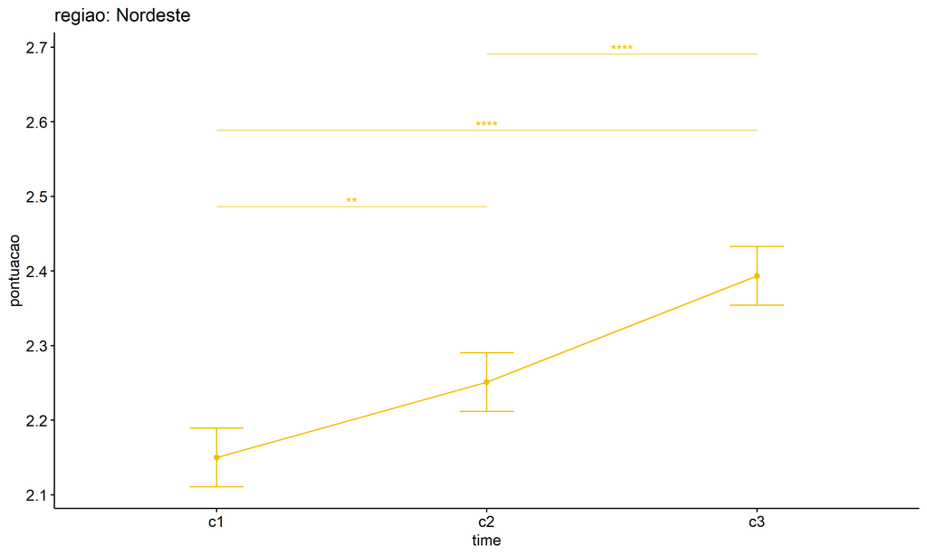

```r
emms.gg <- emms[which(emms$regiao == "Nordeste"),]
if (nrow(emms.gg) > 0)
  ggline(emms.gg, x = "time", y = "emmean", color = "#EFC000FF", ylab = "pontuacao") +
    geom_errorbar(aes(ymin = conf.low, ymax = conf.high),
                  width = 0.2, color = "#EFC000FF") +
    stat_pvalue_manual(
      add_xy_position(pwc[which(pwc$regiao == "Nordeste"),],
                      x = "time", fun = "mean_se"),
      hide.ns = T, color = "#EFC000FF", tip.length = F) +
    labs(title = "regiao: Nordeste")+
    theme(legend.text = element_blank())
```

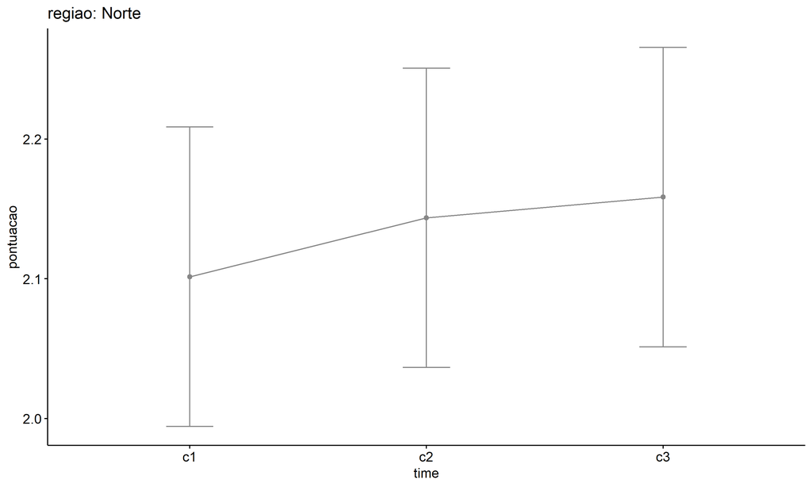

```r
emms.gg <- emms[which(emms$regiao == "Norte"),]
if (nrow(emms.gg) > 0)
  ggline(emms.gg, x = "time", y = "emmean", color = "#868686FF", ylab = "pontuacao") +
    geom_errorbar(aes(ymin = conf.low, ymax = conf.high),
                  width = 0.2, color = "#868686FF") +
    stat_pvalue_manual(
      add_xy_position(pwc[which(pwc$regiao == "Norte"),],
                      x = "time", fun = "mean_se"),
      hide.ns = T, color = "#868686FF", tip.length = F) +
    labs(title = "regiao: Norte")+
    theme(legend.text = element_blank())
```

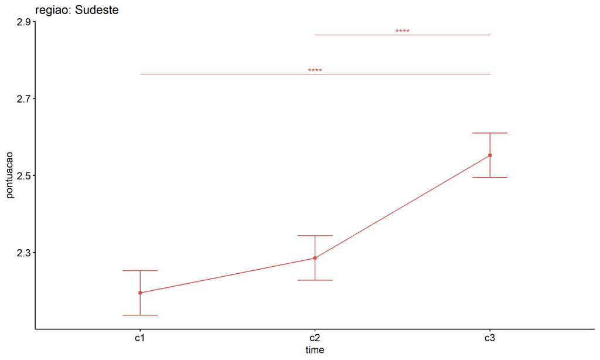

```r
emms.gg <- emms[which(emms$regiao == "Sudeste"),]
if (nrow(emms.gg) > 0)
  ggline(emms.gg, x = "time", y = "emmean", color = "#CD534CFF", ylab = "pontuacao") +
    geom_errorbar(aes(ymin = conf.low, ymax = conf.high),
                  width = 0.2, color = "#CD534CFF") +
    stat_pvalue_manual(
      add_xy_position(pwc[which(pwc$regiao == "Sudeste"),],
                      x = "time", fun = "mean_se"),
      hide.ns = T, color = "#CD534CFF", tip.length = F) +
    labs(title = "regiao: Sudeste")+
    theme(legend.text = element_blank())
```

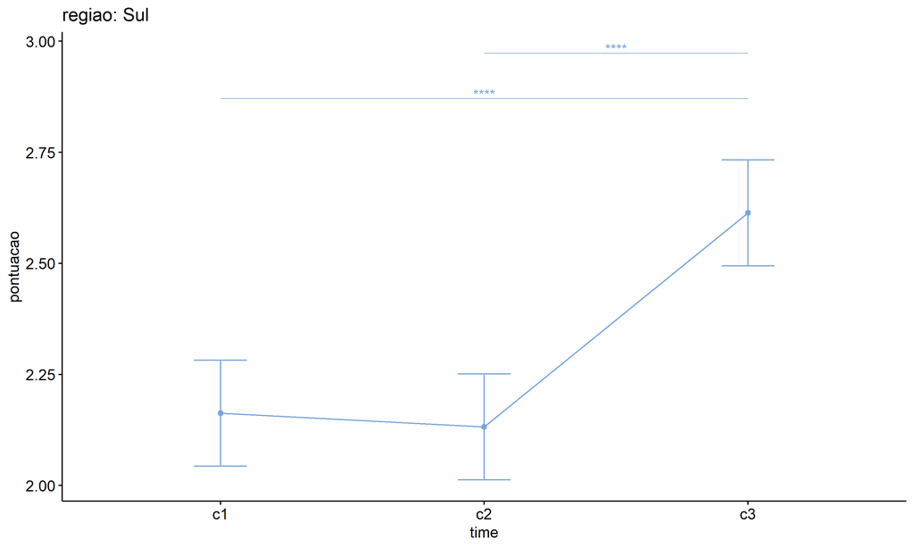

```r
emms.gg <- emms[which(emms$regiao == "Sul"),]
if (nrow(emms.gg) > 0)
  ggline(emms.gg, x = "time", y = "emmean", color = "#7AA6DCFF", ylab = "pontuacao") +
    geom_errorbar(aes(ymin = conf.low, ymax = conf.high),
                  width = 0.2, color = "#7AA6DCFF") +
    stat_pvalue_manual(
      add_xy_position(pwc[which(pwc$regiao == "Sul"),],
                      x = "time", fun = "mean_se"),
      hide.ns = T, color = "#7AA6DCFF", tip.length = F) +
    labs(title = "regiao: Sul")+
    theme(legend.text = element_blank())
```

## PairWise Computation after removing non.normal data

```r
if (length(non.ids) > 0)
  (pwc2 <- ldat2 %>% group_by(time) %>%
     emmeans_test(pontuacao ~ regiao, detailed = T, p.adjust.method = "bonferroni"))
```

```r
if (length(non.ids) > 0)
  (emms2 <- get_emmeans(pwc2))
```

```r
if (length(non.ids) > 0) {
  pwc2 <- add_xy_position(pwc2, x = "time", fun = "mean_se", dodge = 0.25)
  pd2 <- position_dodge(width = 0.25)

  ggline(emms2, x = "time", y = "emmean", color = "regiao",
         palette = c("#0073C2FF","#EFC000FF","#868686FF","#CD534CFF","#7AA6DCFF"),
         position = pd, ylab = "pontuacao") +
    geom_errorbar(aes(ymin = conf.low, ymax = conf.high, color = regiao),
                position = pd, width = 0.2) +
    stat_pvalue_manual(pwc2, hide.ns = T, tip.length = F, linetype = 1)
}
```

```r
if (length(non.ids) > 0)
  (pwc2 <- ldat2 %>% group_by(regiao) %>%
     emmeans_test(pontuacao ~ time, detailed = T, p.adjust.method = "bonferroni"))
```

```r
if (length(non.ids) > 0)
  (emms2 <- get_emmeans(pwc2))
```

```r
if (length(non.ids) > 0) {
  emms.gg <- emms2[which(emms2$regiao == "Centro-Oeste"),]
  if (nrow(emms.gg) > 0)
    ggline(emms.gg, x = "time", y = "emmean", color = "#0073C2FF", ylab = "pontuacao") +
    geom_errorbar(aes(ymin = conf.low, ymax = conf.high),
                  width = 0.2, color = "#0073C2FF") +
    stat_pvalue_manual(
      add_xy_position(pwc[which(pwc$regiao == "Centro-Oeste"),],
                      x = "time", fun = "mean_se"),
      hide.ns = T, color = "#0073C2FF", tip.length = F) +
    labs(title = "regiao: Centro-Oeste") +
    theme(legend.text = element_blank())
}
```

```r
if (length(non.ids) > 0) {
  emms.gg <- emms2[which(emms2$regiao == "Nordeste"),]
  if (nrow(emms.gg) > 0)
    ggline(emms.gg, x = "time", y = "emmean", color = "#EFC000FF", ylab = "pontuacao") +
    geom_errorbar(aes(ymin = conf.low, ymax = conf.high),
                  width = 0.2, color = "#EFC000FF") +
    stat_pvalue_manual(
      add_xy_position(pwc[which(pwc$regiao == "Nordeste"),],
                      x = "time", fun = "mean_se"),
      hide.ns = T, color = "#EFC000FF", tip.length = F) +
    labs(title = "regiao: Nordeste") +
    theme(legend.text = element_blank())
}
```

```r
if (length(non.ids) > 0) {
  emms.gg <- emms2[which(emms2$regiao == "Norte"),]
  if (nrow(emms.gg) > 0)
    ggline(emms.gg, x = "time", y = "emmean", color = "#868686FF", ylab = "pontuacao") +
    geom_errorbar(aes(ymin = conf.low, ymax = conf.high),
                  width = 0.2, color = "#868686FF") +
    stat_pvalue_manual(
      add_xy_position(pwc[which(pwc$regiao == "Norte"),],
                      x = "time", fun = "mean_se"),
      hide.ns = T, color = "#868686FF", tip.length = F) +
    labs(title = "regiao: Norte") +
    theme(legend.text = element_blank())
}
```

```r
if (length(non.ids) > 0) {
  emms.gg <- emms2[which(emms2$regiao == "Sudeste"),]
  if (nrow(emms.gg) > 0)
    ggline(emms.gg, x = "time", y = "emmean", color = "#CD534CFF", ylab = "pontuacao") +
    geom_errorbar(aes(ymin = conf.low, ymax = conf.high),
                  width = 0.2, color = "#CD534CFF") +
    stat_pvalue_manual(
      add_xy_position(pwc[which(pwc$regiao == "Sudeste"),],
                      x = "time", fun = "mean_se"),
      hide.ns = T, color = "#CD534CFF", tip.length = F) +
    labs(title = "regiao: Sudeste") +
    theme(legend.text = element_blank())
}
```

```r
if (length(non.ids) > 0) {
  emms.gg <- emms2[which(emms2$regiao == "Sul"),]
  if (nrow(emms.gg) > 0)
    ggline(emms.gg, x = "time", y = "emmean", color = "#7AA6DCFF", ylab = "pontuacao") +
    geom_errorbar(aes(ymin = conf.low, ymax = conf.high),
                  width = 0.2, color = "#7AA6DCFF") +
    stat_pvalue_manual(
      add_xy_position(pwc[which(pwc$regiao == "Sul"),],
                      x = "time", fun = "mean_se"),
      hide.ns = T, color = "#7AA6DCFF", tip.length = F) +
    labs(title = "regiao: Sul") +
    theme(legend.text = element_blank())
}
```

# ANOVA: pontuacao ~ time*porte + Error(id/time)

## Data Preparation

```r
data <- edat[,c("aluno_id","porte","ciclo","pontuacao")]
data <- data[data$ciclo %in% c("Primeiro Ciclo","Segundo Ciclo","Terceiro Ciclo"),]
data$ciclo <- factor(data$ciclo, c("Primeiro Ciclo","Segundo Ciclo","Terceiro Ciclo"))
data <- unique(data)

wdat <- spread(data, ciclo, pontuacao)
wdat <- wdat[complete.cases(wdat),]
colnames(wdat) <- c("id","porte","c1","c2","c3")

ldat <- gather(wdat, key = time, value = pontuacao, c1,c2,c3) %>%
  convert_as_factor(id, time)
ldat <- remove_group_data(ldat, "pontuacao", c("time", "porte"), n.limit = 30)
ldat$porte <- factor(ldat$porte, sort(unique(ldat$porte)))
```

### Check assumptions: Identifying Outliers

```r
outliers <- identify_outliers(group_by(ldat, time, porte), pontuacao)
(outliers <- outliers[outliers$is.extreme == T,])
```

```
## # A tibble: 1,025 × 6
##    porte                              time  id                   pontuacao is.outlier is.extreme
##    <fct>                              <fct> <fct>                    <dbl> <lgl>      <lgl>
##  1 Até 50 matrículas de escolarização c1    0w3VhiMf67CbcpR6aZCL       5   TRUE       TRUE
##  2 Até 50 matrículas de escolarização c1    6N2ACmyrqNBgfOvicubH       3.5 TRUE       TRUE
##  3 Até 50 matrículas de escolarização c1    CCkKOhn0UVSkJHbSjgzS       5   TRUE       TRUE
##  4 Até 50 matrículas de escolarização c1    CnDHyGy00t97Hh8JGKqg       3.5 TRUE       TRUE
##  5 Até 50 matrículas de escolarização c1    gZXmphJ8jrUySX3i0ORd       3.5 TRUE       TRUE
##  6 Até 50 matrículas de escolarização c1    iutpBZMAtM92qcbyCDHB       3.5 TRUE       TRUE
##  7 Até 50 matrículas de escolarização c1    ShlGdXTxjxY5elm8BIsc       3.5 TRUE       TRUE
##  8 Até 50 matrículas de escolarização c1    xAo0TzCEx1bIrmjqKgbj       3.5 TRUE       TRUE
##  9 Até 50 matrículas de escolarização c1    xF20f9CYWcEP8kspJSfO       3.5 TRUE       TRUE
## 10 Até 50 matrículas de escolarização c1    zpmhcXzEeOxKL6kXYe02       3.5 TRUE       TRUE
## # ℹ 1,015 more rows
```

| porte | time | id | pontuacao | is.outlier | is.extreme |
| --- | --- | --- | --- | --- | --- |
| Até 50 matrículas de escolarização | c1 | 0w3VhiMf67CbcpR6aZCL | 5.000 | TRUE | TRUE |
| Até 50 matrículas de escolarização | c1 | 6N2ACmyrqNBgfOvicubH | 3.500 | TRUE | TRUE |
| Até 50 matrículas de escolarização | c1 | CCkKOhn0UVSkJHbSjgzS | 5.000 | TRUE | TRUE |
| Até 50 matrículas de escolarização | c1 | CnDHyGy00t97Hh8JGKqg | 3.500 | TRUE | TRUE |
| Até 50 matrículas de escolarização | c1 | gZXmphJ8jrUySX3i0ORd | 3.500 | TRUE | TRUE |
| Até 50 matrículas de escolarização | c1 | iutpBZMAtM92qcbyCDHB | 3.500 | TRUE | TRUE |
| Até 50 matrículas de escolarização | c1 | ShlGdXTxjxY5elm8BIsc | 3.500 | TRUE | TRUE |
| Até 50 matrículas de escolarização | c1 | xAo0TzCEx1bIrmjqKgbj | 3.500 | TRUE | TRUE |
| Até 50 matrículas de escolarização | c1 | xF20f9CYWcEP8kspJSfO | 3.500 | TRUE | TRUE |
| Até 50 matrículas de escolarização | c1 | zpmhcXzEeOxKL6kXYe02 | 3.500 | TRUE | TRUE |
| Entre 201 e 500 matrículas de escolarização | c1 | 0OzfHdzDSzAB1syzSzb8 | 5.000 | TRUE | TRUE |
| Entre 201 e 500 matrículas de escolarização | c1 | 0snZiNyJSvQ3y78pNyZ8 | 5.000 | TRUE | TRUE |
| Entre 201 e 500 matrículas de escolarização | c1 | 0wDHSyctDDkjP6OPE3c8 | 5.000 | TRUE | TRUE |
| Entre 201 e 500 matrículas de escolarização | c1 | 1j6UeRYoeJDXM0grwZCJ | 3.500 | TRUE | TRUE |
| Entre 201 e 500 matrículas de escolarização | c1 | 2l9eL5QVtUNWf7HSZPbv | 3.500 | TRUE | TRUE |
| Entre 201 e 500 matrículas de escolarização | c1 | 3roHN14ps3mqIKTOGrvj | 3.000 | TRUE | TRUE |
| Entre 201 e 500 matrículas de escolarização | c1 | 42WvKYOHdVI1hIxd9ZJl | 4.000 | TRUE | TRUE |
| Entre 201 e 500 matrículas de escolarização | c1 | 46nUNvt4sDOPsC9jnkiG | 4.500 | TRUE | TRUE |
| Entre 201 e 500 matrículas de escolarização | c1 | 4hmXg2uo4wxSAX9SaxpN | 3.500 | TRUE | TRUE |
| Entre 201 e 500 matrículas de escolarização | c1 | 55GlwifTTyiOSKTB9vc9 | 5.000 | TRUE | TRUE |
| Entre 201 e 500 matrículas de escolarização | c1 | 5AeP0IQ84CerIQVenp2G | 3.000 | TRUE | TRUE |
| Entre 201 e 500 matrículas de escolarização | c1 | 5feCOxk9AidRBPnsBHCE | 5.000 | TRUE | TRUE |
| Entre 201 e 500 matrículas de escolarização | c1 | 5zZ1GeniMVX6uMy5Wsj5 | 4.500 | TRUE | TRUE |
| Entre 201 e 500 matrículas de escolarização | c1 | 6IoOZmGw52LYlznSYXzK | 3.000 | TRUE | TRUE |
| Entre 201 e 500 matrículas de escolarização | c1 | 6Xlhq905iNT5kvJFoSW5 | 5.000 | TRUE | TRUE |
| Entre 201 e 500 matrículas de escolarização | c1 | 7AaMrLZQiyhSoBaer5VH | 3.500 | TRUE | TRUE |
| Entre 201 e 500 matrículas de escolarização | c1 | 7nfO1ouMUuN7IzvlCKr0 | 3.500 | TRUE | TRUE |
| Entre 201 e 500 matrículas de escolarização | c1 | A5EETpEr617bpnSh1wp6 | 3.500 | TRUE | TRUE |
| Entre 201 e 500 matrículas de escolarização | c1 | A5zmrPXJaIUaT9ZimRSl | 3.500 | TRUE | TRUE |
| Entre 201 e 500 matrículas de escolarização | c1 | AIzwxJCfbDsO8ZT4ZZ4h | 3.000 | TRUE | TRUE |

[output cut: 995 more lines]

### Check assumptions: Normality Test

```r
(normality.df <- normality.test.per.groups(ldat, "pontuacao", c("time", "porte")))
```

```
##          var  variable time                                        porte    n skewness   kurtosis symmetry  statistic
## 1  pontuacao pontuacao   c1           Até 50 matrículas de escolarização   83 0.000000  0.0000000 few data         NA
## 2  pontuacao pontuacao   c1  Entre 201 e 500 matrículas de escolarização 1529 3.932727 15.0500066       NO 1240.26367
## 3  pontuacao pontuacao   c1 Entre 501 e 1000 matrículas de escolarização  618 4.164674 17.2574293       NO  549.24526
## 4  pontuacao pontuacao   c1   Entre 51 e 200 matrículas de escolarização  473 3.211507  9.3130199       NO  331.95169
## 5  pontuacao pontuacao   c1     Mais de 1000 matrículas de escolarização   70 0.000000  0.0000000 few data         NA
## 6  pontuacao pontuacao   c2           Até 50 matrículas de escolarização   83 3.303964 10.3038434       NO   82.95479
## 7  pontuacao pontuacao   c2  Entre 201 e 500 matrículas de escolarização 1529 3.001561  7.8424484       NO  941.73929
## 8  pontuacao pontuacao   c2 Entre 501 e 1000 matrículas de escolarização  618 2.637900  5.4973220       NO  337.51805
## 9  pontuacao pontuacao   c2   Entre 51 e 200 matrículas de escolarização  473 3.260617  9.0966338       NO  334.14585
## 10 pontuacao pontuacao   c2     Mais de 1000 matrículas de escolarização   70 0.000000  0.0000000 few data         NA
## 11 pontuacao pontuacao   c3           Até 50 matrículas de escolarização   83 1.184027 -0.4826471       NO   16.46817
## 12 pontuacao pontuacao   c3  Entre 201 e 500 matrículas de escolarização 1529 2.057343  2.6705602       NO  574.09473
## 13 pontuacao pontuacao   c3 Entre 501 e 1000 matrículas de escolarização  618 1.811558  1.5419434       NO  193.09287
## 14 pontuacao pontuacao   c3   Entre 51 e 200 matrículas de escolarização  473 2.225785  3.2503959       NO  207.62236
```

[output cut: 17 more lines]

| var | variable | time | porte | n | skewness | kurtosis | symmetry | statistic | method | p | p.signif | normality |
| --- | --- | --- | --- | --- | --- | --- | --- | --- | --- | --- | --- | --- |
| pontuacao | pontuacao | c1 | Até 50 matrículas de escolarização | 83 | 0.000 | 0.000 | few data | NA | NA | 1 | NA | NO |
| pontuacao | pontuacao | c1 | Entre 201 e 500 matrículas de escolarização | 1529 | 3.933 | 15.050 | NO | 1240.264 | D’Agostino | 0 | **** | - |
| pontuacao | pontuacao | c1 | Entre 501 e 1000 matrículas de escolarização | 618 | 4.165 | 17.257 | NO | 549.245 | D’Agostino | 0 | **** | - |
| pontuacao | pontuacao | c1 | Entre 51 e 200 matrículas de escolarização | 473 | 3.212 | 9.313 | NO | 331.952 | D’Agostino | 0 | **** | - |
| pontuacao | pontuacao | c1 | Mais de 1000 matrículas de escolarização | 70 | 0.000 | 0.000 | few data | NA | NA | 1 | NA | NO |
| pontuacao | pontuacao | c2 | Até 50 matrículas de escolarização | 83 | 3.304 | 10.304 | NO | 82.955 | D’Agostino | 0 | **** | NO |
| pontuacao | pontuacao | c2 | Entre 201 e 500 matrículas de escolarização | 1529 | 3.002 | 7.842 | NO | 941.739 | D’Agostino | 0 | **** | - |
| pontuacao | pontuacao | c2 | Entre 501 e 1000 matrículas de escolarização | 618 | 2.638 | 5.497 | NO | 337.518 | D’Agostino | 0 | **** | - |
| pontuacao | pontuacao | c2 | Entre 51 e 200 matrículas de escolarização | 473 | 3.261 | 9.097 | NO | 334.146 | D’Agostino | 0 | **** | - |
| pontuacao | pontuacao | c2 | Mais de 1000 matrículas de escolarização | 70 | 0.000 | 0.000 | few data | NA | NA | 1 | NA | NO |
| pontuacao | pontuacao | c3 | Até 50 matrículas de escolarização | 83 | 1.184 | -0.483 | NO | 16.468 | D’Agostino | 0 | *** | NO |
| pontuacao | pontuacao | c3 | Entre 201 e 500 matrículas de escolarização | 1529 | 2.057 | 2.671 | NO | 574.095 | D’Agostino | 0 | **** | - |
| pontuacao | pontuacao | c3 | Entre 501 e 1000 matrículas de escolarização | 618 | 1.812 | 1.542 | NO | 193.093 | D’Agostino | 0 | **** | - |
| pontuacao | pontuacao | c3 | Entre 51 e 200 matrículas de escolarização | 473 | 2.226 | 3.250 | NO | 207.622 | D’Agostino | 0 | **** | - |
| pontuacao | pontuacao | c3 | Mais de 1000 matrículas de escolarização | 70 | 1.828 | 1.589 | NO | 30.995 | D’Agostino | 0 | **** | NO |

```r
(non.ids <- unique(do.call(
  c, lapply(which(normality.df$normality == 'NO'), FUN = function(i) {
  idx = which(ldat$time == normality.df$time[i] &
                ldat$porte == normality.df$porte[i])
  getNonNormal(ldat$"pontuacao"[idx], ldat$id[idx])
}))))
```

```
##  [1] "0w3VhiMf67CbcpR6aZCL" "1ZE6i0Is22PBIAZbrM0J" "nFCWCX4KlAfWmHKc43rd" "ShlGdXTxjxY5elm8BIsc" "0bDRQAUpq62jJm9vcptp"
##  [6] "1D0FkPiZPusHHIh6zphq" "4UfSIGPhZwMEmoRWzMbI" "4wF2BE9B6wMnsfueM9hc" "6Mt8Oh7bYeXEkrmnaFAx" "6N2ACmyrqNBgfOvicubH"
## [11] "7e17sU1jHAY3gBDyza9l" "7gsjMtGuUxQPUSVFnNcm" "7kzLr5BSKvlLa1ADxTNX" "8QJX5P6FygYXzjqA5njF" "8qKHWcxVACuKJJSMclyf"
## [16] "9iM0tfJZQsgqnYHtfFf0" "ADdqL4oAf1WRDDiOJwkj" "aONYcyIz9jdWo9UGBKG0" "BFW9EcP6GxS4r3JYDkkn" "CqVZ3Xy9b3ZuT26PuLpa"
## [21] "d7fkDImOtMuiednMD3E1" "dESFdovgEOeqMIXSwXsu" "DZ99GflNBKeztsmqzhAZ" "ewKlsdM2p1FOYevFZJEB" "gZXmphJ8jrUySX3i0ORd"
## [26] "HAmR7jtNTKSPCYAtjMLv" "yersdkzgN1t3oO7zNNNA" "hhm3dmBw9wzrZNM837xU" "hOmouhZRJ53dvfn3tBsJ" "hPDFOwmBzlak2RcrNhzR"
## [31] "xK8qTeI9z4KzyJVqLhM8" "hv8yuaYbgJIx5H3apsBZ" "i84ihNmDZFogrHoxo3Im" "xF20f9CYWcEP8kspJSfO" "jljcKPNPjBo1MdiK1ffQ"
## [36] "KBTZEriJAFvcWw48Xxgc" "KQ1rtmRy9pqPUzdocJHc" "krjfBBPR9DydnBgQSQ1n" "w7548cNc0knlzDezHzBq" "kxdgoHtp7sPis1wwXN9e"
## [41] "Lbwu9s0newf9Wi294FdL" "tgU0kaZP9pRnxah0S6uy" "lddMiu2T00HFwgQ7tqoQ" "LQwlHt8gNJ5CtCYBWgCr" "ltYX0dLBB2brT2djXB5i"
## [46] "MdfO8FPiIZis82vN8Qvn" "QEFho4YwQCAlMwhIddNB" "MISckshDxTeD10V5JEBJ" "PdGP3GVwxljvKeW07xkS" "QlXsQ3d9CVjdZHyW2pLC"
## [51] "Rw0335zUaR2w467v8I7t" "MvrXfUanbVWpI0EsMTR6" "T2uwQcqrdXIilUfr6OCA" "tlnYYlL4uNGaw9gq7z02" "tw7Ctq5qyPE214vFOFjq"
## [56] "U2EyQT1K48KPitv2x16k" "UgYoK4SY4Mtbi2xic7Rv" "mbcncvg5dOFa9ZRsRhZf" "vgyELVyPKZx09yEhXnEW" "VNQYsv3kH0OTOqJH3yYT"
## [61] "VTCxkwxHV2rNnNTuK4co" "wqLc84Q7Y7B988JtGyXd" "L0gX2yfP95da5eDy6w4E" "xAo0TzCEx1bIrmjqKgbj" "xD1wHpF1gkJCyVbkGGdU"
## [66] "hHdFTd6UEuufNe964mcz" "xLpKyTYqyZhy4OOTSCAv" "xPKsXOtiZGS6KJVc4KT3" "ygCWEOBsngyfEt5hGLmw" "DwTeMtAHL6Xl0Wvt0djz"
## [71] "CCkKOhn0UVSkJHbSjgzS" "z2bvFgOm1tRPAL3buvNQ" "zpmhcXzEeOxKL6kXYe02" "ZHNhk1zpmerLG8ISdloo" "6uO7HtHYJP6LkaXhdG2j"
## [76] "9k9BI8mCq3fddmKjDwxN" "HM6lELrDJUQlU8CLhlxB" "I519hq7xEO1Hoh2ibKjC" "Kb2dP0jiNWmYejxfbhLa" "kxDlIW2yUzDrEogK8TaZ"
## [81] "pqXkPZEqOMf2xM8dbV6d" "sTippTVv5SmFwvxR2sfF" "anmGFIGq40zqZcqOEcal" "hzUS30DyaGMI0MoQIp0n" "sm3UUkWTyL97enxw2JbY"
```

```r
if (length(non.ids) > 0)
  ldat2 <- ldat[!ldat$id %in% non.ids,]
```

### Summary Statistics

```r
(sdat <- ldat %>% group_by(time, porte) %>%
   get_summary_stats(pontuacao, type = "mean_sd"))
```

```
## # A tibble: 15 × 6
##    porte                                        time  variable      n  mean    sd
##    <fct>                                        <fct> <fct>     <dbl> <dbl> <dbl>
##  1 Até 50 matrículas de escolarização           c1    pontuacao    83  2.22 0.626
##  2 Entre 201 e 500 matrículas de escolarização  c1    pontuacao  1529  2.15 0.563
##  3 Entre 501 e 1000 matrículas de escolarização c1    pontuacao   618  2.14 0.533
##  4 Entre 51 e 200 matrículas de escolarização   c1    pontuacao   473  2.21 0.676
##  5 Mais de 1000 matrículas de escolarização     c1    pontuacao    70  2.13 0.556
##  6 Até 50 matrículas de escolarização           c2    pontuacao    83  2.19 0.613
##  7 Entre 201 e 500 matrículas de escolarização  c2    pontuacao  1529  2.24 0.722
##  8 Entre 501 e 1000 matrículas de escolarização c2    pontuacao   618  2.29 0.81
##  9 Entre 51 e 200 matrículas de escolarização   c2    pontuacao   473  2.22 0.728
## 10 Mais de 1000 matrículas de escolarização     c2    pontuacao    70  2.39 0.967
## 11 Até 50 matrículas de escolarização           c3    pontuacao    83  2.71 1.22
## 12 Entre 201 e 500 matrículas de escolarização  c3    pontuacao  1529  2.41 0.925
## 13 Entre 501 e 1000 matrículas de escolarização c3    pontuacao   618  2.48 1.02
## 14 Entre 51 e 200 matrículas de escolarização   c3    pontuacao   473  2.38 0.932
## 15 Mais de 1000 matrículas de escolarização     c3    pontuacao    70  2.46 1.02
```

| porte | time | variable | n | mean | sd |
| --- | --- | --- | --- | --- | --- |
| Até 50 matrículas de escolarização | c1 | pontuacao | 83 | 2.217 | 0.626 |
| Entre 201 e 500 matrículas de escolarização | c1 | pontuacao | 1529 | 2.152 | 0.563 |
| Entre 501 e 1000 matrículas de escolarização | c1 | pontuacao | 618 | 2.138 | 0.533 |
| Entre 51 e 200 matrículas de escolarização | c1 | pontuacao | 473 | 2.212 | 0.676 |
| Mais de 1000 matrículas de escolarização | c1 | pontuacao | 70 | 2.129 | 0.556 |
| Até 50 matrículas de escolarização | c2 | pontuacao | 83 | 2.187 | 0.613 |
| Entre 201 e 500 matrículas de escolarização | c2 | pontuacao | 1529 | 2.243 | 0.722 |
| Entre 501 e 1000 matrículas de escolarização | c2 | pontuacao | 618 | 2.293 | 0.810 |
| Entre 51 e 200 matrículas de escolarização | c2 | pontuacao | 473 | 2.216 | 0.728 |
| Mais de 1000 matrículas de escolarização | c2 | pontuacao | 70 | 2.386 | 0.967 |
| Até 50 matrículas de escolarização | c3 | pontuacao | 83 | 2.711 | 1.223 |
| Entre 201 e 500 matrículas de escolarização | c3 | pontuacao | 1529 | 2.407 | 0.925 |
| Entre 501 e 1000 matrículas de escolarização | c3 | pontuacao | 618 | 2.477 | 1.019 |
| Entre 51 e 200 matrículas de escolarização | c3 | pontuacao | 473 | 2.375 | 0.932 |
| Mais de 1000 matrículas de escolarização | c3 | pontuacao | 70 | 2.464 | 1.023 |

```r
if (length(non.ids) > 0)
  (sdat <- ldat2 %>% group_by(time, porte) %>%
      get_summary_stats(pontuacao, type = "mean_sd"))
```

```
## # A tibble: 15 × 6
##    porte                                        time  variable      n  mean    sd
##    <fct>                                        <fct> <fct>     <dbl> <dbl> <dbl>
##  1 Até 50 matrículas de escolarização           c1    pontuacao     9  2.33 0.661
##  2 Entre 201 e 500 matrículas de escolarização  c1    pontuacao  1529  2.15 0.563
##  3 Entre 501 e 1000 matrículas de escolarização c1    pontuacao   618  2.14 0.533
##  4 Entre 51 e 200 matrículas de escolarização   c1    pontuacao   473  2.21 0.676
##  5 Mais de 1000 matrículas de escolarização     c1    pontuacao    59  2.13 0.577
##  6 Até 50 matrículas de escolarização           c2    pontuacao     9  2    0
##  7 Entre 201 e 500 matrículas de escolarização  c2    pontuacao  1529  2.24 0.722
##  8 Entre 501 e 1000 matrículas de escolarização c2    pontuacao   618  2.29 0.81
##  9 Entre 51 e 200 matrículas de escolarização   c2    pontuacao   473  2.22 0.728
## 10 Mais de 1000 matrículas de escolarização     c2    pontuacao    59  2.27 0.827
## 11 Até 50 matrículas de escolarização           c3    pontuacao     9  3.89 0.894
## 12 Entre 201 e 500 matrículas de escolarização  c3    pontuacao  1529  2.41 0.925
## 13 Entre 501 e 1000 matrículas de escolarização c3    pontuacao   618  2.48 1.02
## 14 Entre 51 e 200 matrículas de escolarização   c3    pontuacao   473  2.38 0.932
## 15 Mais de 1000 matrículas de escolarização     c3    pontuacao    59  2.04 0.233
```

| porte | time | variable | n | mean | sd |
| --- | --- | --- | --- | --- | --- |
| Até 50 matrículas de escolarização | c1 | pontuacao | 9 | 2.333 | 0.661 |
| Entre 201 e 500 matrículas de escolarização | c1 | pontuacao | 1529 | 2.152 | 0.563 |
| Entre 501 e 1000 matrículas de escolarização | c1 | pontuacao | 618 | 2.138 | 0.533 |
| Entre 51 e 200 matrículas de escolarização | c1 | pontuacao | 473 | 2.212 | 0.676 |
| Mais de 1000 matrículas de escolarização | c1 | pontuacao | 59 | 2.127 | 0.577 |
| Até 50 matrículas de escolarização | c2 | pontuacao | 9 | 2.000 | 0.000 |
| Entre 201 e 500 matrículas de escolarização | c2 | pontuacao | 1529 | 2.243 | 0.722 |
| Entre 501 e 1000 matrículas de escolarização | c2 | pontuacao | 618 | 2.293 | 0.810 |
| Entre 51 e 200 matrículas de escolarização | c2 | pontuacao | 473 | 2.216 | 0.728 |
| Mais de 1000 matrículas de escolarização | c2 | pontuacao | 59 | 2.271 | 0.827 |
| Até 50 matrículas de escolarização | c3 | pontuacao | 9 | 3.889 | 0.894 |
| Entre 201 e 500 matrículas de escolarização | c3 | pontuacao | 1529 | 2.407 | 0.925 |
| Entre 501 e 1000 matrículas de escolarização | c3 | pontuacao | 618 | 2.477 | 1.019 |
| Entre 51 e 200 matrículas de escolarização | c3 | pontuacao | 473 | 2.375 | 0.932 |
| Mais de 1000 matrículas de escolarização | c3 | pontuacao | 59 | 2.042 | 0.233 |

## ANOVA Computation

```r
(res.aov <- anova_test(ldat, dv = pontuacao, wid = id, between = porte, within = time))
```

```
## ANOVA Table (type III tests)
##
## $ANOVA
##       Effect DFn  DFd      F                     p p<.05      ges
## 1      porte   4 2768  1.613 0.1680000000000000104       0.000872
## 2       time   2 5536 37.952 0.0000000000000000426     * 0.009000
## 3 porte:time   8 5536  2.462 0.0120000000000000002     * 0.002000
##
## $`Mauchly's Test for Sphericity`
##       Effect     W                                          p p<.05
## 1       time 0.939 0.0000000000000000000000000000000000000201     *
## 2 porte:time 0.939 0.0000000000000000000000000000000000000201     *
##
## $`Sphericity Corrections`
##       Effect   GGe        DF[GG]               p[GG] p[GG]<.05   HFe        DF[HF]                p[HF] p[HF]<.05
## 1       time 0.943 1.89, 5218.64 0.00000000000000029         * 0.943 1.89, 5222.08 0.000000000000000284         *
## 2 porte:time 0.943 7.54, 5218.64 0.01300000000000000         * 0.943 7.55, 5222.08 0.012999999999999999         *
```

| Effect | DFn | DFd | F | p | p<.05 | ges |
| --- | --- | --- | --- | --- | --- | --- |
| porte | 4 | 2768 | 1.613 | 0.168 |  | 0.001 |
| time | 2 | 5536 | 37.952 | 0.000 | * | 0.009 |
| porte:time | 8 | 5536 | 2.462 | 0.012 | * | 0.002 |

| Effect | W | p | p<.05 |
| --- | --- | --- | --- |
| time | 0.939 | 0 | * |
| porte:time | 0.939 | 0 | * |

| Effect | GGe | DF[GG] | p[GG] | p[GG]<.05 | HFe | DF[HF] | p[HF] | p[HF]<.05 |
| --- | --- | --- | --- | --- | --- | --- | --- | --- |
| time | 0.943 | 1.89, 5218.64 | 0.000 | * | 0.943 | 1.89, 5222.08 | 0.000 | * |
| porte:time | 0.943 | 7.54, 5218.64 | 0.013 | * | 0.943 | 7.55, 5222.08 | 0.013 | * |

## ANOVA Computation after removing non.normal data

```r
if (length(non.ids) > 0)
  (res.aov2 <- anova_test(ldat2, dv = pontuacao, wid = id, between = porte , within = time))
```

```
## ANOVA Table (type III tests)
##
## $ANOVA
##       Effect DFn  DFd      F              p p<.05   ges
## 1      porte   4 2683  3.970 0.003000000000     * 0.002
## 2       time   2 5366 21.836 0.000000000359     * 0.005
## 3 porte:time   8 5366  5.574 0.000000471000     * 0.005
##
## $`Mauchly's Test for Sphericity`
##       Effect     W                                     p p<.05
## 1       time 0.946 0.00000000000000000000000000000000929     *
## 2 porte:time 0.946 0.00000000000000000000000000000000929     *
##
## $`Sphericity Corrections`
##       Effect   GGe        DF[GG]          p[GG] p[GG]<.05  HFe       DF[HF]          p[HF] p[HF]<.05
## 1       time 0.949  1.9, 5093.42 0.000000000899         * 0.95 1.9, 5096.93 0.000000000888         *
## 2 porte:time 0.949 7.59, 5093.42 0.000000857000         * 0.95 7.6, 5096.93 0.000000850000         *
```

| Effect | DFn | DFd | F | p | p<.05 | ges |
| --- | --- | --- | --- | --- | --- | --- |
| porte | 4 | 2683 | 3.970 | 0.003 | * | 0.002 |
| time | 2 | 5366 | 21.836 | 0.000 | * | 0.005 |
| porte:time | 8 | 5366 | 5.574 | 0.000 | * | 0.005 |

| Effect | W | p | p<.05 |
| --- | --- | --- | --- |
| time | 0.946 | 0 | * |
| porte:time | 0.946 | 0 | * |

| Effect | GGe | DF[GG] | p[GG] | p[GG]<.05 | HFe | DF[HF] | p[HF] | p[HF]<.05 |
| --- | --- | --- | --- | --- | --- | --- | --- | --- |
| time | 0.949 | 1.9, 5093.42 | 0 | * | 0.95 | 1.9, 5096.93 | 0 | * |
| porte:time | 0.949 | 7.59, 5093.42 | 0 | * | 0.95 | 7.6, 5096.93 | 0 | * |

## PairWise Computation

```r
(pwc <- ldat %>% group_by(time) %>%
   emmeans_test(pontuacao ~ porte, detailed = T, p.adjust.method = "bonferroni"))
```

```
## # A tibble: 30 × 15
##    time  term  .y.       group1    group2 null.value estimate     se    df conf.low conf.high statistic     p p.adj p.adj.signif
##  * <fct> <chr> <chr>     <chr>     <chr>       <dbl>    <dbl>  <dbl> <dbl>    <dbl>     <dbl>     <dbl> <dbl> <dbl> <chr>
##  1 c1    porte pontuacao Até 50 m… Entre…          0  0.0650  0.0877  8304  -0.107     0.237     0.741  0.459     1 ns
##  2 c1    porte pontuacao Até 50 m… Entre…          0  0.0793  0.0910  8304  -0.0990    0.258     0.872  0.383     1 ns
##  3 c1    porte pontuacao Até 50 m… Entre…          0  0.00439 0.0926  8304  -0.177     0.186     0.0474 0.962     1 ns
##  4 c1    porte pontuacao Até 50 m… Mais …          0  0.0883  0.126   8304  -0.159     0.336     0.699  0.484     1 ns
##  5 c1    porte pontuacao Entre 20… Entre…          0  0.0144  0.0371  8304  -0.0584    0.0871    0.387  0.699     1 ns
##  6 c1    porte pontuacao Entre 20… Entre…          0 -0.0606  0.0409  8304  -0.141     0.0197   -1.48   0.139     1 ns
##  7 c1    porte pontuacao Entre 20… Mais …          0  0.0233  0.0951  8304  -0.163     0.210     0.245  0.806     1 ns
##  8 c1    porte pontuacao Entre 50… Entre…          0 -0.0749  0.0475  8304  -0.168     0.0183   -1.58   0.115     1 ns
##  9 c1    porte pontuacao Entre 50… Mais …          0  0.00897 0.0981  8304  -0.183     0.201     0.0914 0.927     1 ns
## 10 c1    porte pontuacao Entre 51… Mais …          0  0.0839  0.0997  8304  -0.111     0.279     0.842  0.400     1 ns
## # ℹ 20 more rows
```

| time | term | .y. | group1 | group2 | null.value | estimate | se | df | conf.low | conf.high | statistic | p | p.adj | p.adj.signif |
| --- | --- | --- | --- | --- | --- | --- | --- | --- | --- | --- | --- | --- | --- | --- |
| c1 | porte | pontuacao | Até 50 matrículas de escolarização | Entre 201 e 500 matrículas de escolarização | 0 | 0.065 | 0.088 | 8304 | -0.107 | 0.237 | 0.741 | 0.459 | 1.000 | ns |
| c1 | porte | pontuacao | Até 50 matrículas de escolarização | Entre 501 e 1000 matrículas de escolarização | 0 | 0.079 | 0.091 | 8304 | -0.099 | 0.258 | 0.872 | 0.383 | 1.000 | ns |
| c1 | porte | pontuacao | Até 50 matrículas de escolarização | Entre 51 e 200 matrículas de escolarização | 0 | 0.004 | 0.093 | 8304 | -0.177 | 0.186 | 0.047 | 0.962 | 1.000 | ns |
| c1 | porte | pontuacao | Até 50 matrículas de escolarização | Mais de 1000 matrículas de escolarização | 0 | 0.088 | 0.126 | 8304 | -0.159 | 0.336 | 0.699 | 0.484 | 1.000 | ns |
| c1 | porte | pontuacao | Entre 201 e 500 matrículas de escolarização | Entre 501 e 1000 matrículas de escolarização | 0 | 0.014 | 0.037 | 8304 | -0.058 | 0.087 | 0.387 | 0.699 | 1.000 | ns |
| c1 | porte | pontuacao | Entre 201 e 500 matrículas de escolarização | Entre 51 e 200 matrículas de escolarização | 0 | -0.061 | 0.041 | 8304 | -0.141 | 0.020 | -1.479 | 0.139 | 1.000 | ns |
| c1 | porte | pontuacao | Entre 201 e 500 matrículas de escolarização | Mais de 1000 matrículas de escolarização | 0 | 0.023 | 0.095 | 8304 | -0.163 | 0.210 | 0.245 | 0.806 | 1.000 | ns |
| c1 | porte | pontuacao | Entre 501 e 1000 matrículas de escolarização | Entre 51 e 200 matrículas de escolarização | 0 | -0.075 | 0.048 | 8304 | -0.168 | 0.018 | -1.576 | 0.115 | 1.000 | ns |
| c1 | porte | pontuacao | Entre 501 e 1000 matrículas de escolarização | Mais de 1000 matrículas de escolarização | 0 | 0.009 | 0.098 | 8304 | -0.183 | 0.201 | 0.091 | 0.927 | 1.000 | ns |
| c1 | porte | pontuacao | Entre 51 e 200 matrículas de escolarização | Mais de 1000 matrículas de escolarização | 0 | 0.084 | 0.100 | 8304 | -0.111 | 0.279 | 0.842 | 0.400 | 1.000 | ns |
| c2 | porte | pontuacao | Até 50 matrículas de escolarização | Entre 201 e 500 matrículas de escolarização | 0 | -0.056 | 0.088 | 8304 | -0.228 | 0.115 | -0.643 | 0.520 | 1.000 | ns |
| c2 | porte | pontuacao | Até 50 matrículas de escolarização | Entre 501 e 1000 matrículas de escolarização | 0 | -0.106 | 0.091 | 8304 | -0.284 | 0.072 | -1.167 | 0.243 | 1.000 | ns |
| c2 | porte | pontuacao | Até 50 matrículas de escolarização | Entre 51 e 200 matrículas de escolarização | 0 | -0.029 | 0.093 | 8304 | -0.211 | 0.152 | -0.318 | 0.751 | 1.000 | ns |
| c2 | porte | pontuacao | Até 50 matrículas de escolarização | Mais de 1000 matrículas de escolarização | 0 | -0.199 | 0.126 | 8304 | -0.447 | 0.049 | -1.575 | 0.115 | 1.000 | ns |
| c2 | porte | pontuacao | Entre 201 e 500 matrículas de escolarização | Entre 501 e 1000 matrículas de escolarização | 0 | -0.050 | 0.037 | 8304 | -0.122 | 0.023 | -1.340 | 0.180 | 1.000 | ns |
| c2 | porte | pontuacao | Entre 201 e 500 matrículas de escolarização | Entre 51 e 200 matrículas de escolarização | 0 | 0.027 | 0.041 | 8304 | -0.053 | 0.107 | 0.660 | 0.509 | 1.000 | ns |
| c2 | porte | pontuacao | Entre 201 e 500 matrículas de escolarização | Mais de 1000 matrículas de escolarização | 0 | -0.143 | 0.095 | 8304 | -0.329 | 0.044 | -1.498 | 0.134 | 1.000 | ns |
| c2 | porte | pontuacao | Entre 501 e 1000 matrículas de escolarização | Entre 51 e 200 matrículas de escolarização | 0 | 0.077 | 0.048 | 8304 | -0.016 | 0.170 | 1.613 | 0.107 | 1.000 | ns |
| c2 | porte | pontuacao | Entre 501 e 1000 matrículas de escolarização | Mais de 1000 matrículas de escolarização | 0 | -0.093 | 0.098 | 8304 | -0.285 | 0.100 | -0.946 | 0.344 | 1.000 | ns |
| c2 | porte | pontuacao | Entre 51 e 200 matrículas de escolarização | Mais de 1000 matrículas de escolarização | 0 | -0.170 | 0.100 | 8304 | -0.365 | 0.026 | -1.701 | 0.089 | 0.890 | ns |
| c3 | porte | pontuacao | Até 50 matrículas de escolarização | Entre 201 e 500 matrículas de escolarização | 0 | 0.304 | 0.088 | 8304 | 0.132 | 0.476 | 3.463 | 0.001 | 0.005 | ** |
| c3 | porte | pontuacao | Até 50 matrículas de escolarização | Entre 501 e 1000 matrículas de escolarização | 0 | 0.234 | 0.091 | 8304 | 0.056 | 0.413 | 2.575 | 0.010 | 0.100 | ns |
| c3 | porte | pontuacao | Até 50 matrículas de escolarização | Entre 51 e 200 matrículas de escolarização | 0 | 0.336 | 0.093 | 8304 | 0.154 | 0.517 | 3.623 | 0.000 | 0.003 | ** |
| c3 | porte | pontuacao | Até 50 matrículas de escolarização | Mais de 1000 matrículas de escolarização | 0 | 0.247 | 0.126 | 8304 | -0.001 | 0.494 | 1.952 | 0.051 | 0.509 | ns |
| c3 | porte | pontuacao | Entre 201 e 500 matrículas de escolarização | Entre 501 e 1000 matrículas de escolarização | 0 | -0.069 | 0.037 | 8304 | -0.142 | 0.003 | -1.871 | 0.061 | 0.614 | ns |
| c3 | porte | pontuacao | Entre 201 e 500 matrículas de escolarização | Entre 51 e 200 matrículas de escolarização | 0 | 0.032 | 0.041 | 8304 | -0.048 | 0.112 | 0.778 | 0.436 | 1.000 | ns |
| c3 | porte | pontuacao | Entre 201 e 500 matrículas de escolarização | Mais de 1000 matrículas de escolarização | 0 | -0.057 | 0.095 | 8304 | -0.244 | 0.129 | -0.601 | 0.548 | 1.000 | ns |
| c3 | porte | pontuacao | Entre 501 e 1000 matrículas de escolarização | Entre 51 e 200 matrículas de escolarização | 0 | 0.101 | 0.048 | 8304 | 0.008 | 0.194 | 2.130 | 0.033 | 0.332 | ns |
| c3 | porte | pontuacao | Entre 501 e 1000 matrículas de escolarização | Mais de 1000 matrículas de escolarização | 0 | 0.012 | 0.098 | 8304 | -0.180 | 0.205 | 0.125 | 0.901 | 1.000 | ns |
| c3 | porte | pontuacao | Entre 51 e 200 matrículas de escolarização | Mais de 1000 matrículas de escolarização | 0 | -0.089 | 0.100 | 8304 | -0.284 | 0.106 | -0.893 | 0.372 | 1.000 | ns |

```r
(emms <- get_emmeans(pwc))
```

```
## # A tibble: 15 × 8
##    time  porte                                        emmean     se    df conf.low conf.high method
##    <fct> <fct>                                         <dbl>  <dbl> <dbl>    <dbl>     <dbl> <chr>
##  1 c1    Até 50 matrículas de escolarização             2.22 0.0854  8304     2.05      2.38 Emmeans test
##  2 c1    Entre 201 e 500 matrículas de escolarização    2.15 0.0199  8304     2.11      2.19 Emmeans test
##  3 c1    Entre 501 e 1000 matrículas de escolarização   2.14 0.0313  8304     2.08      2.20 Emmeans test
##  4 c1    Entre 51 e 200 matrículas de escolarização     2.21 0.0358  8304     2.14      2.28 Emmeans test
##  5 c1    Mais de 1000 matrículas de escolarização       2.13 0.0930  8304     1.95      2.31 Emmeans test
##  6 c2    Até 50 matrículas de escolarização             2.19 0.0854  8304     2.02      2.35 Emmeans test
##  7 c2    Entre 201 e 500 matrículas de escolarização    2.24 0.0199  8304     2.20      2.28 Emmeans test
##  8 c2    Entre 501 e 1000 matrículas de escolarização   2.29 0.0313  8304     2.23      2.35 Emmeans test
##  9 c2    Entre 51 e 200 matrículas de escolarização     2.22 0.0358  8304     2.15      2.29 Emmeans test
## 10 c2    Mais de 1000 matrículas de escolarização       2.39 0.0930  8304     2.20      2.57 Emmeans test
## 11 c3    Até 50 matrículas de escolarização             2.71 0.0854  8304     2.54      2.88 Emmeans test
## 12 c3    Entre 201 e 500 matrículas de escolarização    2.41 0.0199  8304     2.37      2.45 Emmeans test
## 13 c3    Entre 501 e 1000 matrículas de escolarização   2.48 0.0313  8304     2.42      2.54 Emmeans test
## 14 c3    Entre 51 e 200 matrículas de escolarização     2.38 0.0358  8304     2.31      2.45 Emmeans test
## 15 c3    Mais de 1000 matrículas de escolarização       2.46 0.0930  8304     2.28      2.65 Emmeans test
```

| time | porte | emmean | se | df | conf.low | conf.high | method |
| --- | --- | --- | --- | --- | --- | --- | --- |
| c1 | Até 50 matrículas de escolarização | 2.217 | 0.085 | 8304 | 2.049 | 2.384 | Emmeans test |
| c1 | Entre 201 e 500 matrículas de escolarização | 2.152 | 0.020 | 8304 | 2.113 | 2.191 | Emmeans test |
| c1 | Entre 501 e 1000 matrículas de escolarização | 2.138 | 0.031 | 8304 | 2.076 | 2.199 | Emmeans test |
| c1 | Entre 51 e 200 matrículas de escolarização | 2.212 | 0.036 | 8304 | 2.142 | 2.283 | Emmeans test |
| c1 | Mais de 1000 matrículas de escolarização | 2.129 | 0.093 | 8304 | 1.946 | 2.311 | Emmeans test |
| c2 | Até 50 matrículas de escolarização | 2.187 | 0.085 | 8304 | 2.019 | 2.354 | Emmeans test |
| c2 | Entre 201 e 500 matrículas de escolarização | 2.243 | 0.020 | 8304 | 2.204 | 2.282 | Emmeans test |
| c2 | Entre 501 e 1000 matrículas de escolarização | 2.293 | 0.031 | 8304 | 2.232 | 2.354 | Emmeans test |
| c2 | Entre 51 e 200 matrículas de escolarização | 2.216 | 0.036 | 8304 | 2.146 | 2.286 | Emmeans test |
| c2 | Mais de 1000 matrículas de escolarização | 2.386 | 0.093 | 8304 | 2.203 | 2.568 | Emmeans test |
| c3 | Até 50 matrículas de escolarização | 2.711 | 0.085 | 8304 | 2.543 | 2.878 | Emmeans test |
| c3 | Entre 201 e 500 matrículas de escolarização | 2.407 | 0.020 | 8304 | 2.368 | 2.446 | Emmeans test |
| c3 | Entre 501 e 1000 matrículas de escolarização | 2.477 | 0.031 | 8304 | 2.415 | 2.538 | Emmeans test |
| c3 | Entre 51 e 200 matrículas de escolarização | 2.375 | 0.036 | 8304 | 2.305 | 2.445 | Emmeans test |
| c3 | Mais de 1000 matrículas de escolarização | 2.464 | 0.093 | 8304 | 2.282 | 2.647 | Emmeans test |

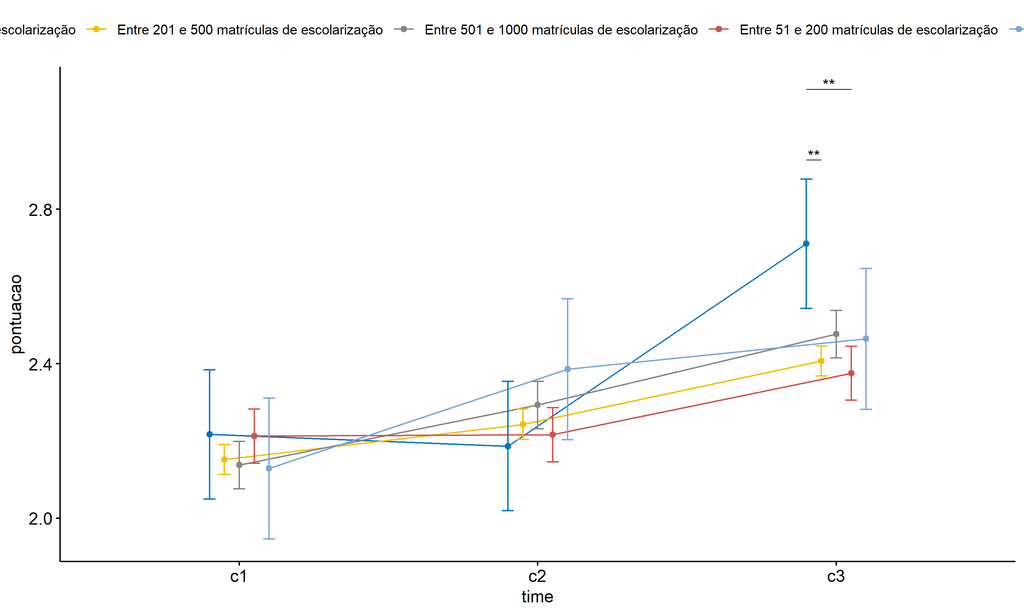

```r
pwc <- add_xy_position(pwc, x = "time", fun = "mean_se", dodge = 0.25)
pd <- position_dodge(width = 0.25)
ggline(emms, x = "time", y = "emmean", color = "porte",
       palette = c("#0073C2FF","#EFC000FF","#868686FF","#CD534CFF","#7AA6DCFF"),
       position = pd, ylab = "pontuacao") +
  geom_errorbar(aes(ymin = conf.low, ymax = conf.high, color = porte),
                position = pd, width = 0.2) +
  stat_pvalue_manual(pwc, hide.ns = T, tip.length = F, linetype = 1)
```

```r
(pwc <- ldat %>% group_by(porte) %>%
    emmeans_test(pontuacao ~ time, detailed = T, p.adjust.method = "bonferroni"))
```

```
## # A tibble: 15 × 15
##    porte  term  .y.   group1 group2 null.value estimate     se    df conf.low conf.high statistic        p    p.adj p.adj.signif
##  * <fct>  <chr> <chr> <chr>  <chr>       <dbl>    <dbl>  <dbl> <dbl>    <dbl>     <dbl>     <dbl>    <dbl>    <dbl> <chr>
##  1 Até 5… time  pont… c1     c2              0  0.0301  0.121   8304   -0.207  0.267       0.249  8.03e- 1 1   e+ 0 ns
##  2 Até 5… time  pont… c1     c3              0 -0.494   0.121   8304   -0.731 -0.257      -4.09   4.38e- 5 1.31e- 4 ***
##  3 Até 5… time  pont… c2     c3              0 -0.524   0.121   8304   -0.761 -0.287      -4.34   1.45e- 5 4.36e- 5 ****
##  4 Entre… time  pont… c1     c2              0 -0.0913  0.0281  8304   -0.146 -0.0361     -3.24   1.19e- 3 3.56e- 3 **
##  5 Entre… time  pont… c1     c3              0 -0.255   0.0281  8304   -0.310 -0.200      -9.07   1.49e-19 4.48e-19 ****
##  6 Entre… time  pont… c2     c3              0 -0.164   0.0281  8304   -0.219 -0.109      -5.82   5.94e- 9 1.78e- 8 ****
##  7 Entre… time  pont… c1     c2              0 -0.155   0.0443  8304   -0.242 -0.0686     -3.51   4.53e- 4 1.36e- 3 **
##  8 Entre… time  pont… c1     c3              0 -0.339   0.0443  8304   -0.426 -0.252      -7.66   2.12e-14 6.36e-14 ****
##  9 Entre… time  pont… c2     c3              0 -0.184   0.0443  8304   -0.270 -0.0969     -4.15   3.38e- 5 1.02e- 4 ***
## 10 Entre… time  pont… c1     c2              0 -0.00370 0.0506  8304   -0.103  0.0955     -0.0731 9.42e- 1 1   e+ 0 ns
## 11 Entre… time  pont… c1     c3              0 -0.163   0.0506  8304   -0.262 -0.0636     -3.22   1.30e- 3 3.90e- 3 **
## 12 Entre… time  pont… c2     c3              0 -0.159   0.0506  8304   -0.258 -0.0599     -3.14   1.67e- 3 5.02e- 3 **
## 13 Mais … time  pont… c1     c2              0 -0.257   0.132   8304   -0.515  0.000728   -1.95   5.06e- 2 1.52e- 1 ns
## 14 Mais … time  pont… c1     c3              0 -0.336   0.132   8304   -0.594 -0.0778     -2.55   1.07e- 2 3.22e- 2 *
## 15 Mais … time  pont… c2     c3              0 -0.0786  0.132   8304   -0.336  0.179      -0.597  5.50e- 1 1   e+ 0 ns
```

| porte | term | .y. | group1 | group2 | null.value | estimate | se | df | conf.low | conf.high | statistic | p | p.adj | p.adj.signif |
| --- | --- | --- | --- | --- | --- | --- | --- | --- | --- | --- | --- | --- | --- | --- |
| Até 50 matrículas de escolarização | time | pontuacao | c1 | c2 | 0 | 0.030 | 0.121 | 8304 | -0.207 | 0.267 | 0.249 | 0.803 | 1.000 | ns |
| Até 50 matrículas de escolarização | time | pontuacao | c1 | c3 | 0 | -0.494 | 0.121 | 8304 | -0.731 | -0.257 | -4.089 | 0.000 | 0.000 | *** |
| Até 50 matrículas de escolarização | time | pontuacao | c2 | c3 | 0 | -0.524 | 0.121 | 8304 | -0.761 | -0.287 | -4.338 | 0.000 | 0.000 | **** |
| Entre 201 e 500 matrículas de escolarização | time | pontuacao | c1 | c2 | 0 | -0.091 | 0.028 | 8304 | -0.146 | -0.036 | -3.243 | 0.001 | 0.004 | ** |
| Entre 201 e 500 matrículas de escolarização | time | pontuacao | c1 | c3 | 0 | -0.255 | 0.028 | 8304 | -0.310 | -0.200 | -9.068 | 0.000 | 0.000 | **** |
| Entre 201 e 500 matrículas de escolarização | time | pontuacao | c2 | c3 | 0 | -0.164 | 0.028 | 8304 | -0.219 | -0.109 | -5.824 | 0.000 | 0.000 | **** |
| Entre 501 e 1000 matrículas de escolarização | time | pontuacao | c1 | c2 | 0 | -0.155 | 0.044 | 8304 | -0.242 | -0.069 | -3.509 | 0.000 | 0.001 | ** |
| Entre 501 e 1000 matrículas de escolarização | time | pontuacao | c1 | c3 | 0 | -0.339 | 0.044 | 8304 | -0.426 | -0.252 | -7.657 | 0.000 | 0.000 | **** |
| Entre 501 e 1000 matrículas de escolarização | time | pontuacao | c2 | c3 | 0 | -0.184 | 0.044 | 8304 | -0.270 | -0.097 | -4.148 | 0.000 | 0.000 | *** |
| Entre 51 e 200 matrículas de escolarização | time | pontuacao | c1 | c2 | 0 | -0.004 | 0.051 | 8304 | -0.103 | 0.096 | -0.073 | 0.942 | 1.000 | ns |
| Entre 51 e 200 matrículas de escolarização | time | pontuacao | c1 | c3 | 0 | -0.163 | 0.051 | 8304 | -0.262 | -0.064 | -3.217 | 0.001 | 0.004 | ** |
| Entre 51 e 200 matrículas de escolarização | time | pontuacao | c2 | c3 | 0 | -0.159 | 0.051 | 8304 | -0.258 | -0.060 | -3.144 | 0.002 | 0.005 | ** |
| Mais de 1000 matrículas de escolarização | time | pontuacao | c1 | c2 | 0 | -0.257 | 0.132 | 8304 | -0.515 | 0.001 | -1.955 | 0.051 | 0.152 | ns |
| Mais de 1000 matrículas de escolarização | time | pontuacao | c1 | c3 | 0 | -0.336 | 0.132 | 8304 | -0.594 | -0.078 | -2.552 | 0.011 | 0.032 | * |
| Mais de 1000 matrículas de escolarização | time | pontuacao | c2 | c3 | 0 | -0.079 | 0.132 | 8304 | -0.336 | 0.179 | -0.597 | 0.550 | 1.000 | ns |

```r
(emms <- get_emmeans(pwc))
```

```
## # A tibble: 15 × 8
##    porte                                        time  emmean     se    df conf.low conf.high method
##    <fct>                                        <fct>  <dbl>  <dbl> <dbl>    <dbl>     <dbl> <chr>
##  1 Até 50 matrículas de escolarização           c1      2.22 0.0854  8304     2.05      2.38 Emmeans test
##  2 Até 50 matrículas de escolarização           c2      2.19 0.0854  8304     2.02      2.35 Emmeans test
##  3 Até 50 matrículas de escolarização           c3      2.71 0.0854  8304     2.54      2.88 Emmeans test
##  4 Entre 201 e 500 matrículas de escolarização  c1      2.15 0.0199  8304     2.11      2.19 Emmeans test
##  5 Entre 201 e 500 matrículas de escolarização  c2      2.24 0.0199  8304     2.20      2.28 Emmeans test
##  6 Entre 201 e 500 matrículas de escolarização  c3      2.41 0.0199  8304     2.37      2.45 Emmeans test
##  7 Entre 501 e 1000 matrículas de escolarização c1      2.14 0.0313  8304     2.08      2.20 Emmeans test
##  8 Entre 501 e 1000 matrículas de escolarização c2      2.29 0.0313  8304     2.23      2.35 Emmeans test
##  9 Entre 501 e 1000 matrículas de escolarização c3      2.48 0.0313  8304     2.42      2.54 Emmeans test
## 10 Entre 51 e 200 matrículas de escolarização   c1      2.21 0.0358  8304     2.14      2.28 Emmeans test
## 11 Entre 51 e 200 matrículas de escolarização   c2      2.22 0.0358  8304     2.15      2.29 Emmeans test
## 12 Entre 51 e 200 matrículas de escolarização   c3      2.38 0.0358  8304     2.31      2.45 Emmeans test
## 13 Mais de 1000 matrículas de escolarização     c1      2.13 0.0930  8304     1.95      2.31 Emmeans test
## 14 Mais de 1000 matrículas de escolarização     c2      2.39 0.0930  8304     2.20      2.57 Emmeans test
## 15 Mais de 1000 matrículas de escolarização     c3      2.46 0.0930  8304     2.28      2.65 Emmeans test
```

| porte | time | emmean | se | df | conf.low | conf.high | method |
| --- | --- | --- | --- | --- | --- | --- | --- |
| Até 50 matrículas de escolarização | c1 | 2.217 | 0.085 | 8304 | 2.049 | 2.384 | Emmeans test |
| Até 50 matrículas de escolarização | c2 | 2.187 | 0.085 | 8304 | 2.019 | 2.354 | Emmeans test |
| Até 50 matrículas de escolarização | c3 | 2.711 | 0.085 | 8304 | 2.543 | 2.878 | Emmeans test |
| Entre 201 e 500 matrículas de escolarização | c1 | 2.152 | 0.020 | 8304 | 2.113 | 2.191 | Emmeans test |
| Entre 201 e 500 matrículas de escolarização | c2 | 2.243 | 0.020 | 8304 | 2.204 | 2.282 | Emmeans test |
| Entre 201 e 500 matrículas de escolarização | c3 | 2.407 | 0.020 | 8304 | 2.368 | 2.446 | Emmeans test |
| Entre 501 e 1000 matrículas de escolarização | c1 | 2.138 | 0.031 | 8304 | 2.076 | 2.199 | Emmeans test |
| Entre 501 e 1000 matrículas de escolarização | c2 | 2.293 | 0.031 | 8304 | 2.232 | 2.354 | Emmeans test |
| Entre 501 e 1000 matrículas de escolarização | c3 | 2.477 | 0.031 | 8304 | 2.415 | 2.538 | Emmeans test |
| Entre 51 e 200 matrículas de escolarização | c1 | 2.212 | 0.036 | 8304 | 2.142 | 2.283 | Emmeans test |
| Entre 51 e 200 matrículas de escolarização | c2 | 2.216 | 0.036 | 8304 | 2.146 | 2.286 | Emmeans test |
| Entre 51 e 200 matrículas de escolarização | c3 | 2.375 | 0.036 | 8304 | 2.305 | 2.445 | Emmeans test |
| Mais de 1000 matrículas de escolarização | c1 | 2.129 | 0.093 | 8304 | 1.946 | 2.311 | Emmeans test |
| Mais de 1000 matrículas de escolarização | c2 | 2.386 | 0.093 | 8304 | 2.203 | 2.568 | Emmeans test |
| Mais de 1000 matrículas de escolarização | c3 | 2.464 | 0.093 | 8304 | 2.282 | 2.647 | Emmeans test |

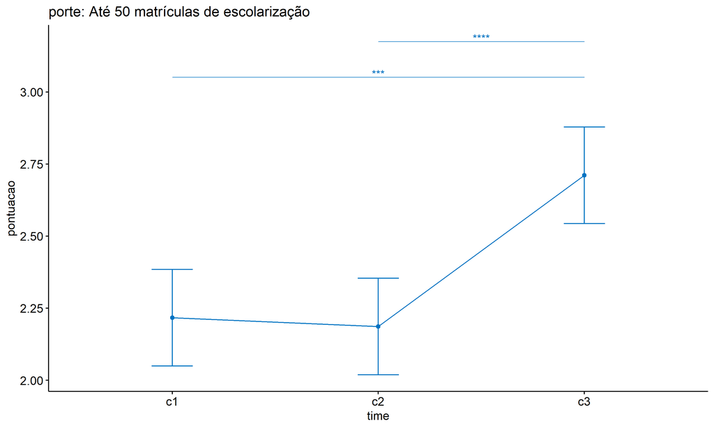

```r
emms.gg <- emms[which(emms$porte == "Até 50 matrículas de escolarização"),]
if (nrow(emms.gg) > 0)
  ggline(emms.gg, x = "time", y = "emmean", color = "#0073C2FF", ylab = "pontuacao") +
    geom_errorbar(aes(ymin = conf.low, ymax = conf.high),
                  width = 0.2, color = "#0073C2FF") +
    stat_pvalue_manual(
      add_xy_position(pwc[which(pwc$porte == "Até 50 matrículas de escolarização"),],
                      x = "time", fun = "mean_se"),
      hide.ns = T, color = "#0073C2FF", tip.length = F) +
    labs(title = "porte: Até 50 matrículas de escolarização")+
    theme(legend.text = element_blank())
```

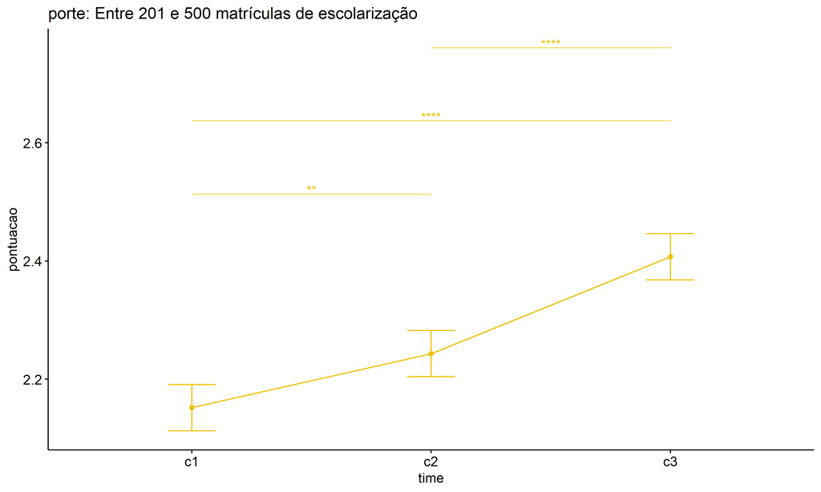

```r
emms.gg <- emms[which(emms$porte == "Entre 201 e 500 matrículas de escolarização"),]
if (nrow(emms.gg) > 0)
  ggline(emms.gg, x = "time", y = "emmean", color = "#EFC000FF", ylab = "pontuacao") +
    geom_errorbar(aes(ymin = conf.low, ymax = conf.high),
                  width = 0.2, color = "#EFC000FF") +
    stat_pvalue_manual(
      add_xy_position(pwc[which(pwc$porte == "Entre 201 e 500 matrículas de escolarização"),],
                      x = "time", fun = "mean_se"),
      hide.ns = T, color = "#EFC000FF", tip.length = F) +
    labs(title = "porte: Entre 201 e 500 matrículas de escolarização")+
    theme(legend.text = element_blank())
```

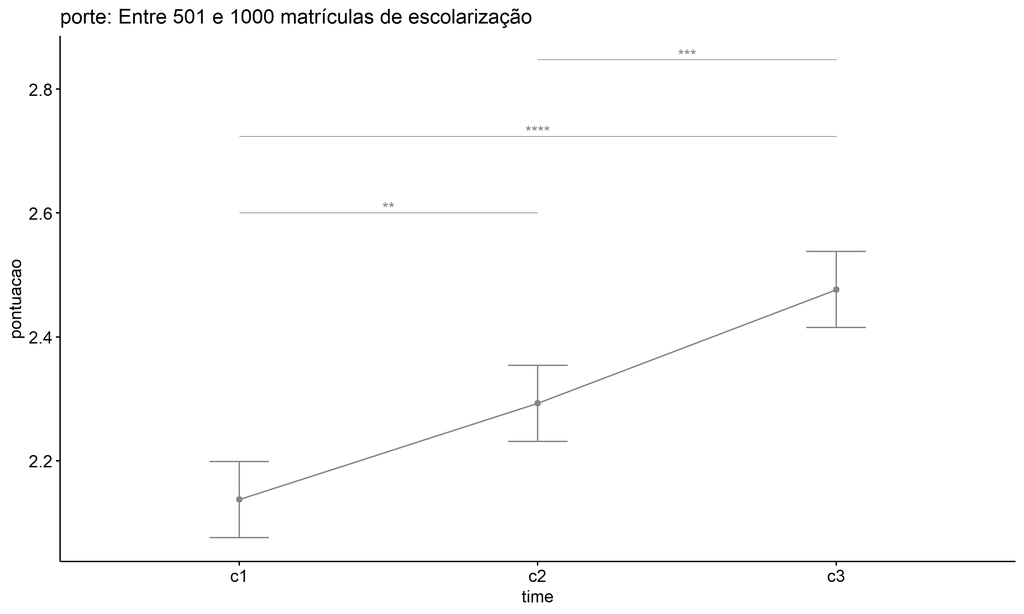

```r
emms.gg <- emms[which(emms$porte == "Entre 501 e 1000 matrículas de escolarização"),]
if (nrow(emms.gg) > 0)
  ggline(emms.gg, x = "time", y = "emmean", color = "#868686FF", ylab = "pontuacao") +
    geom_errorbar(aes(ymin = conf.low, ymax = conf.high),
                  width = 0.2, color = "#868686FF") +
    stat_pvalue_manual(
      add_xy_position(pwc[which(pwc$porte == "Entre 501 e 1000 matrículas de escolarização"),],
                      x = "time", fun = "mean_se"),
      hide.ns = T, color = "#868686FF", tip.length = F) +
    labs(title = "porte: Entre 501 e 1000 matrículas de escolarização")+
    theme(legend.text = element_blank())
```

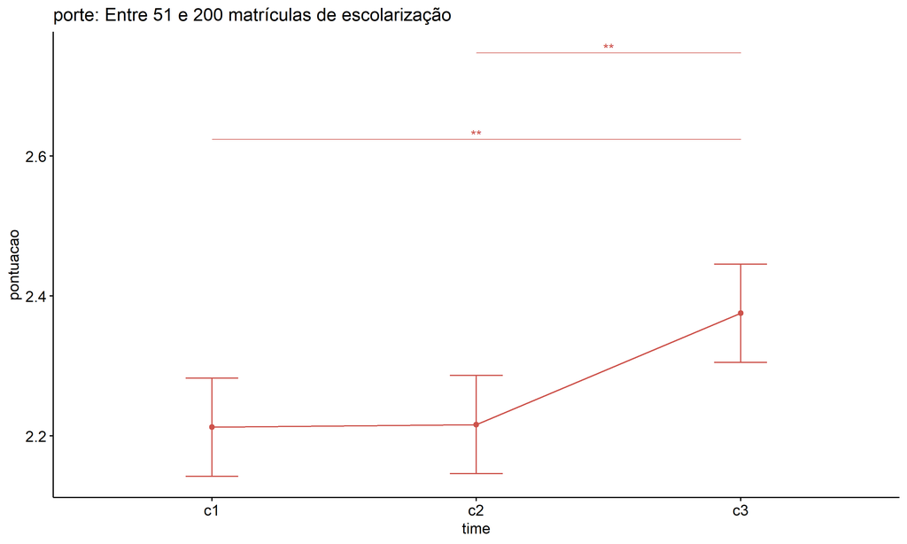

```r
emms.gg <- emms[which(emms$porte == "Entre 51 e 200 matrículas de escolarização"),]
if (nrow(emms.gg) > 0)
  ggline(emms.gg, x = "time", y = "emmean", color = "#CD534CFF", ylab = "pontuacao") +
    geom_errorbar(aes(ymin = conf.low, ymax = conf.high),
                  width = 0.2, color = "#CD534CFF") +
    stat_pvalue_manual(
      add_xy_position(pwc[which(pwc$porte == "Entre 51 e 200 matrículas de escolarização"),],
                      x = "time", fun = "mean_se"),
      hide.ns = T, color = "#CD534CFF", tip.length = F) +
    labs(title = "porte: Entre 51 e 200 matrículas de escolarização")+
    theme(legend.text = element_blank())
```

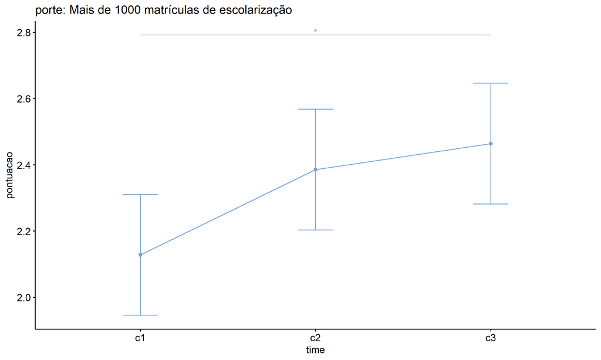

```r
emms.gg <- emms[which(emms$porte == "Mais de 1000 matrículas de escolarização"),]
if (nrow(emms.gg) > 0)
  ggline(emms.gg, x = "time", y = "emmean", color = "#7AA6DCFF", ylab = "pontuacao") +
    geom_errorbar(aes(ymin = conf.low, ymax = conf.high),
                  width = 0.2, color = "#7AA6DCFF") +
    stat_pvalue_manual(
      add_xy_position(pwc[which(pwc$porte == "Mais de 1000 matrículas de escolarização"),],
                      x = "time", fun = "mean_se"),
      hide.ns = T, color = "#7AA6DCFF", tip.length = F) +
    labs(title = "porte: Mais de 1000 matrículas de escolarização")+
    theme(legend.text = element_blank())
```

## PairWise Computation after removing non.normal data

```r
if (length(non.ids) > 0)
  (pwc2 <- ldat2 %>% group_by(time) %>%
     emmeans_test(pontuacao ~ porte, detailed = T, p.adjust.method = "bonferroni"))
```

```
## # A tibble: 30 × 15
##    time  term  .y.       group1    group2 null.value estimate     se    df conf.low conf.high statistic     p p.adj p.adj.signif
##  * <fct> <chr> <chr>     <chr>     <chr>       <dbl>    <dbl>  <dbl> <dbl>    <dbl>     <dbl>     <dbl> <dbl> <dbl> <chr>
##  1 c1    porte pontuacao Até 50 m… Entre…          0   0.181  0.257   8049  -0.322     0.685     0.706  0.480     1 ns
##  2 c1    porte pontuacao Até 50 m… Entre…          0   0.196  0.258   8049  -0.310     0.702     0.758  0.448     1 ns
##  3 c1    porte pontuacao Até 50 m… Entre…          0   0.121  0.259   8049  -0.386     0.628     0.467  0.640     1 ns
##  4 c1    porte pontuacao Até 50 m… Mais …          0   0.206  0.275   8049  -0.333     0.746     0.749  0.454     1 ns
##  5 c1    porte pontuacao Entre 20… Entre…          0   0.0144 0.0366  8049  -0.0575    0.0862    0.392  0.695     1 ns
##  6 c1    porte pontuacao Entre 20… Entre…          0  -0.0606 0.0405  8049  -0.140     0.0187   -1.50   0.134     1 ns
##  7 c1    porte pontuacao Entre 20… Mais …          0   0.0248 0.102   8049  -0.175     0.225     0.243  0.808     1 ns
##  8 c1    porte pontuacao Entre 50… Entre…          0  -0.0749 0.0470  8049  -0.167     0.0171   -1.60   0.111     1 ns
##  9 c1    porte pontuacao Entre 50… Mais …          0   0.0104 0.105   8049  -0.195     0.216     0.0995 0.921     1 ns
## 10 c1    porte pontuacao Entre 51… Mais …          0   0.0854 0.106   8049  -0.123     0.293     0.804  0.421     1 ns
## # ℹ 20 more rows
```

| time | term | .y. | group1 | group2 | null.value | estimate | se | df | conf.low | conf.high | statistic | p | p.adj | p.adj.signif |
| --- | --- | --- | --- | --- | --- | --- | --- | --- | --- | --- | --- | --- | --- | --- |
| c1 | porte | pontuacao | Até 50 matrículas de escolarização | Entre 201 e 500 matrículas de escolarização | 0 | 0.181 | 0.257 | 8049 | -0.322 | 0.685 | 0.706 | 0.480 | 1.000 | ns |
| c1 | porte | pontuacao | Até 50 matrículas de escolarização | Entre 501 e 1000 matrículas de escolarização | 0 | 0.196 | 0.258 | 8049 | -0.310 | 0.702 | 0.758 | 0.448 | 1.000 | ns |
| c1 | porte | pontuacao | Até 50 matrículas de escolarização | Entre 51 e 200 matrículas de escolarização | 0 | 0.121 | 0.259 | 8049 | -0.386 | 0.628 | 0.467 | 0.640 | 1.000 | ns |
| c1 | porte | pontuacao | Até 50 matrículas de escolarização | Mais de 1000 matrículas de escolarização | 0 | 0.206 | 0.275 | 8049 | -0.333 | 0.746 | 0.749 | 0.454 | 1.000 | ns |
| c1 | porte | pontuacao | Entre 201 e 500 matrículas de escolarização | Entre 501 e 1000 matrículas de escolarização | 0 | 0.014 | 0.037 | 8049 | -0.057 | 0.086 | 0.392 | 0.695 | 1.000 | ns |
| c1 | porte | pontuacao | Entre 201 e 500 matrículas de escolarização | Entre 51 e 200 matrículas de escolarização | 0 | -0.061 | 0.040 | 8049 | -0.140 | 0.019 | -1.498 | 0.134 | 1.000 | ns |
| c1 | porte | pontuacao | Entre 201 e 500 matrículas de escolarização | Mais de 1000 matrículas de escolarização | 0 | 0.025 | 0.102 | 8049 | -0.175 | 0.225 | 0.243 | 0.808 | 1.000 | ns |
| c1 | porte | pontuacao | Entre 501 e 1000 matrículas de escolarização | Entre 51 e 200 matrículas de escolarização | 0 | -0.075 | 0.047 | 8049 | -0.167 | 0.017 | -1.595 | 0.111 | 1.000 | ns |
| c1 | porte | pontuacao | Entre 501 e 1000 matrículas de escolarização | Mais de 1000 matrículas de escolarização | 0 | 0.010 | 0.105 | 8049 | -0.195 | 0.216 | 0.099 | 0.921 | 1.000 | ns |
| c1 | porte | pontuacao | Entre 51 e 200 matrículas de escolarização | Mais de 1000 matrículas de escolarização | 0 | 0.085 | 0.106 | 8049 | -0.123 | 0.293 | 0.804 | 0.421 | 1.000 | ns |
| c2 | porte | pontuacao | Até 50 matrículas de escolarização | Entre 201 e 500 matrículas de escolarização | 0 | -0.243 | 0.257 | 8049 | -0.747 | 0.261 | -0.946 | 0.344 | 1.000 | ns |
| c2 | porte | pontuacao | Até 50 matrículas de escolarização | Entre 501 e 1000 matrículas de escolarização | 0 | -0.293 | 0.258 | 8049 | -0.799 | 0.213 | -1.135 | 0.257 | 1.000 | ns |
| c2 | porte | pontuacao | Até 50 matrículas de escolarização | Entre 51 e 200 matrículas de escolarização | 0 | -0.216 | 0.259 | 8049 | -0.723 | 0.291 | -0.836 | 0.403 | 1.000 | ns |
| c2 | porte | pontuacao | Até 50 matrículas de escolarização | Mais de 1000 matrículas de escolarização | 0 | -0.271 | 0.275 | 8049 | -0.811 | 0.268 | -0.986 | 0.324 | 1.000 | ns |
| c2 | porte | pontuacao | Entre 201 e 500 matrículas de escolarização | Entre 501 e 1000 matrículas de escolarização | 0 | -0.050 | 0.037 | 8049 | -0.122 | 0.022 | -1.356 | 0.175 | 1.000 | ns |
| c2 | porte | pontuacao | Entre 201 e 500 matrículas de escolarização | Entre 51 e 200 matrículas de escolarização | 0 | 0.027 | 0.040 | 8049 | -0.052 | 0.106 | 0.668 | 0.504 | 1.000 | ns |
| c2 | porte | pontuacao | Entre 201 e 500 matrículas de escolarização | Mais de 1000 matrículas de escolarização | 0 | -0.028 | 0.102 | 8049 | -0.228 | 0.172 | -0.274 | 0.784 | 1.000 | ns |
| c2 | porte | pontuacao | Entre 501 e 1000 matrículas de escolarização | Entre 51 e 200 matrículas de escolarização | 0 | 0.077 | 0.047 | 8049 | -0.015 | 0.169 | 1.633 | 0.102 | 1.000 | ns |
| c2 | porte | pontuacao | Entre 501 e 1000 matrículas de escolarização | Mais de 1000 matrículas de escolarização | 0 | 0.022 | 0.105 | 8049 | -0.184 | 0.227 | 0.207 | 0.836 | 1.000 | ns |
| c2 | porte | pontuacao | Entre 51 e 200 matrículas de escolarização | Mais de 1000 matrículas de escolarização | 0 | -0.055 | 0.106 | 8049 | -0.263 | 0.153 | -0.518 | 0.604 | 1.000 | ns |
| c3 | porte | pontuacao | Até 50 matrículas de escolarização | Entre 201 e 500 matrículas de escolarização | 0 | 1.482 | 0.257 | 8049 | 0.978 | 1.986 | 5.765 | 0.000 | 0.000 | **** |
| c3 | porte | pontuacao | Até 50 matrículas de escolarização | Entre 501 e 1000 matrículas de escolarização | 0 | 1.412 | 0.258 | 8049 | 0.906 | 1.918 | 5.471 | 0.000 | 0.000 | **** |
| c3 | porte | pontuacao | Até 50 matrículas de escolarização | Entre 51 e 200 matrículas de escolarização | 0 | 1.514 | 0.259 | 8049 | 1.006 | 2.021 | 5.851 | 0.000 | 0.000 | **** |
| c3 | porte | pontuacao | Até 50 matrículas de escolarização | Mais de 1000 matrículas de escolarização | 0 | 1.847 | 0.275 | 8049 | 1.307 | 2.386 | 6.711 | 0.000 | 0.000 | **** |
| c3 | porte | pontuacao | Entre 201 e 500 matrículas de escolarização | Entre 501 e 1000 matrículas de escolarização | 0 | -0.069 | 0.037 | 8049 | -0.141 | 0.002 | -1.894 | 0.058 | 0.583 | ns |
| c3 | porte | pontuacao | Entre 201 e 500 matrículas de escolarização | Entre 51 e 200 matrículas de escolarização | 0 | 0.032 | 0.040 | 8049 | -0.047 | 0.111 | 0.788 | 0.431 | 1.000 | ns |
| c3 | porte | pontuacao | Entre 201 e 500 matrículas de escolarização | Mais de 1000 matrículas de escolarização | 0 | 0.365 | 0.102 | 8049 | 0.165 | 0.565 | 3.576 | 0.000 | 0.004 | ** |
| c3 | porte | pontuacao | Entre 501 e 1000 matrículas de escolarização | Entre 51 e 200 matrículas de escolarização | 0 | 0.101 | 0.047 | 8049 | 0.009 | 0.193 | 2.156 | 0.031 | 0.311 | ns |
| c3 | porte | pontuacao | Entre 501 e 1000 matrículas de escolarização | Mais de 1000 matrículas de escolarização | 0 | 0.434 | 0.105 | 8049 | 0.229 | 0.640 | 4.144 | 0.000 | 0.000 | *** |
| c3 | porte | pontuacao | Entre 51 e 200 matrículas de escolarização | Mais de 1000 matrículas de escolarização | 0 | 0.333 | 0.106 | 8049 | 0.125 | 0.541 | 3.136 | 0.002 | 0.017 | * |

```r
if (length(non.ids) > 0)
  (emms2 <- get_emmeans(pwc2))
```

```
## # A tibble: 15 × 8
##    time  porte                                        emmean     se    df conf.low conf.high method
##    <fct> <fct>                                         <dbl>  <dbl> <dbl>    <dbl>     <dbl> <chr>
##  1 c1    Até 50 matrículas de escolarização             2.33 0.256   8049     1.83      2.84 Emmeans test
##  2 c1    Entre 201 e 500 matrículas de escolarização    2.15 0.0197  8049     2.11      2.19 Emmeans test
##  3 c1    Entre 501 e 1000 matrículas de escolarização   2.14 0.0309  8049     2.08      2.20 Emmeans test
##  4 c1    Entre 51 e 200 matrículas de escolarização     2.21 0.0354  8049     2.14      2.28 Emmeans test
##  5 c1    Mais de 1000 matrículas de escolarização       2.13 0.100   8049     1.93      2.32 Emmeans test
##  6 c2    Até 50 matrículas de escolarização             2.00 0.256   8049     1.50      2.50 Emmeans test
##  7 c2    Entre 201 e 500 matrículas de escolarização    2.24 0.0197  8049     2.20      2.28 Emmeans test
##  8 c2    Entre 501 e 1000 matrículas de escolarização   2.29 0.0309  8049     2.23      2.35 Emmeans test
##  9 c2    Entre 51 e 200 matrículas de escolarização     2.22 0.0354  8049     2.15      2.29 Emmeans test
## 10 c2    Mais de 1000 matrículas de escolarização       2.27 0.100   8049     2.07      2.47 Emmeans test
## 11 c3    Até 50 matrículas de escolarização             3.89 0.256   8049     3.39      4.39 Emmeans test
## 12 c3    Entre 201 e 500 matrículas de escolarização    2.41 0.0197  8049     2.37      2.45 Emmeans test
## 13 c3    Entre 501 e 1000 matrículas de escolarização   2.48 0.0309  8049     2.42      2.54 Emmeans test
## 14 c3    Entre 51 e 200 matrículas de escolarização     2.38 0.0354  8049     2.31      2.44 Emmeans test
## 15 c3    Mais de 1000 matrículas de escolarização       2.04 0.100   8049     1.85      2.24 Emmeans test
```

| time | porte | emmean | se | df | conf.low | conf.high | method |
| --- | --- | --- | --- | --- | --- | --- | --- |
| c1 | Até 50 matrículas de escolarização | 2.333 | 0.256 | 8049 | 1.831 | 2.836 | Emmeans test |
| c1 | Entre 201 e 500 matrículas de escolarização | 2.152 | 0.020 | 8049 | 2.113 | 2.190 | Emmeans test |
| c1 | Entre 501 e 1000 matrículas de escolarização | 2.138 | 0.031 | 8049 | 2.077 | 2.198 | Emmeans test |
| c1 | Entre 51 e 200 matrículas de escolarização | 2.212 | 0.035 | 8049 | 2.143 | 2.282 | Emmeans test |
| c1 | Mais de 1000 matrículas de escolarização | 2.127 | 0.100 | 8049 | 1.931 | 2.323 | Emmeans test |
| c2 | Até 50 matrículas de escolarização | 2.000 | 0.256 | 8049 | 1.498 | 2.502 | Emmeans test |
| c2 | Entre 201 e 500 matrículas de escolarização | 2.243 | 0.020 | 8049 | 2.205 | 2.282 | Emmeans test |
| c2 | Entre 501 e 1000 matrículas de escolarização | 2.293 | 0.031 | 8049 | 2.232 | 2.354 | Emmeans test |
| c2 | Entre 51 e 200 matrículas de escolarização | 2.216 | 0.035 | 8049 | 2.147 | 2.285 | Emmeans test |
| c2 | Mais de 1000 matrículas de escolarização | 2.271 | 0.100 | 8049 | 2.075 | 2.467 | Emmeans test |
| c3 | Até 50 matrículas de escolarização | 3.889 | 0.256 | 8049 | 3.387 | 4.391 | Emmeans test |
| c3 | Entre 201 e 500 matrículas de escolarização | 2.407 | 0.020 | 8049 | 2.369 | 2.446 | Emmeans test |
| c3 | Entre 501 e 1000 matrículas de escolarização | 2.477 | 0.031 | 8049 | 2.416 | 2.537 | Emmeans test |
| c3 | Entre 51 e 200 matrículas de escolarização | 2.375 | 0.035 | 8049 | 2.306 | 2.445 | Emmeans test |
| c3 | Mais de 1000 matrículas de escolarização | 2.042 | 0.100 | 8049 | 1.846 | 2.239 | Emmeans test |

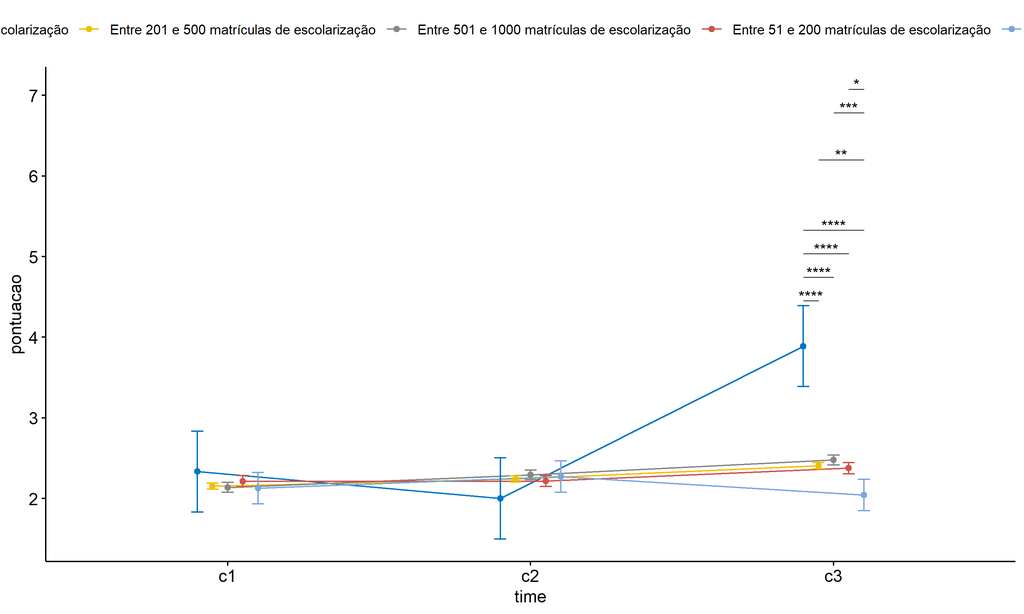

```r
if (length(non.ids) > 0) {
  pwc2 <- add_xy_position(pwc2, x = "time", fun = "mean_se", dodge = 0.25)
  pd2 <- position_dodge(width = 0.25)

  ggline(emms2, x = "time", y = "emmean", color = "porte",
         palette = c("#0073C2FF","#EFC000FF","#868686FF","#CD534CFF","#7AA6DCFF"),
         position = pd, ylab = "pontuacao") +
    geom_errorbar(aes(ymin = conf.low, ymax = conf.high, color = porte),
                position = pd, width = 0.2) +
    stat_pvalue_manual(pwc2, hide.ns = T, tip.length = F, linetype = 1)
}
```

```r
if (length(non.ids) > 0)
  (pwc2 <- ldat2 %>% group_by(porte) %>%
     emmeans_test(pontuacao ~ time, detailed = T, p.adjust.method = "bonferroni"))
```

```
## # A tibble: 15 × 15
##    porte  term  .y.   group1 group2 null.value estimate     se    df conf.low conf.high statistic        p    p.adj p.adj.signif
##  * <fct>  <chr> <chr> <chr>  <chr>       <dbl>    <dbl>  <dbl> <dbl>    <dbl>     <dbl>     <dbl>    <dbl>    <dbl> <chr>
##  1 Até 5… time  pont… c1     c2              0  0.333   0.362   8049  -0.377     1.04      0.920  3.58e- 1 1   e+ 0 ns
##  2 Até 5… time  pont… c1     c3              0 -1.56    0.362   8049  -2.27     -0.845    -4.29   1.79e- 5 5.38e- 5 ****
##  3 Até 5… time  pont… c2     c3              0 -1.89    0.362   8049  -2.60     -1.18     -5.21   1.92e- 7 5.76e- 7 ****
##  4 Entre… time  pont… c1     c2              0 -0.0913  0.0278  8049  -0.146    -0.0368   -3.28   1.03e- 3 3.09e- 3 **
##  5 Entre… time  pont… c1     c3              0 -0.255   0.0278  8049  -0.310    -0.201    -9.18   5.46e-20 1.64e-19 ****
##  6 Entre… time  pont… c2     c3              0 -0.164   0.0278  8049  -0.218    -0.109    -5.90   3.88e- 9 1.16e- 8 ****
##  7 Entre… time  pont… c1     c2              0 -0.155   0.0437  8049  -0.241    -0.0696   -3.55   3.85e- 4 1.16e- 3 **
##  8 Entre… time  pont… c1     c3              0 -0.339   0.0437  8049  -0.425    -0.253    -7.75   1.03e-14 3.08e-14 ****
##  9 Entre… time  pont… c2     c3              0 -0.184   0.0437  8049  -0.269    -0.0979   -4.20   2.71e- 5 8.13e- 5 ****
## 10 Entre… time  pont… c1     c2              0 -0.00370 0.0500  8049  -0.102     0.0943   -0.0740 9.41e- 1 1   e+ 0 ns
## 11 Entre… time  pont… c1     c3              0 -0.163   0.0500  8049  -0.261    -0.0648   -3.26   1.13e- 3 3.40e- 3 **
## 12 Entre… time  pont… c2     c3              0 -0.159   0.0500  8049  -0.257    -0.0611   -3.18   1.47e- 3 4.40e- 3 **
## 13 Mais … time  pont… c1     c2              0 -0.144   0.142   8049  -0.422     0.133    -1.02   3.09e- 1 9.26e- 1 ns
## 14 Mais … time  pont… c1     c3              0  0.0847  0.142   8049  -0.193     0.362     0.599  5.49e- 1 1   e+ 0 ns
## 15 Mais … time  pont… c2     c3              0  0.229   0.142   8049  -0.0487    0.506     1.62   1.06e- 1 3.18e- 1 ns
```

| porte | term | .y. | group1 | group2 | null.value | estimate | se | df | conf.low | conf.high | statistic | p | p.adj | p.adj.signif |
| --- | --- | --- | --- | --- | --- | --- | --- | --- | --- | --- | --- | --- | --- | --- |
| Até 50 matrículas de escolarização | time | pontuacao | c1 | c2 | 0 | 0.333 | 0.362 | 8049 | -0.377 | 1.044 | 0.920 | 0.358 | 1.000 | ns |
| Até 50 matrículas de escolarização | time | pontuacao | c1 | c3 | 0 | -1.556 | 0.362 | 8049 | -2.266 | -0.845 | -4.292 | 0.000 | 0.000 | **** |
| Até 50 matrículas de escolarização | time | pontuacao | c2 | c3 | 0 | -1.889 | 0.362 | 8049 | -2.599 | -1.178 | -5.212 | 0.000 | 0.000 | **** |
| Entre 201 e 500 matrículas de escolarização | time | pontuacao | c1 | c2 | 0 | -0.091 | 0.028 | 8049 | -0.146 | -0.037 | -3.283 | 0.001 | 0.003 | ** |
| Entre 201 e 500 matrículas de escolarização | time | pontuacao | c1 | c3 | 0 | -0.255 | 0.028 | 8049 | -0.310 | -0.201 | -9.179 | 0.000 | 0.000 | **** |
| Entre 201 e 500 matrículas de escolarização | time | pontuacao | c2 | c3 | 0 | -0.164 | 0.028 | 8049 | -0.218 | -0.109 | -5.896 | 0.000 | 0.000 | **** |
| Entre 501 e 1000 matrículas de escolarização | time | pontuacao | c1 | c2 | 0 | -0.155 | 0.044 | 8049 | -0.241 | -0.070 | -3.552 | 0.000 | 0.001 | ** |
| Entre 501 e 1000 matrículas de escolarização | time | pontuacao | c1 | c3 | 0 | -0.339 | 0.044 | 8049 | -0.425 | -0.253 | -7.751 | 0.000 | 0.000 | **** |
| Entre 501 e 1000 matrículas de escolarização | time | pontuacao | c2 | c3 | 0 | -0.184 | 0.044 | 8049 | -0.269 | -0.098 | -4.199 | 0.000 | 0.000 | **** |
| Entre 51 e 200 matrículas de escolarização | time | pontuacao | c1 | c2 | 0 | -0.004 | 0.050 | 8049 | -0.102 | 0.094 | -0.074 | 0.941 | 1.000 | ns |
| Entre 51 e 200 matrículas de escolarização | time | pontuacao | c1 | c3 | 0 | -0.163 | 0.050 | 8049 | -0.261 | -0.065 | -3.256 | 0.001 | 0.003 | ** |
| Entre 51 e 200 matrículas de escolarização | time | pontuacao | c2 | c3 | 0 | -0.159 | 0.050 | 8049 | -0.257 | -0.061 | -3.182 | 0.001 | 0.004 | ** |
| Mais de 1000 matrículas de escolarização | time | pontuacao | c1 | c2 | 0 | -0.144 | 0.142 | 8049 | -0.422 | 0.133 | -1.018 | 0.309 | 0.926 | ns |
| Mais de 1000 matrículas de escolarização | time | pontuacao | c1 | c3 | 0 | 0.085 | 0.142 | 8049 | -0.193 | 0.362 | 0.599 | 0.549 | 1.000 | ns |
| Mais de 1000 matrículas de escolarização | time | pontuacao | c2 | c3 | 0 | 0.229 | 0.142 | 8049 | -0.049 | 0.506 | 1.616 | 0.106 | 0.318 | ns |

```r
if (length(non.ids) > 0)
  (emms2 <- get_emmeans(pwc2))
```

```
## # A tibble: 15 × 8
##    porte                                        time  emmean     se    df conf.low conf.high method
##    <fct>                                        <fct>  <dbl>  <dbl> <dbl>    <dbl>     <dbl> <chr>
##  1 Até 50 matrículas de escolarização           c1      2.33 0.256   8049     1.83      2.84 Emmeans test
##  2 Até 50 matrículas de escolarização           c2      2.00 0.256   8049     1.50      2.50 Emmeans test
##  3 Até 50 matrículas de escolarização           c3      3.89 0.256   8049     3.39      4.39 Emmeans test
##  4 Entre 201 e 500 matrículas de escolarização  c1      2.15 0.0197  8049     2.11      2.19 Emmeans test
##  5 Entre 201 e 500 matrículas de escolarização  c2      2.24 0.0197  8049     2.20      2.28 Emmeans test
##  6 Entre 201 e 500 matrículas de escolarização  c3      2.41 0.0197  8049     2.37      2.45 Emmeans test
##  7 Entre 501 e 1000 matrículas de escolarização c1      2.14 0.0309  8049     2.08      2.20 Emmeans test
##  8 Entre 501 e 1000 matrículas de escolarização c2      2.29 0.0309  8049     2.23      2.35 Emmeans test
##  9 Entre 501 e 1000 matrículas de escolarização c3      2.48 0.0309  8049     2.42      2.54 Emmeans test
## 10 Entre 51 e 200 matrículas de escolarização   c1      2.21 0.0354  8049     2.14      2.28 Emmeans test
## 11 Entre 51 e 200 matrículas de escolarização   c2      2.22 0.0354  8049     2.15      2.29 Emmeans test
## 12 Entre 51 e 200 matrículas de escolarização   c3      2.38 0.0354  8049     2.31      2.44 Emmeans test
## 13 Mais de 1000 matrículas de escolarização     c1      2.13 0.100   8049     1.93      2.32 Emmeans test
## 14 Mais de 1000 matrículas de escolarização     c2      2.27 0.100   8049     2.07      2.47 Emmeans test
## 15 Mais de 1000 matrículas de escolarização     c3      2.04 0.100   8049     1.85      2.24 Emmeans test
```

| porte | time | emmean | se | df | conf.low | conf.high | method |
| --- | --- | --- | --- | --- | --- | --- | --- |
| Até 50 matrículas de escolarização | c1 | 2.333 | 0.256 | 8049 | 1.831 | 2.836 | Emmeans test |
| Até 50 matrículas de escolarização | c2 | 2.000 | 0.256 | 8049 | 1.498 | 2.502 | Emmeans test |
| Até 50 matrículas de escolarização | c3 | 3.889 | 0.256 | 8049 | 3.387 | 4.391 | Emmeans test |
| Entre 201 e 500 matrículas de escolarização | c1 | 2.152 | 0.020 | 8049 | 2.113 | 2.190 | Emmeans test |
| Entre 201 e 500 matrículas de escolarização | c2 | 2.243 | 0.020 | 8049 | 2.205 | 2.282 | Emmeans test |
| Entre 201 e 500 matrículas de escolarização | c3 | 2.407 | 0.020 | 8049 | 2.369 | 2.446 | Emmeans test |
| Entre 501 e 1000 matrículas de escolarização | c1 | 2.138 | 0.031 | 8049 | 2.077 | 2.198 | Emmeans test |
| Entre 501 e 1000 matrículas de escolarização | c2 | 2.293 | 0.031 | 8049 | 2.232 | 2.354 | Emmeans test |
| Entre 501 e 1000 matrículas de escolarização | c3 | 2.477 | 0.031 | 8049 | 2.416 | 2.537 | Emmeans test |
| Entre 51 e 200 matrículas de escolarização | c1 | 2.212 | 0.035 | 8049 | 2.143 | 2.282 | Emmeans test |
| Entre 51 e 200 matrículas de escolarização | c2 | 2.216 | 0.035 | 8049 | 2.147 | 2.285 | Emmeans test |
| Entre 51 e 200 matrículas de escolarização | c3 | 2.375 | 0.035 | 8049 | 2.306 | 2.445 | Emmeans test |
| Mais de 1000 matrículas de escolarização | c1 | 2.127 | 0.100 | 8049 | 1.931 | 2.323 | Emmeans test |
| Mais de 1000 matrículas de escolarização | c2 | 2.271 | 0.100 | 8049 | 2.075 | 2.467 | Emmeans test |
| Mais de 1000 matrículas de escolarização | c3 | 2.042 | 0.100 | 8049 | 1.846 | 2.239 | Emmeans test |

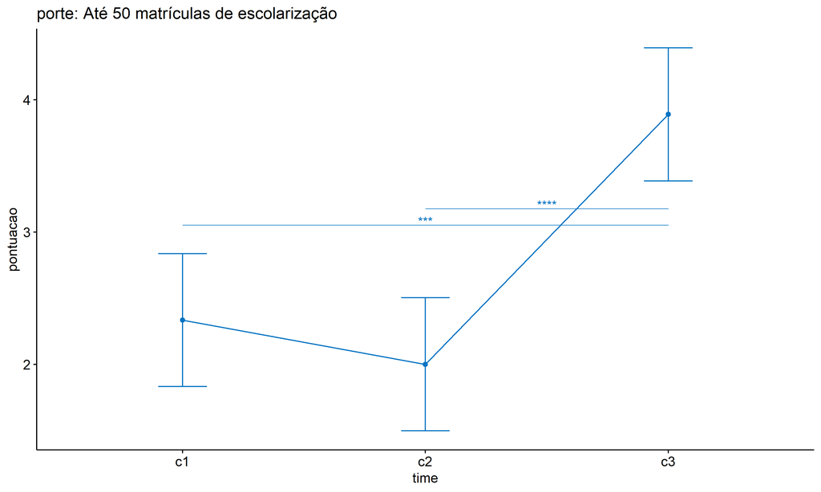

```r
if (length(non.ids) > 0) {
  emms.gg <- emms2[which(emms2$porte == "Até 50 matrículas de escolarização"),]
  if (nrow(emms.gg) > 0)
    ggline(emms.gg, x = "time", y = "emmean", color = "#0073C2FF", ylab = "pontuacao") +
    geom_errorbar(aes(ymin = conf.low, ymax = conf.high),
                  width = 0.2, color = "#0073C2FF") +
    stat_pvalue_manual(
      add_xy_position(pwc[which(pwc$porte == "Até 50 matrículas de escolarização"),],
                      x = "time", fun = "mean_se"),
      hide.ns = T, color = "#0073C2FF", tip.length = F) +
    labs(title = "porte: Até 50 matrículas de escolarização") +
    theme(legend.text = element_blank())
}
```

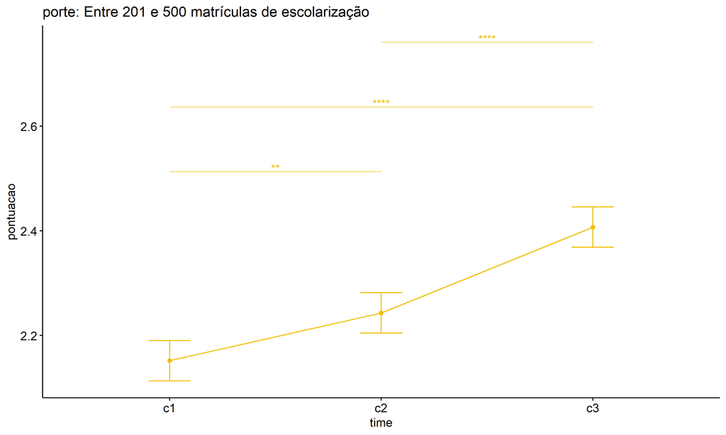

```r
if (length(non.ids) > 0) {
  emms.gg <- emms2[which(emms2$porte == "Entre 201 e 500 matrículas de escolarização"),]
  if (nrow(emms.gg) > 0)
    ggline(emms.gg, x = "time", y = "emmean", color = "#EFC000FF", ylab = "pontuacao") +
    geom_errorbar(aes(ymin = conf.low, ymax = conf.high),
                  width = 0.2, color = "#EFC000FF") +
    stat_pvalue_manual(
      add_xy_position(pwc[which(pwc$porte == "Entre 201 e 500 matrículas de escolarização"),],
                      x = "time", fun = "mean_se"),
      hide.ns = T, color = "#EFC000FF", tip.length = F) +
    labs(title = "porte: Entre 201 e 500 matrículas de escolarização") +
    theme(legend.text = element_blank())
}
```

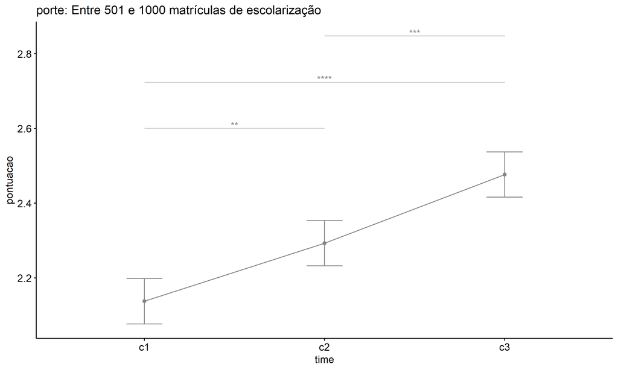

```r
if (length(non.ids) > 0) {
  emms.gg <- emms2[which(emms2$porte == "Entre 501 e 1000 matrículas de escolarização"),]
  if (nrow(emms.gg) > 0)
    ggline(emms.gg, x = "time", y = "emmean", color = "#868686FF", ylab = "pontuacao") +
    geom_errorbar(aes(ymin = conf.low, ymax = conf.high),
                  width = 0.2, color = "#868686FF") +
    stat_pvalue_manual(
      add_xy_position(pwc[which(pwc$porte == "Entre 501 e 1000 matrículas de escolarização"),],
                      x = "time", fun = "mean_se"),
      hide.ns = T, color = "#868686FF", tip.length = F) +
    labs(title = "porte: Entre 501 e 1000 matrículas de escolarização") +
    theme(legend.text = element_blank())
}
```

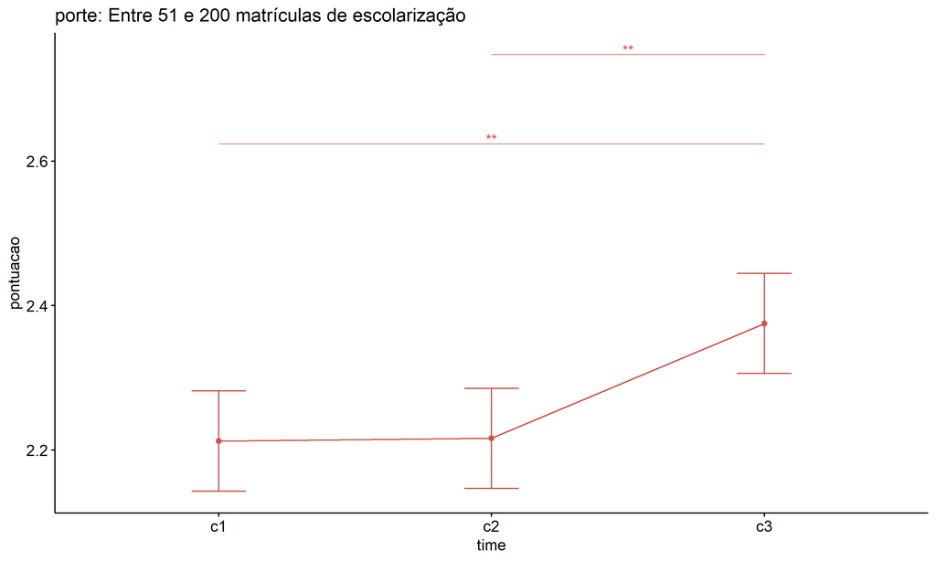

```r
if (length(non.ids) > 0) {
  emms.gg <- emms2[which(emms2$porte == "Entre 51 e 200 matrículas de escolarização"),]
  if (nrow(emms.gg) > 0)
    ggline(emms.gg, x = "time", y = "emmean", color = "#CD534CFF", ylab = "pontuacao") +
    geom_errorbar(aes(ymin = conf.low, ymax = conf.high),
                  width = 0.2, color = "#CD534CFF") +
    stat_pvalue_manual(
      add_xy_position(pwc[which(pwc$porte == "Entre 51 e 200 matrículas de escolarização"),],
                      x = "time", fun = "mean_se"),
      hide.ns = T, color = "#CD534CFF", tip.length = F) +
    labs(title = "porte: Entre 51 e 200 matrículas de escolarização") +
    theme(legend.text = element_blank())
}
```

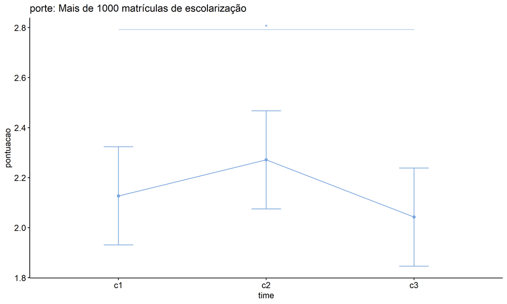

```r
if (length(non.ids) > 0) {
  emms.gg <- emms2[which(emms2$porte == "Mais de 1000 matrículas de escolarização"),]
  if (nrow(emms.gg) > 0)
    ggline(emms.gg, x = "time", y = "emmean", color = "#7AA6DCFF", ylab = "pontuacao") +
    geom_errorbar(aes(ymin = conf.low, ymax = conf.high),
                  width = 0.2, color = "#7AA6DCFF") +
    stat_pvalue_manual(
      add_xy_position(pwc[which(pwc$porte == "Mais de 1000 matrículas de escolarização"),],
                      x = "time", fun = "mean_se"),
      hide.ns = T, color = "#7AA6DCFF", tip.length = F) +
    labs(title = "porte: Mais de 1000 matrículas de escolarização") +
    theme(legend.text = element_blank())
}
```